# PYTHON - TUTORIEL

*Par Bertrand Delorme, Data Analyst*

VARIABLES & AFFICHAGES

**A. Définitions & Standard**

A.1. Définition d'une variable

A.2. Les types de variables

A.3. Nommage

**B. Opérations sur les variables**

B.1. Opérations sur les nombres

B.2. Opérations sur les chaînes de caractères

B.3. La fonction type()

B.4. Conversion de types et syntaxe

B.5. Fonctions mathématiques

**C. Affichages & Retours**

C.1. La fonction print()

C.2. Écriture formatée

C.3. Formatage des chaînes de caractères

**D. Manipulez les chaînes de caractères**

D.1. Chaînes de caractères et listes

D.2. Caractères spéciaux

D.3. Extraction de valeurs numériques

D.4. Méthodes associées

LES LISTES

**A. Définitions & Indiçages**

A.1. Définition d'une liste

A.2. Index d'une liste

A.3. Listes & Opérateurs

A.4. Indiçages positifs et négatifs

A.5. Tranches

**B. Fonctions usuelles sur les listes**

B.1. Fonction len()

B.2. Les fonctions range() et list()

B.3. Les fonctions arange() et linespace()

B.4. Des listes de listes

**C. Listes & itérations**

C.1. Méthodes associées aux listes

C.2. Construction d’une liste par itération

C.3. Test d’appartenance

C.4. Copie de listes

C.5. Listes de compréhension

BOUCLES & INSTRUCTIONS

**A. Boucle for**

A.1. Principe

A.2. La fonction range()

A.3. Nommage de la variable d’itération

A.4. Itérations sur les indices

A.5. Comparaisons

**B. Boucle while**

B.1. Principe

B.2. Input & While

B.3. L'instruction continue

**C. Tests**

C.1. Définition

C.2. Tests à plusieurs cas

C.3. Tests multiples

C.4. Les instructions break, continue et pass

C.5. Tests de valeur sur des floats

**D. Gérez les exceptions**

D.1. Attrapez les erreurs avec try et except

D.2. Instructions raise et help

D.3. Les instructions try et except imbriquées

D.4. Définir ses propres exceptions

D.5. Exemples d'utilisaton des exceptions

LES FONCTIONS

**A. Principe et généralités**

A.1. Définition

A.2. Passage d'arguments

A.3. Renvoi de résultats

A.4. Arguments positionnels et par mot-clé

A.5. Variables locales et variables globales

**B. Méthodes usuelles**

B.1. Appel d’une fonction dans une fonction

B.2. Fonctions récursives

B.3. Portée des variables

**C. Fonctions random**

C.1. Générer une liste d'éléments aléatoires

C.2. Sélection d'échantillon aléatoire dans une liste

C.3. Générer un nombre aléatoire

C.4. Exemple de simulation aléatoire

C.5. Générer un DataFrame aléatoire

**D. Programmation Orientée Objet**

D.1. Classe & Premier Attribut

D.2. Créer un objet et étoffer le constructeur

D.3. Attributs de classe

D.4. Méthodes de classe

D.5. Le paramètre self

D.6. Méthodes statiques

D.7. La fonction dir & L'attribut spécial dict

DICTIONNAIRES, TURPLES & SETS

**A. Dictionnaires**

A.1. Définition

A.2. Itération sur les clés pour obtenir les valeurs

A.3. Méthodes .keys(), .values() et .items()

A.4. Existence d’une clé

A.5. Liste de dictionnaires

A.6. Fonction dict()

**B. Turples**

B.1. Définition

B.2. Itérations sur plusieurs valeurs à la fois

B.3. Affectation multiple et la variable underscore

**C. Sets**

C.1. Définition

C.2. Utilisation

C.3. Dictionnaires et sets de compréhension

SÉRIES & TABLEAUX

**A. Séries Python**

A.1. Création d'une série

A.2. Taille & Description

A.3. Indices & Index

**B. Array Python**

B.1. Création d'arrays

B.2. Taille & Dimensions

B.3. Indiçages sur les lignes et les colonnes

**C. Fonctions usuelles**

C.1. Modifier les valeurs d'une série

C.2. Itérer sur les arrays

C.3. Repérer les valeurs manquantes

LES DATAFRAMES

**A. Bases & Index**

A.1. Création d'un DataFrame

A.2. Importez vos tableaux

A.3. Index & Réindex

**B. Localisations de données**

B.1. Localisations simples

B.2. Restrictions de DataFrame

B.3. Localisations à restrictions multiples

B.4. Repères de données manquantes

**C. Manipulations**

C.1. Opérations numériques internes

C.2. Tri d'un DataFrame

C.3. La fonction groupby()

C.4. La fonction pivot_table()

C.5. Appliquez une fonction sur une colonne

**D. Jointures & Concaténations**

D.1. Concaténation

D.2. Jointure interne

D.3. Jointure externe

**E. Date & Heure dans un DataFrame**

E.1. Le module DateTime et mise en contexte

E.2. Interprétez vos données en temps et en heure

E.3. Récupérez un indice temporel

E.4. Triez votre tableau de façon chronologique

E.5. Représentez graphiquement une évolution temporelle

GRAPHIQUES SOUS MATPLOTLIB

**A. Pyplot & Généralités**

A.1. Introduction à Matplotlib

A.2. Traçage d'un graphe simple

A.3. Arguments de traçages

A.4. Titres & Légendes

A.5. Taille & Axes

A.6. Couleurs sous Matplotlib

**B. Graphiques spécifiques**

B.1. Diagramme en bâtons

B.2. Diagramme circulaire

B.3. Nuage de points

B.4. Histogramme

B.5. Boîte à moustaches

B.6. Utiliser Pylab

**C. Disposition de graphes multiples**

C.1. Figures & Axes

C.2. Fixation des marges

C.3. Disposition multiple

C.4. Graphiques insérés

C.5. Ajustements

**D. Graphiques à partir d'un DataFrame**

D.1. Mise en contexte & Support

D.2. Histogramme selon une variable qualitative

D.3. Créez un diagramme circulaire

D.4. Nuage de points selon deux variables quantitatives

D.5. Comparez vos boîtes à moustaches

D.6. Affichez la matrices des corrélations du DataFrame

ANALYSES BIVARIÉES

**A. Deux variables qualitatives**

A.1. Présentation du modèle

A.2. Tableaux de contingence

A.3. Test du Chi-2 et degré de liberté

A.4. Calcul de la p-value

A.5. Tableau de contingence coloré

**B. Deux variables quantitatives**

B.1. Présentation du modèle

B.2. Graphique de dispersion

B.3. Coefficient de corrélation

B.4. Droite de régression linéaire

B.5. Méfiez-vous des outliers

**C. Variable qualitative et variable quantitative**

C.1. Présentation du modèle

C.2. Analyse graphique

C.3. Analyse de la variance

C.4. Test de Fisher

C.5. Étude de la p-value

MODÉLISATIONS DE DONNÉES

**A. Régression linéaire simple**

A.1. Présentation du modèle

A.2. Visualisation graphique

A.3. Droite de régression linéaire

A.4. Résidus du modèle

A.5. Prévisions de résultats

**B. Régression linéaire multiple**

B.1. Présentation du modèle

B.2. Variables non significatives

B.3. Analyse des résultats

B.4. Calcul des leviers

B.5. Résidus studentisés

B.6. Distances de Cook

B.7. Aanalyse des résidus

**C. Régression logistique**

C.1. Présentation du modèle

C.2. Visualisation graphique

C.3. Calcul des proportions

C.4. Modélisation

**D. Analyse de la variance**

D.1. Présentation du modèle

D.2. Sur un seul facteur

D.3. Test de Fisher

D.4. Sur deux facteurs

# VARIABLES & AFFICHAGES

# A. Définitions et Standard

## *A.1. Définition d'une variable*

**Une variable** est une zone de la mémoire de l’ordinateur dans laquelle une valeur est stockée. Aux yeux du programmeur, cette variable est définie par un **nom**, alors que pour l’ordinateur, il s’agit en fait d’une adresse, c’est-à-dire d’une zone particulière de la mémoire.  
En Python, la déclaration d’une variable et son initialisation se font en même temps.

```python
x = 4
x
```

```
4
```

Dans cet exemple, nous avons **déclaré**, puis **initialisé** la variable x avec la valeur 4. Ce qu'il s’est passé plusieurs choses :

- Python a « deviné » que la variable était un entier. On dit que Python est un langage au typage dynamique.
- Python a alloué (réservé) l’espace en mémoire pour y accueillir un entier. Chaque type de variable prend plus ou moins d’espace en mémoire. Python a aussi fait en sorte qu’on puisse retrouver la variable sous le nom x.
- Enfin, Python a assigné la valeur 4 à la variable x.

Sachez par ailleurs que l’opérateur d’affectation **=** s’utilise dans un certain sens. Par exemple, l’instruction **x = 4** signifie qu’on attribue la valeur située à droite de l’opérateur = (ici, 4) à la variable située à gauche (ici, x). D’autres langages de programmation comme R utilisent les symboles <- pour rendre l’affectation d’une variable plus explicite, par exemple x <- 4.

Enfin, dans l’instruction x = y - 3, l’opération y - 3 est d’abord évaluée et ensuite le résultat de cette opération est affecté à la variable x.

## *A.2. Les types de variables*

**Le type** d’une variable correspond à la nature de celle-ci. Les trois principaux types dont nous aurons besoin dans un premier temps sont:

- Les entiers **int**.
- Les nombres décimaux **float**.
- Les chaînes de caractères **str**.

Bien sûr, il existe de nombreux autres types (par exemple, les booléens, les nombres complexes, etc.). Dans l’exemple précédent, nous avons stocké un nombre entier (int) dans la variable x, mais il est tout à fait possible de stocker des floats, des chaînes de caractères (string ou str) ou de nombreux autres types de variable que nous verrons par la suite.

```python
a = 3.14
print(a)

y = "Hello World!"
print(y)

z = '''C'est pas dur de coder!'''
print(z)
```

```
3.14
Hello World!
C'est pas dur de coder!
```

Python reconnaît certains types de variable automatiquement (entier, float). Par contre, pour une chaîne de caractères, il faut l’entourer de guillemets (doubles, simples, voire trois guillemets successifs doubles ou simples) afin d’indiquer à Python le début et la fin de la chaîne de caractères.  
Dans l’interpréteur, l’affichage direct du contenu d’une chaîne de caractères se fait avec des guillemets simples, quel que soit le type de guillemets utilisé pour définir la chaîne de caractères.  
En Python, comme dans la plupart des langages de programmation, c’est le point qui est utilisé comme séparateur décimal. Ainsi, 3.14 est un nombre reconnu comme un float en Python alors que ce n’est pas le cas de 3,14.

## *A.3. Nommage*

Le nom des variables peut être constitué de lettres minuscules (a à z), majuscules (A à Z), de chiffres (0 à 9) ou du caractère souligné (_).

Vous ne pouvez pas utiliser d’espace dans un nom de variable. Par ailleurs, un nom de variable ne doit pas débuter par un chiffre et il n’est pas recommandé de le faire débuter par le caractère _ (sauf cas très particuliers).

De plus, il faut absolument **éviter** d’utiliser un mot « réservé » par Python comme nom de variable (par exemple : print, range, for, etc.).  
Enfin, Python est sensible à la casse, ce qui signifie que les variables TesT, test ou TEST sont différentes.

*Retour au sommaire*

# B. Opérations sur les variables

## *B.1. Opérations sur les nombres*

**Les quatre opérations** arithmétiques de base **+**, **-**, * et **/** se font de manière simple sur les types numériques (nombres entiers et floats).

```python
x = 4
print(x+6)
print(x-3)
print(x*5)
print(x/2)
```

```
10
1
20
2.0
```

```python
y = 18
x*(y-16)+10
```

```
18
```

Remarquez toutefois que si vous mélangez les types entiers et floats, le résultat est renvoyé comme un float (car ce type est plus général). Par ailleurs, l’utilisation de parenthèses permet de gérer les priorités.  
L’opérateur **puissance** utilise les symboles **.

```python
2**10
```

```
1024
```

Pour obtenir **le quotient** et **le reste d'une division entière**, on utilise respectivement les symboles **//** et modulo **%**.

```python
print("Rappelons que la division euclidienne 20/7 se décompose comme : 20 = 2*7 + 6 .")
print("Quotient de la division euclidienne : ", 20//7)
print("Reste de la division euclidienne : ", 20%7)
```

```
Rappelons que la division euclidienne 20/7 se décompose comme : 20 = 2*7 + 6 .
Quotient de la division euclidienne :  2
Reste de la division euclidienne :  6
```

Les symboles **+**, **-**, *, **/**, **, **//** et **%** sont appelés **opérateurs**, car ils réalisent des opérations sur les variables.  
Enfin, il existe des opérateurs « combinés » qui effectue une opération et une affectation en une seule étape.

```python
i = 5
i = i+1
i
```

```
6
```

```python
i = 10
i+=4
i
```

```
14
```

L’opérateur **+=** effectue une addition puis affecte le résultat à la même variable. Cette opération s’appelle une « incrémentation ». Les opérateurs **-=**, *= et **/=** se comportent de manière similaire pour la soustraction, la multiplication et la division.

Enfin, je vous invite à appréhender dès maintenant la fonction **round(x)** qui arrondit le flottant x en un entier.

```python
round(4.7345)
```

```
5
```

Vous pouvez aussi utiliser **round(x, n)** pour arrondir à n nombres après la virgule.

```python
round(3.14159, 2)
```

```
3.14
```

## *B.2. Opérations sur les chaînes de caractères*

Pour les chaînes de caractères, deux opérations sont possibles: **l'addition** et **la multiplication**.

```python
chaine = " Salut "
print(chaine)
print(chaine + "Python!")
print(chaine * 4)
```

```
 Salut
 Salut Python!
 Salut  Salut  Salut  Salut
```

**L'opérateur d'addition +** concatène (assemble) deux chaînes de caractères. **L'opérateur de multiplication *** entre un nombre entier et une chaîne de caractères duplique (répète) plusieurs fois une chaîne de caractères.

Vous observez que les opérateurs + et * se comportent différemment s’il s’agit d’entiers ou de chaînes de caractères : 2 + 2 est une addition, et "2" + "2" est une concaténation. On appelle ce comportement redéfinition des opérateurs.

## *B.3. La fonction type()*

Si vous ne vous souvenez plus du type d’une variable, utilisez la fonction **type()** qui vous le rappellera.

```python
x = 10
print( type(x) )

y = 2.5
print( type(y) )

z = "Hey!"
print( type(z) )
```

```
<class 'int'>
<class 'float'>
<class 'str'>
```

Nous verrons plus tard ce que signifie le mot **class**.

## *B.4. Conversion de types et syntaxe*

En programmation, on est souvent amené à convertir les types, c’est-à-dire passer d’un type numérique à une chaîne de caractères ou vice-versa. En Python, rien de plus simple avec les fonctions **int()**, **float()** et **str()**.

```python
print( int(34.8) )
print( float(4) )
print( str(55) )

type(3/4) # La division de 2 integers renvoie un float !
```

```
34
4.0
55
```

```
float
```

Toute conversion d’une variable d’un type en un autre est appelé **casting** en anglais, il se peut que vous croisiez ce terme si vous consultez d’autres ressources.  
Python est un langage dit **orienté objet**, il se peut que dans la suite du cours nous employions le mot objet pour désigner une variable. Par exemple, « une variable de type entier » sera pour nous équivalent à « un objet de type entier ». Nous verrons ce que le mot « objet » signifie réellement (tout comme le mot « classe »).

Par ailleurs, nous avons rencontré plusieurs fois des **fonctions** dans ce chapitre, notamment avec type(), int(), float() et str(). Nous avons également vu la fonction print(). On reconnaît qu’il s’agit d’une fonction car son nom est suivi de parenthèses (par exemple, type()).

En Python, la syntaxe générale est **fonction()**. Ce qui se trouve entre les parenthèses d’une fonction est appelé **argument** et c’est ce que l’on « passe » à la fonction. Pour l’instant, on retiendra qu’une fonction est une sorte de boîte à qui on passe un argument, qui effectue une action et qui peut renvoyer un résultat ou plus généralement un objet.

## *B.5. Fonctions mathématiques*

Certaines opérations mathématiques sur les variables nécessitent l'appel d'une fonction, par exemple la racine carrée. Pour les utiliser, il vous faut importer le module **math**.

```python
import math
```

Voici **les fonctions mathématiques** spécifiques utilisables avec le module **math** avec un flottant x quelconque :

- **math.sqrt(x)** : renvoie la racine carrée de x sous forme de float.
- **math.floor(x)** : renvoie la partie entière sous forme de float.
- **math.ceil(x)** : arrondit x à l'entier supérieur sous forme de int.
- **math.factorial(n)** : renvoie le factoriel de n.
- **math.fmod(x, y)** : calcule x modulo y.
- **math.pow(x, n)** : calcule x à la puissance n.
- **math.exp(x)** : renvoie l'exponentielle de x.
- **math.log(x)** : renvoie le logarithme de x.
- **math.log10(x)** : renvoie le logarithme en base 10 de x.
- **math.log(x, 2)** : renvoie le logarithme en base 2 de x.

```python
print("Racine de 25 = ", math.sqrt(25))
print("4! = ", math.factorial(4))
print("2¹⁰ = ", math.pow(2, 10))
print("exp(2.5) = ", math.exp(2.5))
```

```
Racine de 25 =  5.0
4! =  24
2¹⁰ =  1024.0
exp(2.5) =  12.182493960703473
```

Le module **math** permet également des **tests** :

- **math.isinf(x)** : teste si x est infini (inf) et renvoie **True** si c'est le cas.
- **math.isnan(x)** : test si x est NaN (Not a Number) et renvoie **True** si c'est le cas.

```python
x = 4
print(math.isinf(x), math.isnan(x))
```

```
False False
```

Enfin le module **math** produit aussi **fonctions trigonométriques** suivantes :

- **math.pi** : renvoie la constante π.
- **math.degrees(x)** : avec x en radians, convertit x en degrés.
- **math.radians(x)** : avec x en degrés, convertit x en radians.
- **math.cos(x)** : calcule le cosinus de x avec x en radians.
- **math.sin(x)** : calcule le sinus de x avec x en radians.
- **math.tan(x)** : calcule la tangeante de x avec x en radians.

```python
t = math.pi / 6
print(math.cos(t))
print(math.sin(t))
print(math.tan(t))
```

```
0.8660254037844387
0.49999999999999994
0.5773502691896257
```

*Retour au sommaire*

# C. Affichages & Retours

## *C.1. La fonction print()*

Nous avons rencontré la fonction **print()** qui affiche une chaîne de caractères (le fameux "Hello world!"). En fait, la fonction **print()** affiche l’argument qu’on lui passe entre parenthèses et un retour à ligne. Ce retour à ligne supplémentaire est ajouté par défaut. Si toutefois, on ne veut pas afficher ce retour à la ligne, on peut utiliser l’argument par « mot-clé » **end**.

```python
print (" Hello world !")
print (" Hello world !", end ="")
print (" It's me !")
```

```
 Hello world !
 Hello world ! It's me !
```

Ligne 1. On a utilisé l’instruction **print()** classiquement en passant la chaîne de caractères "Hello world!" en argument.  
Ligne 2. On a ajouté un second argument **end=""**, en précisant le mot-clé end. Nous aborderons les arguments par mot-clé dans le chapitre 9 Fonctions. Pour l’instant, dites-vous que cela modifie le comportement par défaut des fonctions.  
Une autre manière de s’en rendre compte est d’utiliser deux fonctions **print()** à la suite.  
Dans la portion de code suivante, le caractère **« ; »** sert à séparer plusieurs instructions Python sur une même ligne.

```python
print(3*6) ; print( "hey!") ; tartampion = 4 ; print(tartampion)
```

```
18
hey!
4
```

Il est également possible d’afficher le contenu de plusieurs variables (quel que soit leur type) en les séparant par des **virgules**.

```python
x = "John a" ; y = 40 ; z = "ans !"
print(x, y, z)
```

```
John a 40 ans !
```

## *C.2. Écriture formatée*

La méthode **.format()** permet une meilleure organisation de l’affichage des variables.

```python
x = 12
print("J'ai {} euros sur moi.".format(x))
```

```
J'ai 12 euros sur moi.
```

On peut également y mettre plusieurs variables, en précisant l'ordre dans les accolades (le plus petit chiffre est 0!).

```python
x = 12
y = 40
z = 25

print("John a {2} ans, il a {0} euros sur lui et a mangé {1} pommes hier.".format(x, y, z))
```

```
John a 25 ans, il a 12 euros sur lui et a mangé 40 pommes hier.
```

**Le signe \** en fin de ligne permet de poursuivre la commande sur la ligne suivante. Cette syntaxe est pratique lorsque vous voulez taper une commande longue.

## *C.3. Formatage des chaînes de caractères*

Dans d’anciens livres ou programmes Python, il se peut que vous rencontriez l’écriture formatée avec le style suivant.

```python
x = 32
print("John a %d ans." %x)
```

```
John a 32 ans.
```

```python
nb_G = 4500
nb_C = 2575
prop_GC = ( nb_G + nb_C )/14800

print (" On a %d G et %d C -> prop GC = %f." %(nb_G , nb_C , prop_GC ))
```

```
 On a 4500 G et 2575 C -> prop GC = 0.478041.
```

Le signe **%** est rappelé une seconde fois (**%** (nb_G, nb_C, prop_GC)) pour indiquer les variables à formater. Cette ancienne façon de formater une chaîne de caractères vous est présentée à titre d’information. Ne l’utilisez pas dans vos programmes.

Revenons quelques instants sur la notion de méthode abordée dans ce chapitre avec **format()**. En Python, on peut considérer chaque variable comme un objet sur lequel on peut appliquer des méthodes. Une méthode est simplement une fonction qui utilise et/ou agit sur l’objet lui-même, les deux étant connectés par un point. La syntaxe générale est de la forme **objet.méthode()**.

*Retour au sommaire*

# D. Manipulez les chaînes de caractères

## *D.1. Chaînes de caractères et listes*

La fonction **len()** appliquée à une chaîne de caractères permet de connaître sa longueur (son nombre de lettres).

```python
animaux = "girafe tigre"
len(animaux)
```

```
12
```

On peut également connaître la lettre en i-ème position avec la localisation **[ ]**, le 0 compte.

```python
animaux[4]
```

```
'f'
```

On peut aussi utiliser les **tranches** (cf. chapitre suivant sur les listes).

```python
animaux[3:10:2]
```

```
'aetg'
```

## *D.2. Caractères spéciaux*

Il existe certains caractères spéciaux comme **\n** pour le retour à la ligne. Le caractère **\t** produit une tabulation.  
Si vous voulez écrire des guillemets simples ou doubles et que ceux-ci ne soient pas confondus avec les guillemets de déclaration de la chaîne de caractères, vous pouvez utiliser **\'** ou **\"**.

```python
print("Un retour à la ligne \n puis une tabulation \t puis un guillemet \"")
```

```
Un retour à la ligne
 puis une tabulation 	 puis un guillemet "
```

Vous pouvez aussi utiliser astucieusement des guillemets doubles ou simples pour déclarer votre chaîne de caractères.

```python
print ('Python est un "super" langage de programmation')
```

```
Python est un "super" langage de programmation
```

Quand on souhaite écrire un texte sur plusieurs lignes, il est très commode d’utiliser les **guillemets triples** qui conservent le formatage.

```python
car = '''souris
chat
abeille'''
car
```

```
'souris\nchat\nabeille'
```

## *D.3. Extraction de valeurs numériques*

Une tâche courante en Python est de lire une chaîne de caractères (provenant par exemple d’un fichier), d’extraire des valeurs de cette chaîne de caractères puis ensuite de les manipuler.  
On considère par exemple la chaîne de caractères val.

```python
val = "3.4 17.2 atom"
val
```

```
'3.4 17.2 atom'
```

On souhaite extraire les valeurs 3.4 et 17.2 pour ensuite les additionner.  
Dans un premier temps, on découpe la chaîne de caractères avec la méthode **.split()** (qu'on va voir dans la partie D.4.).

```python
val2 = val.split()
val2
```

```
['3.4', '17.2', 'atom']
```

On obtient alors une liste de chaînes de caractères. On transforme ensuite les deux premiers éléments de cette liste en floats (avec la fonction **float()**) pour pouvoir les additionner.

```python
float(val2[0]) + float(val2[1])
```

```
20.599999999999998
```

## *D.4. Méthodes associées*

**① Minuscules & Majuscules :** Les méthodes **.lower()** et **.upper()** renvoient un texte en minuscule et en majuscule respectivement.

```python
car = "CunÉgoNDE!"
print(car.lower(), car.upper())
```

```
cunégonde! CUNÉGONDE!
```

Vous pouvez aussi utiliser la méthode **.capitalize()** qui met la majuscule qu'à la première lettre.

```python
quoi = "quoi? "
vous = "vous n'avez jamais vu Les Visiteurs?"

quoi.capitalize()+vous.capitalize()
```

```
"Quoi? Vous n'avez jamais vu les visiteurs?"
```

**② Séparations :** Il existe une méthode associée aux chaînes de caractères qui est particulièrement pratique, la méthode **.split()** qui vous rend la liste des mots séparés selon le caractère que vous entrez dans les parenthèses, par défaut les espaces.

```python
vous.split()
```

```
['vous', "n'avez", 'jamais', 'vu', 'Les', 'Visiteurs?']
```

```python
vous.split("a")
```

```
["vous n'", 'vez j', 'm', 'is vu Les Visiteurs?']
```

```python
devise = "Liberté,Égalité,Fraternité"
devise.split(",")
```

```
['Liberté', 'Égalité', 'Fraternité']
```

Il est également intéressant d’indiquer à .split() le nombre de fois qu’on souhaite découper la chaîne de caractères avec **maxsplit**.

```python
animaux = "girafe tigre singe souris"

animaux.split(maxsplit = 1)
```

```
['girafe', 'tigre singe souris']
```

```python
animaux.split(maxsplit = 2)
```

```
['girafe', 'tigre', 'singe souris']
```

**③ Recherche :** La méthode **.find()**, quant à elle, recherche une chaîne de caractères passée en argument.

- Si l’élément recherché est trouvé, alors l’indice du début de l’élément dans la chaîne de caractères est renvoyé.
- Si l’élément n’est pas trouvé, alors la valeur -1 est renvoyée.
- Si l’élément recherché est trouvé plusieurs fois, seul l’indice de la première occurrence est renvoyé.

```python
car = "Six scies scient six troncs."

print(car.find("i"))
print(car.find("a"))
print(car.find("sci"))
```

```
1
-1
4
```

**④ Comptage :** La méthode **.count()**, elle, compte le nombre d'occurrences des caracères donnés en argument.

```python
car = "Six scies scient six troncs."

car.count("i")
```

```
4
```

**⑤ Remplacements :** La méthode **.replace()** remplace les chaînes caractères par ce que vous lui indiquez.

```python
car = "Six scies scient six troncs."

car.replace("troncs","citrons")
```

```
'Six scies scient six citrons.'
```

**⑥ Vérifications :** La méthode **.startswith()** vérifie si une chaîne de caractères commence par l'argument.

```python
car.startswith("Six")
```

```
True
```

```python
car.startswith("Anakin Skywalker")
```

```
False
```

**⑦ Nettoyage :** La méthode **.strip()** permet de « nettoyer les bords » d’une chaîne de caractères.

```python
car = " Six scies scient six troncs. "

car.strip()
```

```
'Six scies scient six troncs.'
```

La méthode **.strip()** enlève les espaces situés sur les bords de la chaîne de caractère mais pas ceux situés entre des caractères visibles. En réalité, cette méthode enlève n’importe quel combinaison « d’espace(s) blanc(s) » sur les bords.

```python
car = "\nSix scies scient six troncs.\t"

car.strip()
```

```
'Six scies scient six troncs.'
```

**⑧ Conversion d'une liste en une chaîne de caractères :** La méthode **.join()** permet de convertir une liste de chaînes de caractères (exclusivement) en une chaîne de caractères.

```python
seq = ["A", "T", "G", "A", "T"]
"-".join(seq)
```

```
'A-T-G-A-T'
```

*Retour au sommaire*

# LES LISTES

# A. Définitions & Indiçages

## *A.1. Définition d'une liste*

**Une liste** est une structure de données qui contient une série de valeurs.  
Python autorise la construction de liste contenant des valeurs de types différents (par exemple entier et chaîne de caractères), ce qui leur confère une grande flexibilité.  
Une liste est déclarée par **une série de valeurs** (n’oubliez pas les guillemets, simples ou doubles, s’il s’agit de chaînes de caractères) **séparées par des virgules**, et **le tout encadré par des crochets**.

```python
animaux = ["girafe ", "tigre ", "singe ", "souris "]
tailles = [5, 2.5 , 1.75 , 0.15]
mixte = ["girafe ", 5, "souris ", 0.15]

animaux
```

```
['girafe ', 'tigre ', 'singe ', 'souris ']
```

Lorsque l’on affiche une liste, Python la restitue telle qu’elle a été saisie.

## *A.2. Index d'une liste*

Vous pouvez appeler les éléments d'une liste par leur position. Ce numéro est appelé **indice** (ou **index**) de la liste.

| Liste : | [ "girafe", | "tigre", | "singe", | "souris" ] |
| --- | --- | --- | --- | --- |
| Indices : | 0 | 1 | 2 | 3 |

Soyez très attentifs au fait que les indices d’une liste de **n éléments** commence à **0** et se termine à **n-1**.

```python
animaux = ["girafe ", "tigre ", "singe ", "souris "]
animaux[1]
```

```
'tigre '
```

## *A.3. Listes & Opérateurs*

Tout comme les chaînes de caractères, les listes supportent **l'opérateur +** de concaténation, ainsi que **l'opérateur *** pour la duplication.

```python
ani1 = ['girafe ', 'tigre ']
ani2 = ['singe ', 'souris ']

ani1 + ani2
```

```
['girafe ', 'tigre ', 'singe ', 'souris ']
```

```python
ani2 * 3
```

```
['singe ', 'souris ', 'singe ', 'souris ', 'singe ', 'souris ']
```

**l'opérateur +** est très pratique pour concaténer deux listes.

Vous pouvez aussi utiliser la méthode **append()** lorsque vous souhaitez ajouter un seul élément à la fin d’une liste.

```python
a = []
a
```

```
[]
```

Puis lui ajouter deux éléments, l’un après l’autre, d’abord avec la **concaténation**.

```python
a = a + [15]
a += [-5]
a
```

```
[15, -5]
```

Puis avec la méthode **append()**.

```python
a.append(13)
a.append(-3)
a
```

```
[15, -5, 13, -3]
```

Dans l’exemple ci-dessus, nous ajoutons des éléments à une liste en utilisant l’opérateur de **concaténation +** ou la méthode **append()**. Nous vous conseillons dans ce cas précis d’utiliser la méthode **append()** dont la syntaxe est plus élégante.

## *A.4. Indiçages positifs et négatif*

La liste peut également être indexée avec des nombres négatifs selon le modèle suivant :

| Liste : | [ "girafe", | "tigre", | "singe", | "souris" ] |
| --- | --- | --- | --- | --- |
| Indices : | 0 | 1 | 2 | 3 |
| Indiçages négatifs : | -4 | -3 | -2 | -1 |

Les indices négatifs reviennent à compter à partir de la fin. Leur principal avantage est que vous pouvez accéder au dernier élément d’une liste à l’aide de l’indice -1 sans pour autant connaître la longueur de cette liste. L’avant-dernier élément a lui l’indice -2, l’avant-avant dernier l’indice -3, etc...

```python
animaux = ["girafe ", "tigre ", "singe ", "souris "]
print(animaux[-1], animaux[-4])
```

```
souris  girafe
```

## *A.5. Tranche*

Un autre avantage des listes est la possibilité de sélectionner une partie d’une liste en utilisant un indiçage construit sur le modèle **[m:n+1]** pour récupérer tous les éléments, du m-ième au n-ième **de l’élément m inclus à l’élément n+1 exclu**. On dit alors qu’on récupère **une tranche** de la liste.

- **liste[ m : ]** → renvoie la liste à partir du m-ième élément.
- **liste[ : n ]** → renvoie la liste jusqu'au n-1-ième élément.
- **liste[ m : n ]** → renvoie les éléments du m-ième au n-1-ième.
- **liste[ m : -n ]** → renvoie les éléments du m-ième au -(n+1)-ième.

```python
liste = ["a", "b", "c", "d", "e", "f", "g", "h", "i", "j"]

print("liste[3:] → ", liste[3:])
print("liste[:2] → ", liste[:2])
print("liste[2:4] → ", liste[2:4])
print("liste[1:-1] → ", liste[1:-1])
```

```
liste[3:] →  ['d', 'e', 'f', 'g', 'h', 'i', 'j']
liste[:2] →  ['a', 'b']
liste[2:4] →  ['c', 'd']
liste[1:-1] →  ['b', 'c', 'd', 'e', 'f', 'g', 'h', 'i']
```

Notez que lorsqu’aucun indice n’est indiqué à gauche ou à droite du symbole deux-points, Python prend par défaut tous les éléments depuis le début ou tous les éléments jusqu’à la fin respectivement. On peut aussi préciser le pas en ajoutant un symbole deux-points supplémentaire et en indiquant le pas par un entier.

```python
liste = ["a", "b", "c", "d", "e", "f", "g", "h", "i", "j"]

print("liste[0:6:2] → ", liste[0:6:2])
print("liste[::4] → ", liste[::4])
print("liste[4::] → ", liste[4::])
```

```
liste[0:6:2] →  ['a', 'c', 'e']
liste[::4] →  ['a', 'e', 'i']
liste[4::] →  ['e', 'f', 'g', 'h', 'i', 'j']
```

Finalement, on se rend compte que l’accès au contenu d’une liste fonctionne sur le modèle **liste[début:fin:pas]**.

*Retour au sommaire*

# B. Fonctions usuelles sur les listes

## *B.1. La fonction len()*

L’instruction **len()** vous permet de connaître la longueur d’une liste, c’est-à-dire le nombre d’éléments que contient la liste.

```python
animaux = ["girafe ", "tigre ", "singe ", "souris "]

len(animaux)
```

```
4
```

## *B.2. Les fonctions range() et list()*

La commande **range(n)** génère l'ensemble des nombres entiers de **0 inclus à n exclu**, donc de 0 à n-1.

L’instruction **range()** est une fonction spéciale en Python qui génère des nombres entiers compris dans un intervalle. Lorsqu’elle est utilisée en combinaison avec la fonction **list()**, on obtient une liste d’entiers.

```python
list(range(5))
```

```
[0, 1, 2, 3, 4]
```

On peut aussi indiquer à la fonction **range()** le point de départ en lui précisant en premier argument. La commande **range(k, n)** avec k < n génère l'ensemble des nombres entiers de **k inclus à n exclu**, donc de k à n-1.

```python
list(range(5, 10))
```

```
[5, 6, 7, 8, 9]
```

On peut aussi indiquer le pas de la série en troisième argument. La commande **range(k, n, p)** avec k < n génère l'ensemble des nombres entiers de **k inclus à n exclu tous les p pas**, donc de k à n-1. Si on veut partir de 0, il faut le préciser en premier argument.

```python
list(range(0, 20, 2))
```

```
[0, 2, 4, 6, 8, 10, 12, 14, 16, 18]
```

```python
list(range(100, 2001, 300))
```

```
[100, 400, 700, 1000, 1300, 1600, 1900]
```

## *B.3. Les fonctions arange() et linespace()*

La fonction **np.arange(n)** génère **range(n)** directement sous la forme d'un tableau.

```python
import numpy as np

m = np.arange(3, 15, 2)
m
```

```
array([ 3,  5,  7,  9, 11, 13])
```

Notez bien la différence:

- **np.arange(n)** retourne un objet de **type numpy.ndarray**.
- **range(n)** retourne un objet de **type range**.

La fonction **np.linespace()** permet d’obtenir un tableau 1D allant d’une valeur de départ à une valeur de fin avec un nombre donné d’éléments.

```python
np.linspace(3, 9, 6)
```

```
array([3. , 4.2, 5.4, 6.6, 7.8, 9. ])
```

## *B.4. Des listes de listes*

Sachez qu’il est tout à fait possible de construire des listes de listes. Cette fonctionnalité peut parfois être très pratique.

```python
ani1 = ["girafe", "tigre"]
ani2 = ["singe", "souris"]
ani3 = ["chien", "chat"]

zoo = [ani1, ani2, ani3]
zoo
```

```
[['girafe', 'tigre'], ['singe', 'souris'], ['chien', 'chat']]
```

```python
zoo[1]
```

```
['singe', 'souris']
```

Pour accéder à un élément de la sous-liste, on utilise un double indiçage.

```python
zoo[1][0]
```

```
'singe'
```

On verra un peu plus loin qu’il existe en Python des dictionnaires qui sont également très pratiques pour stocker de l’information structurée. On verra aussi qu’il existe un module nommé NumPy qui permet de créer des listes ou des tableaux de nombres (vecteurs et matrices) et de les manipuler.

# C. Listes & itérations

Pour la partie C sur les listes, assurez-vous d'avoir acquis les parties A et B du chapitre **Boucles et Comparaisons**.

## *C.1. Méthodes associées aux listes*

**① Ajout d'éléments :** La méthode **append()** ajoute un élément à la fin d’une liste.

```python
a = [1, 2, 3]
a.append (5)
a
```

```
[1, 2, 3, 5]
```

Ceci est équivaut à la méthode ci-dessous.

```python
a = [1, 2, 3]
a += [5]
a
```

```
[1, 2, 3, 5]
```

**② Insertion :** La méthode **.insert()** insère un objet dans une liste avec un indice déterminé.

```python
a = [1, 2, 3]
a. insert (2, -15)
a
```

```
[1, 2, -15, 3]
```

**③ Suppression par indice :** L'instruction **del()** supprime un élément d’une liste à un indice déterminé.

```python
a = [1, 2, 3]
del(a[1])
a
```

```
[1, 3]
```

**④ Suppression par élément :** La méthode **.remove()** supprime un élément d’une liste à partir de sa valeur à sa première rencontre.

```python
a = [1, 2, 3, 4, 3, 3, 5]
a.remove(3)
a
```

```
[1, 2, 4, 3, 3, 5]
```

**⑤ Tri :** La méthode **.sort()** trie la liste.

```python
a = [5, 2, 1, 4, 3]
a.sort()
a
```

```
[1, 2, 3, 4, 5]
```

**⑥ Inversion :** La méthode **.reverse()** inverse la liste.

```python
a = [1, 2, 3, 4, 5]
a.reverse()
a
```

```
[5, 4, 3, 2, 1]
```

**⑦ Comptage :** La méthode **.count()** compte le nombre d’éléments (passés en argument) dans une liste.

```python
a = [1, 2, 3, 4, 3, 3, 5, 4, 1, 5, 5, 5, 4]
a.count(5)
```

```
4
```

De nombreuses méthodes ci-dessus (**.append()**, **.sort()**, etc.) modifient la liste mais ne renvoient rien, c’est-à-dire qu’elles ne renvoient pas d’objet récupérable dans une variable. Il s’agit d’un exemple d’utilisation de méthode (donc de fonction particulière) qui fait une action mais qui ne renvoie rien. Pensez-y dans vos utilisations futures des listes. Certaines méthodes ou instructions des listes décalent les indices d’une liste (par exemple **.insert()**, **del**, etc.). Enfin, pour obtenir une liste exhaustive des méthodes disponibles pour les listes, utilisez la fonction dir(ma_liste) (ma_liste étant une liste).

## *C.2. Construction d’une liste par itération*

La méthode **.append()** est très pratique car on peut l’utiliser pour construire une liste au fur et à mesure des itérations d’une boucle. Pour cela, il est commode de définir préalablement une liste vide de la forme **maliste = []**.

```python
seq = " CAAAGGTAACGC "

seq_list = []
for base in seq :
    seq_list.append(base)

seq_list
```

```
[' ', 'C', 'A', 'A', 'A', 'G', 'G', 'T', 'A', 'A', 'C', 'G', 'C', ' ']
```

Remarquez que dans cet exemple, vous pouvez directement utiliser la fonction **list()** qui prend n’importe quel objet séquentiel (liste, chaîne de caractères, etc.) et qui renvoie une liste.

```python
seq = " CAAAGGTAACGC "

list(seq)
```

```
[' ', 'C', 'A', 'A', 'A', 'G', 'G', 'T', 'A', 'A', 'C', 'G', 'C', ' ']
```

Cette méthode est certes plus simple, mais il arrive parfois qu’on doive utiliser des boucles tout de même, comme lorsqu’on lit un fichier. On rappelle que l’instruction list(seq) convertit un objet de type chaîne de caractères en un objet de type liste (il s’agit donc d’une opération de casting). De même que list(range(10)) convertit un objet de type range en un objet de type list.

## *C.3. Test d’appartenance*

L’opérateur **in** teste si un élément fait partie d’une liste.

```python
a = [1, 2, 3, 4]
4 in a
```

```
True
```

```python
5 in a
```

```
False
```

La variation avec **not** permet, a contrario, de vérifier qu’un élément n’est pas dans une liste.

```python
4 not in a
```

```
False
```

```python
5 not in a
```

```
True
```

## *C.4. Copie de listes*

Il est très important de savoir que l’affectation d’une liste (à partir d’une liste préexistante) crée en réalité une référence et non une copie.

```python
x = [1, 2, 3]
y = x
y.append(4)
x
```

```
[1, 2, 3, 4]
```

```python
x = [1, 2, 3]
y = x[:]
y.append(4)
x
```

```
[1, 2, 3]
```

## *C.5. Listes de compréhension*

Si vous êtes débutant, sautez ce sous-chapitre pour le moment.

**1°) Nombres pairs compris entre 0 et 30 :**

```python
print ([i for i in range (31) if i % 2 == 0])
```

```
[0, 2, 4, 6, 8, 10, 12, 14, 16, 18, 20, 22, 24, 26, 28, 30]
```

**2°) Jeu sur la casse des mots d’une phrase :**

```python
message = "C'est sympa la BioInfo "

msg_lst = message.split ()

print ([ [ m.upper(), len (m)] for m in msg_lst ])
```

```
[["C'EST", 5], ['SYMPA', 5], ['LA', 2], ['BIOINFO', 7]]
```

```python
# Exemple d'une sé quence de 100 alanines.

seq = "A" * 100
width = 60

seq_split = [ seq [i:i+ width ] for i in range (0, len( seq), width )]

print ("\ n". join ( seq_split ))
```

```
AAAAAAAAAAAAAAAAAAAAAAAAAAAAAAAAAAAAAAAAAAAAAAAAAAAAAAAAAAAA\ nAAAAAAAAAAAAAAAAAAAAAAAAAAAAAAAAAAAAAAAA
```

```python
com = "Sé quence de 150 alanines "
seq = "A" * 150
width = 60

seq_split = [ seq [i:i+ width ] for i in range (0, len( seq), width )]

print (" >"+ com +"\ n "+"\ n". join ( seq_split ))
```

```
 >Sé quence de 150 alanines \ n AAAAAAAAAAAAAAAAAAAAAAAAAAAAAAAAAAAAAAAAAAAAAAAAAAAAAAAAAAAA\ nAAAAAAAAAAAAAAAAAAAAAAAAAAAAAAAAAAAAAAAAAAAAAAAAAAAAAAAAAAAA\ nAAAAAAAAAAAAAAAAAAAAAAAAAAAAAA
```

*Retour au sommaire*

# BOUCLES & INSTRUCTIONS

# A. Boucle for

## *A.1. Principe*

En programmation, on est souvent amené à répéter plusieurs fois une instruction. Incontournables à tout langage de programmation, les boucles vont nous aider à réaliser cette tâche de manière compacte et efficace. Si votre liste ne contient que 4 éléments, ceci est encore faisable mais imaginez qu’elle en contienne 100 voire 1000! Pour remédier à cela, il faut utiliser les boucles.

```python
animaux = ["girafe ", "tigre ", "singe ", "souris "]

for animal in animaux:
    print(animal)
```

```
girafe
tigre
singe
souris
```

**La variable animal** est appelée **variable d’itération**, elle prend successivement les différentes valeurs de la liste animaux à chaque itération de la boucle.

On verra un peu plus loin dans ce chapitre que l’on peut choisir le nom que l’on veut pour cette variable. Celle-ci est créée par Python la première fois que la ligne contenant le for est exécutée (si elle existait déjà son contenu serait écrasé). Une fois la boucle terminée, cette variable d’itération animal ne sera pas détruite et contiendra ainsi la dernière valeur de la liste animaux (ici la chaîne de caractères souris).

Notez bien les types des variables utilisées ici : **animaux** est une **liste** sur laquelle **on itère**, et **animal** est une **chaîne de caractères** car chaque élément de la liste est une chaîne de caractères. Nous verrons plus loin que **la variable d’itération peut être de n’importe quel type** selon la liste parcourue. En Python, une boucle itère toujours sur un objet dit séquentiel (c’est-à-dire un objet constitué d’autres objets) tel qu’une liste. Nous verrons aussi plus tard d’autres objets séquentiels sur lesquels on peut itérer dans une boucle.

D’ores et déjà, prêtez attention au caractère deux-points **« : »** à la fin de la ligne débutant par **for**. Cela signifie que la boucle **for** attend un bloc d’instructions, en l’occurrence toutes les instructions que Python répétera à chaque itération de la boucle. On appelle ce bloc d’instructions le corps de la boucle. Comment indique-t-on à Python où ce bloc commence et se termine ? Cela est signalé uniquement par l’indentation, c’est-à-dire le décalage vers la droite de la (ou des) ligne(s) du bloc d’instructions.

Dans l’exemple suivant, le corps de la boucle contient deux instructions : **print(animal)** et **print(animal*2)** car elles sont indentées par rapport à la ligne débutant par **for**.

```python
for animal in animaux:
    print(animal)
    print(animal*2)
print("C'est fini")
```

```
girafe
girafe girafe
tigre
tigre tigre
singe
singe singe
souris
souris souris
C'est fini
```

La ligne 4 print("C'est fini") ne fait pas partie du corps de la boucle car elle est au même niveau que le for (c’està-dire non indentée par rapport au for). Notez également que chaque instruction du corps de la boucle doit être indentée de la même manière (ici 4 espaces).

Dans les exemples ci-dessus, nous avons exécuté une boucle en itérant directement sur une liste. Une tranche d’une liste étant elle même une liste, on peut également itérer dessus.

```python
animaux = ['girafe ', 'tigre ', 'singe ', 'souris ']

for animal in animaux [1:3]: print ( animal ) # Oui, s'il n'y a qu'une seule ligne dans le bloc, on peut le mettre devant.
```

```
tigre
singe
```

## *A.2. La fonction range()*

Python possède la fonction **range()** que nous avons rencontrée précédemment et qui est aussi bien commode pour faire une boucle sur une liste d’entiers de manière automatique.

```python
for i in range(4):
    print(i)
```

```
0
1
2
3
```

Contrairement à la création de liste avec **list(range(4))**, la fonction **range()** peut être utilisée telle quelle dans une boucle.  
Il n’est pas nécessaire de taper for i in **list(range(4))**: même si cela fonctionnerait également.

En effet, **range()** est une fonction qui a été spécialement conçue pour cela 1, c’est-à-dire que l’on peut itérer directement dessus.  
Pour Python, il s’agit d’un nouveau type, par exemple dans l’instruction **x = range(3)** la variable x est de type **range** (tout comme on avait les types int, float, str ou list) à utiliser spécialement avec les boucles.

L’instruction **list(range(4))** se contente de transformer un objet de type range en un objet de type list. Si vous vous souvenez bien, il s’agit d’une fonction de casting, qui convertit un type en un autre. Il n’y aucun intérêt à utiliser dans une boucle la construction **for i in list(range(4)):**. C’est même contre-productif.  
En effet, **range()** se contente de stocker l’entier actuel, le pas pour passer à l’entier suivant, et le dernier entier à parcourir, ce qui revient à stocker seulement 3 nombres entiers et ce quelle que soit la longueur de la séquence, même avec un **range(1000000)**. Si on utilisait **list(range(1000000))**, Python construirait d’abord une liste de 1 million d’éléments dans la mémoire puis itérerait dessus, d’où une énorme perte de temps !

## *A.3. Nommage de la variable d'itération*

Dans l’exemple précédent, nous avons choisi le nom i pour la variable d’itération. Ceci est une habitude en informatique et indique en général qu’il s’agit d’un entier (le nom i vient sans doute du mot indice ou index en anglais). Nous vous conseillons de suivre cette convention afin d’éviter les confusions, si vous itérez sur les indices vous pouvez appeler la variable d’itération i (par exemple dans for i in range(4):). Si, par contre, vous itérez sur une liste comportant des chaînes de caractères, mettez un nom explicite pour la variable d’itération.

```python
for prenom in ['Joe', 'Bill', 'John']:
    print(prenom)
```

```
Joe
Bill
John
```

## *A.4. Itérations sur les indices*

Revenons à notre liste animaux. Nous allons maintenant parcourir cette liste, mais cette fois par une itération sur ses indices.

```python
animaux = ['girafe ', 'tigre ', 'singe ', 'souris ']

for i in range(4):
    print(animaux[i])
```

```
girafe
tigre
singe
souris
```

**La variable i** prendra les valeurs successives 0, 1, 2 et 3 et on accèdera à **chaque élément de la liste animaux par son indice (i.e. animaux[i])**. Notez à nouveau le nom **i** de la variable d’itération car **on itère sur les indices**. Quand utiliser l’une ou l’autre des 2 méthodes ? La plus efficace est celle qui réalise les itérations directement sur les éléments.

Toutefois, il se peut qu’au cours d’une boucle vous ayez besoin des indices, auquel cas vous devrez itérer sur les indices.

```python
animaux = ['girafe ', 'tigre ', 'singe ', 'souris ']

for i in range(len(animaux)):
    print("L' animal {} est un(e) {}". format (i, animaux[i]))
```

```
L' animal 0 est un(e) girafe
L' animal 1 est un(e) tigre
L' animal 2 est un(e) singe
L' animal 3 est un(e) souris
```

Python possède toutefois la fonction **enumerate()** qui vous permet d’itérer sur les indices et les éléments eux-mêmes.

```python
animaux = ['girafe ', 'tigre ', 'singe ', 'souris ']

for i, animal in enumerate(animaux):
    print ("L' animal {} est un(e) {}".format(i, animal))
```

```
L' animal 0 est un(e) girafe
L' animal 1 est un(e) tigre
L' animal 2 est un(e) singe
L' animal 3 est un(e) souris
```

## *A.5. Comparaisons*

Python est capable d’effectuer toute une série de comparaisons entre le contenu de deux variables.

| Syntaxe Python | Signification |
| --- | --- |
| == | est égal à |
| != | n'est pas égal à |
| <= | est inférieur ou égal à |
| < | est strictement inférieur à |
| >= | est supérieur ou égal à |
| > | est strictement supérieur ou égal à |

Python renvoie la valeur True si la comparaison est vraie et False si elle est fausse. True et False sont des booléens (un nouveau type de variable). Faites bien attention à ne pas confondre l’opérateur d’affectation = qui affecte une valeur à une variable et l’opérateur de comparaison == qui compare les valeurs de deux variables. Vous pouvez également effectuer des comparaisons sur des chaînes de caractères.

```python
a = "ok"

a=="okk"
```

```
False
```

Dans le cas des chaînes de caractères, a priori seuls les tests == et != ont un sens. En fait, on peut aussi utiliser les opérateurs <, >, <= et >=. Dans ce cas, l’ordre alphabétique est pris en compte.

```python
"u" < "v"
```

```
True
```

```python
" ali " < " alo"
```

```
True
```

```python
" abb " < " ada"
```

```
True
```

Dans ce cas, Python compare les deux chaînes de caractères, caractère par caractère, de la gauche vers la droite (le premier caractère avec le premier, le deuxième avec le deuxième, etc). Dès qu’un caractère est différent entre l’une et l’autre des deux chaînes, il considère que la chaîne la plus petite est celle qui présente le caractère ayant le plus petit code ASCII (les caractères suivants de la chaîne de caractères sont ignorés dans la comparaison), comme dans l’exemple "abb" < "ada" ci-dessus.

*Retour au sommaire*

# B. Boucle while

## *B.1. Principe*

Une autre alternative à l’instruction **for** couramment utilisée en informatique est la boucle **while**. Le principe est simple. Une série d’instructions est exécutée tant qu’une condition est vraie.

```python
i = 1
while i <= 4:
    print (i)
    i = i + 1
```

```
1
2
3
4
```

Remarquez qu’il est encore une fois nécessaire d’indenter le bloc d’instructions correspondant au corps de la boucle (ici, les instructions lignes 3 et 4). Une boucle **while** nécessite généralement **trois éléments** pour fonctionner correctement :

- 1. Initialisation de la variable d’itération avant la boucle (ligne 1).
- 1. Test de la variable d’itération associée à l’instruction while (ligne 2).
- 1. Mise à jour de la variable d’itération dans le corps de la boucle (ligne 4).

Faites bien attention aux tests et à l’incrémentation que vous utilisez car une erreur mène souvent à des « boucles infinies » qui ne s’arrêtent jamais. Vous pouvez néanmoins toujours stopper l’exécution d’un script Python à l’aide de la combinaison de touches Ctrl-C (c’est-à-dire en pressant simultanément les touches Ctrl et C).

## *B.2. Input & While*

La boucle while combinée à la fonction **input()** peut s’avérer commode lorsqu’on souhaite demander à l’utilisateur une valeur numérique.

```python
i = 0
while i < 10:
    reponse = input (" Entrez un entier supérieur à 10 : ")
    i = int (reponse)
```

```
 Entrez un entier supérieur à 10 : 11
```

La fonction **input()** prend en argument un message (sous la forme d’une chaîne de caractères), demande à l’utilisateur d’entrer une valeur et renvoie celle-ci sous forme d’une chaîne de caractères. Il faut ensuite convertir cette dernière en entier (avec la fonction **int()**).

## *B.3. L'instruction continue*

Le mot-clé **continue** permet de… continuer une boucle, en repartant directement à la ligne du **while** (ou du **for**).

```python
i = 1
while i < 20: # Tant que i est inférieure à 20.
    if i % 3 == 0:
        i += 4 # On ajoute 4 à i
        print("On incrémente i de 4. i est maintenant égale à", i)
        continue # On retourne au while sans exécuter les autres lignes.
    print("La variable i =", i)
    i += 1 # Dans le cas classique on ajoute juste 1 à i.
```

```
La variable i = 1
La variable i = 2
On incrémente i de 4. i est maintenant égale à 7
La variable i = 7
La variable i = 8
On incrémente i de 4. i est maintenant égale à 13
La variable i = 13
La variable i = 14
On incrémente i de 4. i est maintenant égale à 19
La variable i = 19
```

Comme vous le voyez, tous les trois tours de boucle,i s'incrémente de 4. Arrivé au mot-clé continue, Python n'exécute pas la fin du bloc mais revient au début de la boucle en testant à nouveau la condition du while. Autrement dit, quand Python arrive à la ligne 6, il saute à la ligne 2 sans exécuter les lignes 7 et 8. Au nouveau tour de boucle, Python reprend l'exécution normale de la boucle (continue n'ignore la fin du bloc que pour le tour de boucle courant).

*Retour au sommaire*

# C. Tests

## *C.1. Définition*

**Les tests** sont un élément essentiel à tout langage informatique si on veut lui donner un peu de complexité car ils permettent à l’ordinateur de prendre des décisions. Pour cela, Python utilise l’instruction **if** ainsi qu’une comparaison que nous avons abordée au chapitre précédent.

```python
x = 2

if x == 2 :
    print("C'est bon!")
```

```
C'est bon!
```

```python
if x == "tigre" :
    print("Hein? Quoi?")
```

Il y a plusieurs remarques à faire concernant ces deux exemples :

- Dans le premier exemple, le test étant vrai, l’instruction print("C'est bon!") est exécutée. Dans le second exemple, le test est faux et rien n’est affiché.
- Les blocs d’instructions dans les tests doivent forcément être indentés comme pour les boucles **for** et **while**. L’indentation indique la portée des instructions à exécuter si le test est vrai.
- Comme avec les boucles **for** et **while**, la ligne qui contient l’instruction **if** se termine par le caractère **deux-points « : »**.

De nouveau, faites bien attention à l’indentation ! Vous devez être très rigoureux sur ce point.

```python
nombres = [4, 5, 6]

for nb in nombres :
    if nb == 5:
        print (" Le test est vrai ")
print (" car la variable nb vaut {}". format (nb ))
```

```
 Le test est vrai
 car la variable nb vaut 6
```

## *C.2. Tests à plusieurs cas*

Parfois, il est pratique de tester si la condition est vraie ou si elle est fausse dans une même instruction **if**. Plutôt que d’utiliser deux instructions if, on peut se servir des instructions **if** et **else**.

```python
x = 3

if x == 2 :
    print("C'est bon!")
else:
    print("C'est pas bon!!")
```

```
C'est pas bon!!
```

On peut utiliser une série de tests dans la même instruction **if**, notamment pour tester plusieurs valeurs d’une même variable. Par exemple, on se propose de tirer au sort une base d’ADN puis d’afficher le nom de cette dernière. Dans le code suivant, nous utilisons l’instruction **random.choice(liste)** qui renvoie un élément choisi au hasard dans une liste. L’instruction **import** **random** sera vue plus tard dans le chapitre Modules, admettez pour le moment qu’elle est nécessaire.

```python
import random

base = random . choice ([" a", "t", "c", "g"])

if base == "a":
    print (" choix d'une adé nine ")
elif base == "t":
    print (" choix d'une thymine ")
elif base == "c":
    print (" choix d'une cytosine ")
elif base == "g":
    print (" choix d'une guanine ")
```

```
 choix d'une thymine
```

Dans cet exemple, Python teste la première condition, puis, si et seulement si elle est fausse, teste la deuxième et ainsi de suite. . . Le code correspondant à la première condition vérifiée est exécuté puis Python sort du bloc d’instructions du if.

## *C.3. Tests multiples*

Les tests multiples permettent de tester plusieurs conditions en même temps en utilisant des opérateurs **booléens**. Les deux opérateurs les plus couramment utilisés sont le **OU** et le **ET**.

| Condition 1 | Opérateur | Condition 2 | Résultat |
| --- | --- | --- | --- |
| VRAI | OU | VRAI | VRAI |
| VRAI | OU | FAUX | VRAI |
| FAUX | OU | VRAI | VRAI |
| FAUX | OU | FAUX | FAUX |
| VRAI | ET | VRAI | VRAI |
| VRAI | ET | FAUX | FAUX |
| FAUX | ET | VRAI | FAUX |
| FAUX | ET | FAUX | FAUX |

```python
x = 2
y = 4

# Test 1 :
if x == 2 and y == 3000 :
    print("Le test 1 est vrai.")
else:
    print("Le test 1 est faux.")

# Test 2 :
if x == 2 or y == 3000 :
    print("Le test 2 est vrai.")
else:
    print("Le test 2 est faux.")
```

```
Le test 1 est faux.
Le test 2 est vrai.
```

## *C.4. Les instructions break, continue et pass*

L’instruction **break** stoppe la boucle.

```python
for i in range (5):
    if i > 2:
        break
    print (i)
```

```
0
1
2
```

L’instruction **continue** saute à l’itération suivante, sans exécuter la suite du bloc d’instructions de la boucle.

```python
for i in range (5):
    if i == 2:
        continue
    print (i)
```

```
0
1
3
4
```

L’instruction **pass** ne fait rien. Elle peut être utilisée lorsqu’une instruction est nécessaire pour fournir une syntaxe correcte, mais qu’aucune action ne doit être effectuée.

```python
def inverse(x):
    if x != 0: return 1/x
    else: pass

print(inverse(4))
print(inverse(0))
```

```
0.25
None
```

## *C.5. Tests de valeurs sur les floats*

Lorsque l’on souhaite tester la valeur d’une variable de type float, le premier réflexe serait d’utiliser l’opérateur d’égalité.

```python
1/10 == 0.1
```

```
True
```

Toutefois, nous vous le déconseillons formellement. Pourquoi ? Python stocke les valeurs numériques des floats sous forme de nombres flottants (d’où leur nom!), et cela mène à certaines limitations 1.

```python
(3 - 2.7) == 0.3
```

```
False
```

```python
3 - 2.7
```

```
0.2999999999999998
```

*Retour au sommaire*

# D. Gérez les exceptions

## *D.1. Attrapez les exceptions avec try et except*

Une exception est un objet qui indique que le programme ne peut continuer son exécution. Le type de l’exception donne une indication sur le type de l’erreur rencontrée. L’exception contient généralement un message plus détaillé. Les exceptions héritent du type **Exception**.

On décide par exemple qu’on veut rattraper toutes les erreurs du programme et afficher un message d’erreur. Le programme suivant appelle la fonction qui retourne l’inverse d’un nombre.

```python
def inverse(x):
    y = 1.0/x
    return(y)

a = inverse(4)
print(a)
```

```
0.25
```

Évidemment, si vous entrez **inverse(0)**, Python vous renverra une erreur avec le fameux message détaillé sous le **Traceback** (habituez-vous à le voir souvent, celui-là...). Lorsque x == 0, le programme effectue une division par zéro et déclenche une erreur. L’interpréteur Python affiche ce qu’on appelle la pile d’appels ou pile d’exécution. La pile d’appel permet d’obtenir la liste de toutes les fonctions pour remonter jusqu’à celle où l’erreur s’est produite.  
Afin de rattraper l’erreur, on insère le code susceptible de produire une erreur entre les mots clés **try** et **except**.

```python
try:
    a = inverse(4)
    print(a)
    b = inverse(0) # Déclenche une exception.
    print(b)
except:
    print("Le programme a déclenché une erreur, mon cœur.")
```

```
0.25
Le programme a déclenché une erreur, mon cœur.
```

Le programme essaye d’exécuter les quatre instructions incluses entre les instructions **try** et **except**. Si une erreur se produit, le programme exécute alors les lignes qui suivent l’instruction **except**. L’erreur se produit en fait à l’intérieur de la fonction mais celle-ci est appelée à l’intérieur d’un code « protégé » contre les erreurs. Ceci explique les lignes affichées par le programme. Il est aussi possible d’ajouter une clause qui sert de préfixe à une liste d’instructions qui ne sera exécutée que si aucune exception n’est déclenchée.

```python
try:
    print(inverse(2)) # Pas d'erreur.
    print(inverse(1)) # Pas d'erreur non plus.
except:
    print("Le programme a déclenché une erreur, mon cœur.")
else:
    print("Tout s'est bien passé, oklm.")
```

```
0.5
1.0
Tout s'est bien passé, oklm.
```

Ce dernier programme attrape l’erreur et affiche un message. Ce programme ne s’arrête jamais, il ne plante jamais. Pour résumer, la syntaxe suivante permet d’attraper toutes les erreurs qui se produisent pendant l’exécution d’une partie du programme. Cette syntaxe permet en quelque sorte de protéger cette partie du programme contre les erreurs.  
**try :**  
# ... instructions à protéger.  
**except :**  
# ... que faire en cas d'erreur.  
**else :**  
# ... que faire lorsque aucune erreur n'est apparue.  
Toute erreur déclenchée alors que le programme exécute les instructions qui suivent le **mot-clé try** déclenche immédiatement l’exécution des lignes qui suivent le **mot-clé except**. Dans le cas contraire, le programme se poursuit avec l’exécution des lignes qui suivent le **mot-clé else**. Cette dernière partie est facultative, la clause else peut ou non être présente. Le bout de code prévoit ce qu’il faut faire dans n’importe quel cas.

```python
try:
    print(inverse(2))
    print(inverse(0)) # Première erreur.
    print(inverse(4))
    print((-2.1) ** 0.5) # Cette ligne produirait une erreur mais le programme n'arrive jamais jusqu'ici.
except Exception:
    print("Le programme a déclenché une erreur, mon cœur.")
```

```
0.5
Le programme a déclenché une erreur, mon cœur.
```

Cette écriture n’est par recommandée car le programme intercepte toutes les erreurs quelles qu’elles soient. Mieux vaut de n’attraper que les exceptions prévues sans risquer de masquer celles qui n’étaient pas prévues et qui pourraient être la conséquence d’un bug.

## *D.2. Instructions raise et help*

Lorsqu’une fonction détecte une erreur, il lui est possible de déclencher une exception par l’intermédiaire du **mot-clé raise**. La fonction inverse compare x à 0 et déclenche **l'exception ValueError** si x est nul. Cette exception est attrapée plus bas.

```python
def inverse(x):
    if x == 0:
        raise ValueError
    y = 1.0 / x
    return y

try:
    print(inverse(0))  # Erreur.
except ValueError:
    print("Erreur de type ValueError, ça marche pas.")
```

```
Erreur de type ValueError, ça marche pas.
```

Il est parfois utile d’associer un message à une exception afin que l’utilisateur ne soit pas perdu. Le programme qui suit est identique au précédent à ceci près qu’il associe à l’exception **ValueError** qui précise l’erreur et mentionne la fonction où elle s’est produite. Le message est ensuite intercepté plus bas.

```python
def inverse(x):
    if x == 0:
        raise ValueError("Valeur nulle interdite, fonction inverse.")
    y = 1.0 / x
    return y

try:
    print(inverse(0))  # Erreur.
except ValueError as exc:
    print("erreur, message :", exc)
```

```
erreur, message : Valeur nulle interdite, fonction inverse.
```

Le déclenchement d’une exception suit la syntaxe suivante : **raise** exception_type(message).  
Cette instruction lance l’exception exception_type associée au message message. Le message est facultatif, lorsqu’il n’y en a pas, la syntaxe se résume à **raise** exception_type.  
Et pour attraper cette exception et le message qui lui est associé, il faut utiliser la syntaxe décrite au paragraphe précédent.  
L’instruction **help(ZeroDivisionError)** retourne l’aide associée à l’exception ZeroDivisionError. Celle-ci indique que l’exception ZeroDivisionError est en fait un cas particulier de l’exception ArithmeticError, elle-même un cas particulier de StandardError.

## *D.3. Les instructions try et except imbriquées*

Comme pour les boucles, il est possible d’imbriquer les portions protégées de code les unes dans les autres. Dans l’exemple qui suit, la première erreur est l’appel à une fonction non définie, ce qui déclenche l’exception NameError.

```python
def inverse(x):
    y = 1.0 / x
    return y

try:
    try:
        print(inverses(0)) # Fonction inexistante --> Exception NameError
        print(inverse(0))  # Division par zéro --> ZeroDivisionError
    except NameError:
        print("Appel à une fonction non définie.")
except ZeroDivisionError as exc:
    print("erreur", exc)
```

```
Appel à une fonction non définie.
```

En revanche, dans le second exemple, les deux lignes print(inverse(0)) et print(inverses(0)) ont été **permutées**. La première exception déclenchée est la division par zéro. La première clause **except** n’interceptera pas cette erreur puisqu’elle n’est pas du type recherché.

```python
try:
    try:
        print(inverse(0))   # Division par zéro --> ZeroDivisionError
        print(inverses(0))  # Fonction inexistante --> exception NameError
    except NameError:
        print("Appel à une fonction non définie.")
except ZeroDivisionError as exc:
    print("erreur", exc)
```

```
erreur float division by zero
```

Une autre imbrication possible est l’appel à une fonction qui inclut déjà une partie de code protégée. L’exemple suivant appelle la fonction inverse qui intercepte les exceptions de type ZeroDivisionError pour retourner une grande valeur lorsque x=0. La seconde exception générée survient lors de l’appel à la fonction inverses qui déclenche l’exception NameError, elle aussi interceptée.

```python
def inverse(x):
    try:
        y = 1.0 / x
    except ZeroDivisionError as exc:
        print("erreur ", exc)
        if x > 0:
            return 1000000000
        else:
            return -1000000000
    return y

try:
    print(inverse(0))   # Division par zéro    --> la fonction inverse sait gérer
    print(inverses(0))  # Fonction inexistante --> exception NameError
except NameError:
    print("Appel à une fonction non définie.")
```

```
erreur  float division by zero
-1000000000
Appel à une fonction non définie.
```

## *D.4. Définir ses propres exceptions*

Pour définir sa propre exception, il faut créer une **classe** qui dérive d’une classe d’exception existante par exemple, **la classe Exception**. L’exemple suivant crée une exception AucunChiffre qui est lancée par la fonction conversion lorsque la chaîne de caractères qu’elle doit convertir ne contient pas que des chiffres.

```python
class AucunChiffre(Exception):
    """
    Chaîne de caractères contenant aussi autre chose que des chiffres.
    """
    pass

def conversion(s):
    """
    Conversion d'une chaîne de caractères en entier.
    """
    if not s.isdigit():
        raise AucunChiffre(s)
    return int(s)

try:
    s = "123a"
    print(s, " = ", conversion(s))
except AucunChiffre as exc: # On affiche ici le commentaire associé à la classe d'exception et le message associé.
    print(AucunChiffre.__doc__, " : ", exc)
```

```
    Chaîne de caractères contenant aussi autre chose que des chiffres.
      :  123a
```

En redéfinissant l’opérateur **__str__** d’une exception, il est possible d’afficher des messages plus explicites avec la seule instruction **print**.

```python
class AucunChiffre(Exception):
    """
    Chaîne de caractères contenant aussi autre chose que des chiffres.
    """
    def __str__ (self):
        return "{0} {1}".format(self.__doc__, Exception.__str__(self))
```

Il est parfois utile qu’une exception contienne davantage d’informations qu’un simple message. L’exemple suivant reprend l’exemple du paragraphe précédent. L’exception AucunChiffre inclut cette fois-ci un paramètre supplémentaire contenant le nom de la fonction où l’erreur a été déclenchée.  
La classe AucunChiffre possède dorénavant un constructeur qui doit recevoir deux paramètres : une valeur et un nom de fonction. L’exception est levée à l’aide de l’instruction **raise AucunChiffre(s, "conversion")** qui regroupe dans un T-uple les paramètres à envoyer à l’exception.  
L’opérateur **__str__** a été modifié de façon à ajouter ces deux informations dans le message associé à l’exception. Ainsi, l’instruction **print(exc)** présente à l’avant dernière ligne de cet exemple affiche un message plus complet.

```python
class AucunChiffre(Exception):
    """
    Chaîne de caractères contenant aussi autre chose que des chiffres.
    """
    def __init__(self, s, f=""):
        Exception.__init__(self, s)
        self.s = s
        self.f = f

    def __str__(self):
        return "exception AucunChiffre, depuis la fonction {0} avec le paramètre {1}.".format(self.f, self.s)

def conversion(s):
    """
    Conversion d'une chaîne de caractères en entier.
    """
    if not s.isdigit(): raise AucunChiffre(s, "conversion")
    return int(s)

try:
    s = "123a"
    i = conversion(s)
    print(s, " = ", i)
except AucunChiffre as exc:
    print(exc)
    print("Fonction : ", exc.f)
```

```
exception AucunChiffre, depuis la fonction conversion avec le paramètre 123a.
Fonction :  conversion
```

Étant donné que le programme déclenche une exception dans la section de code protégée, les deux derniers affichages sont les seuls exécutés correctement. Ils produisent les deux lignes qui suivent.

## *D.5. Exemples d'utilisation des exceptions*

**① Les itérateurs :**Les itérateurs sont des outils qui permettent de parcourir des objets qui sont des ensembles, comme une liste, un dictionnaire. Ils fonctionnent toujours de la même manière. Arrivée à la troisième itération, l’exception StopIteration est déclenchée. Cette exception indique à une boucle **for** de s’arrêter.

```python
class point_espace:

    # ...

    class class_iter:
        def __init__(self, ins):
            self._n   = 0
            self._ins = ins
        def __iter__(self) :
            return self
        def next(self):
            if self._n <= 2:
                v = self._ins[self._n]
                self._n += 1
                return v
            else:
                raise StopIteration

    def __iter__(self):
        return point_espace.class_iter(self)
```

Cet exemple montre seulement que les exceptions n’interviennent pas seulement lors d’erreurs mais font parfois partie intégrante d’un algorithme.

**② Exception ou valeur aberrante :**Sans exception, une solution pour indiquer un cas de mauvaise utilisation d’une fonction est de retourner une valeur aberrante. Retourner -1 pour une fonction dont le résultat est nécessairement positif est une valeur aberrante. Cette convention permet de signifier à celui qui appelle la fonction que son appel n’a pu être traité correctement. Dans l’exemple qui suit, la fonction **racine_carree** retourne un couple de résultats, **True** ou **False** pour savoir si le calcul est possible, suivi du résultat qui n’a un sens que si True est retournée en première valeur.

```python
def racine_carree(x):
    if x < 0: return False, 0
    else: return True, x ** 0.5

print(racine_carree(-1)) # (False, 0)
print(racine_carree(1))  # (True, 1.0)
```

```
(False, 0)
(True, 1.0)
```

Plutôt que de compliquer le programme avec deux résultats ou une valeur aberrante, on préfère souvent déclencher une exception, ici, **ValueError**. La plupart du temps, cette exception n’est pas déclenchée. Il est donc superflu de retourner un couple plutôt qu’une seule et unique valeur.

*Retour au sommaire*

# LES FONCTIONS

# A. Principe et généralités

## *A.1. Définition*

En programmation, les fonctions sont très utiles pour réaliser plusieurs fois la même opération au sein d’un programme. Elles rendent également le code plus lisible et plus clair en le fractionnant en blocs logiques. Vous connaissez déjà certaines fonctions Python. Par exemple math.cos(angle) du module **math** renvoie le cosinus de la variable angle exprimé en radian. Vous connaissez aussi des fonctions internes à Python comme range() ou len().  
Pour l’instant, une fonction est à vos yeux une sorte de « boîte noire »:

1. À laquelle vous passez aucune, une ou plusieurs variable(s) entre parenthèses. Ces variables sont appelées arguments. Il peut s’agir de n’importe quel type d’objet Python.
2. Qui effectue une action.
3. Et qui renvoie un objet Python ou rien du tout.

Par exemple, si vous appelez la fonction len() de la manière suivante.

```python
len([10, 11, 12])
```

```
3
```

Pour définir une fonction, Python utilise le mot-clé **def**.  
Si on souhaite que la fonction renvoie quelque chose, il faut utiliser le mot-clé **return**.

```python
def carre(x):
    return(x**2)

carre(4)
```

```
16
```

```python
res = carre(5)
print(res)
```

```
25
```

Ici, le résultat renvoyé par la fonction est stocké dans la variable res. Notez qu’une fonction ne prend pas forcément un argument et ne renvoie pas forcément une valeur.

```python
def hello():
    print("bonjour!")

hello()
```

```
bonjour!
```

## *A.2. Passage d'arguments*

Le nombre d’arguments que l’on peut passer à une fonction est variable. Nous avons vu ci-dessus des fonctions auxquelles on passait 0 ou 1 argument. Dans les chapitres précédents, vous avez rencontré des fonctions internes à Python qui prenaient au moins 2 arguments. Souvenez-vous par exemple de range(1, 10) ou encore range(1, 10, 2). Le nombre d’argument est donc laissé libre à l’initiative du programmeur qui développe une nouvelle fonction. Une particularité des fonctions en Python est que vous n’êtes pas obligé de préciser le type des arguments que vous lui passez, dès lors que les opérations que vous effectuez avec ces arguments sont valides. Python est en effet connu comme étant un langage au « typage dynamique », c’est-à-dire qu’il reconnaît pour vous le type des variables au moment de l’exécution.

```python
def multiplication(x, y): return(x*y) # Oui, on peut aussi tout aligner si le bloc d'instruction ne contient qu'une ligne.

multiplication(3, 4)
```

```
12
```

L’opérateur * reconnaît plusieurs types (entiers, floats, chaînes de caractères, listes). Notre fonction multiplication() est donc capable d’effectuer des tâches différentes ! Même si Python autorise cela, méfiez-vous tout de même de cette grande flexibilité qui pourrait conduire à des surprises dans vos futurs programmes. En général, il est plus judicieux que chaque argument ait un type précis (int, floats, str, etc...) et pas l’un ou l’autre.

## *A.3. Renvoi de résultats*

Un énorme avantage en Python est que les fonctions sont capables de renvoyer plusieurs objets à la fois, comme dans cette fraction de code.

```python
def carre_cube(x): return(x**2, x**3)
carre_cube(3)
```

```
(9, 27)
```

En réalité Python ne renvoie qu’un seul objet, mais celui-ci peut être séquentiel, c’est-à-dire contenir lui même d’autres objets. Dans notre exemple Python renvoie un objet de type tuple, type que nous verrons dans le chapitre Dictionnaires & tuples (grosso modo, il s’agit d’une sorte de liste avec des propriétés différentes). Notre fonction pourrait tout autant renvoyer une liste.

```python
def carre_cube(x): return([x**2, x**3])
carre_cube(3)
```

```
[9, 27]
```

Renvoyer un tuple ou une liste de deux éléments (ou plus) est très pratique en conjonction avec l’affectation multiple.

```python
z1, z2 = carre_cube(4)
z2
```

```
64
```

Cela permet de récupérer plusieurs valeurs renvoyées par une fonction et de les affecter à la volée à des variables différentes.

## *A.4. Arguments positionnels et arguments par mot-clef*

```python
def fct(x=4): return(x+6)

fct()
```

```
10
```

```python
fct(12)
```

```
18
```

**Définition :** Un argument défini avec une syntaxe def fct(arg=val): est appelé argument par mot-clé (en anglais keyword argument). Le passage d’un tel argument lors de l’appel de la fonction est facultatif. Ce type d’argument ne doit pas être confondu avec les arguments positionnels présentés ci-dessus, dont la syntaxe est def fct(arg):.

```python
def fct(x = 1 , y = 2 , z = 3) : return(x, y, z)

fct()
```

```
(1, 2, 3)
```

```python
fct(3, 5, 9)
```

```
(3, 5, 9)
```

Python permet même de rentrer les arguments par mot-clé dans un ordre arbitraire.

```python
fct(z = 88 , x = 1, y = 'π')
```

```
(1, 'π', 88)
```

## *A.5. Variables locales et variables globales*

Lorsqu’on manipule des fonctions, il est essentiel de bien comprendre comment se comportent les variables.  
Une variable est dite **locale** lorsqu’elle est créée dans une fonction. Elle n’existera et ne sera visible que lors de l’exécution de la fonction.  
Une variable est dite **globale** lorsqu’elle est créée dans le programme principal. Elle sera visible partout dans le programme.  
Nous allons prendre un exemple simple qui vous aidera à mieux saisir ces concepts. Observez le code suivant.

```python
# Définition d'une fonction carre() :
def carre (x):
    y = x **2
    return y

# Programme principal :
z = 5
resultat = carre (z)
print ( resultat )
```

```
25
```

*Retour au sommaire*

# B. Méthodes usuelles

## *B.1. Appel d’une fonction dans une fonction*

Nous avons vu des fonctions qui étaient appelées depuis le programme principal. Il est en fait possible d’appeler une fonction depuis une autre fonction. Et plus généralement, on peut appeler une fonction de n’importe où à partir du moment où elle est visible par Python (c’est-à-dire chargée dans la mémoire). Observez cet exemple.

```python
# Définition des fonctions :

def polynome (x): return (x **2 - 2*x + 1)

def calc_vals (debut , fin):
    liste_vals = []
    for x in range (debut , fin + 1):
        liste_vals . append ( polynome (x))
    return liste_vals

# Programme principal
print (calc_vals (-5, 5))
```

```
[36, 25, 16, 9, 4, 1, 0, 1, 4, 9, 16]
```

## *B.2. Fonctions récursives*

Une fonction récursive est une fonction qui s’appelle elle-même. Les fonctions récursives permettent d’obtenir une efficacité redoutable dans la résolution de certains algorithmes comme le tri rapide 2 (en anglais quicksort). Oublions la recherche d’efficacité pour l’instant et concentrons-nous sur l’exemple de la fonction mathématique factorielle. Nous vous rappelons que la factorielle s’écrit avec un ! et se définit de la manière suivante :

3! =3*2*1 = 6

n! =n*(n-1)*...*2*1

Voici le code Python avec une fonction récursive.

```python
def factoriel(n):
    if n==0: return(1) # Je vous rappelle que par convention: 0!=1.
    else: return(n*factoriel(n-1)) # Appel récursif.

factoriel(4)
```

```
24
```

Même si les fonctions récursives peuvent être ardues à comprendre, notre propos est ici de vous illustrer qu’une fonction qui en appelle une autre (ici il s’agit d’elle-même) reste « figée » dans le même état, jusqu’à ce que la fonction appelée lui renvoie une valeur.

## *B.3. Portée des variables*

Il est très important lorsque l’on manipule des fonctions de connaître la portée des variables (scope en anglais), c’est-à-dire savoir là où elles sont visibles. On a vu que les variables créées au sein d’une fonction ne sont pas visibles à l’extérieur de celle-ci car elles étaient **locales** à la fonction. Lorsqu’une variable est déclarée dans le programme principal, elle est visible dans celui-ci ainsi que dans toutes les fonctions. On a vu qu’on parlait de variable **globale**.

```python
def ma_fonction(): print(x)

x=3
ma_fonction()
```

```
3
```

Dans ce cas, la variable x est visible dans le module principal et dans toutes les fonctions du module. Toutefois, Python ne permet pas la modification d’une variable globale dans une fonction. Si on veut vraiment modifier une variable globale dans une fonction, il faut utiliser le mot-clé global.

```python
def ma_fonction ():
    global x
    x = x + 1

x = 1
ma_fonction()
x
```

```
2
```

Dans ce dernier cas, le mot-clé global a forcé la variable x à être globale plutôt que locale au sein de la fonction.

*Retour au sommaire*

# C. Fonctions random

Pour ce chapitre, il vous faut impérativement importer le **module random**.

```python
import random
```

## *C.1. Choisir un élément aléatoire dans une liste*

Prenons par exemple la liste suivante contenant 5 fruits.

```python
panier = ["Pomme", "Poire", "Banane", "Ananas", "Orange"]
panier
```

```
['Pomme', 'Poire', 'Banane', 'Ananas', 'Orange']
```

Si l'on veut prendre un élément au hasard de cette liste appelée "panier", on utilise la fonction **random.choices()**.

```python
random.choices(panier)
```

```
['Ananas']
```

Attention! Cela renvoie une liste à un seul élément. Pour récupérer l'élément aléatoire, précisez l'indiçage **[0]** devant la fonction.

```python
random.choices(panier)[0]
```

```
'Banane'
```

## *C.2. Sélection d'échantillon aléatoire dans une liste*

Si l'on veut maintenant choisir **avec remise** k éléments du panier (k peut donc être supérieur à la longueur de la liste si on veut), on utilise aussi la fonction **random.choices( liste, k = )** en précisant la valeur de k en deuxième argument.

```python
random.choices(panier, k=8)
```

```
['Orange', 'Ananas', 'Banane', 'Ananas', 'Poire', 'Orange', 'Ananas', 'Poire']
```

Si l'on veut maintenant choisir **sans remise** k éléments du panier (où k doit donc être inférieur à la longueur de la liste), on utilise la fonction **random.sample( liste, k = )**. Attention, k doit être inférieur à la longueur de la liste.

```python
random.sample(panier, k=2)
```

```
['Ananas', 'Pomme']
```

## *C.3. Générer des nombres aléatoires*

Pour commencer, la fonction **random.random()** va générer **un nombre aléatoire compris entre 0 et 1**.

```python
random.random()
```

```
0.24419739641438687
```

La fonction **random.randint( a, b )** va générer **un entier aléatoire compris entre a et b inclus**.

```python
random.randint(10, 20)
```

```
12
```

La fonction **random.uniform( a, b )** va suivre **la loi uniforme** pour générer un **flottant aléatoire entre a et b**.

```python
random.uniform(100, 101)
```

```
100.18872160410643
```

La fonction **random.gauss(m, s)** va suivre **la distribution normale de moyenne m et d'écart-type s**.

```python
random.gauss(0, 1)
```

```
0.18453935458923895
```

## *C.4. Exemple d'une simulation aléatoire*

On considère deux jeux de hasard :

- Le jeu A est un jeu de pile ou face avec une pièce biaisée (pile avec une probabilité de p=0.49). On lance la pièce. Si l'on obtient pile, on gagne un euro, sinon on perd un euro.
- Le jeu B est un jeu avec deux pièces biaisées. La pièce 1 donne pile avec une probabilité p1 = 0.09 et la pièce 2 donne pile avec une probabilité p2 = 0.74. Si la somme en jeu de K euros est un multiple de 3, on lance la pièce 1, sinon on lance la pièce 2. Comme dans le jeu A, si l'on obtient pile, on gagne un euro, sinon on perd un euro.

Le jeu A est clairement perdant. Le jeu B l'est aussi (vous pourrez le vérifier). À présent, on va mixer les deux ! En effet, à chaque tour, on lance une pièce (cette fois-ci...) équilibrée ! Si l'on a pile, on joue au jeu A, sinon on joue au jeu B.

On suppose que le joueur a 0 euros comme capital de départ. Après avoir joué 1.000.000 de parties, quel est le statut du jeu, du point de vue du joueur ?

```python
def pieceEquilibree():
    if random.uniform(0,1) <= 0.5: return 1
    else: return -1

def pieceJeuA():
    if random.uniform(0,1) <= 0.49: return 1
    else: return -1

def pieceJeuB1():
    if random.uniform(0,1) <= 0.09: return 1
    else: return -1

def pieceJeuB2():
    if random.random() <= 0.74: return 1
    else: return -1


moy = 0

for i in range(10):
    n = 1000000
    gain = 0

    for i in range(n):
        jeu = pieceEquilibree()
        if jeu == 1:
            gain += pieceJeuA()
        else:
            if gain % 3 == 0:
                gain += pieceJeuB1()
            else:
                gain += pieceJeuB2()
    moy += gain

print("le gain net est de :", moy /10, "€")
```

```
le gain net est de : 5945.2 €
```

Le gain est donc bel et bien positif, autour des 6.000 €. C'est ce que l'on appelle le paradoxe de Parrondo !

## *C.5. Génération de DataFrames aléatoires*

Si vous êtes à l'aise avec les DataFrames, voici une fonction pour en générer facilement.

```python
import pandas as pd

df=pd.DataFrame({c: random.choices(range(-10, 10), k=4) for c in range(3)})
df
```

|  | 0 | 1 | 2 |
| --- | --- | --- | --- |
| 0 | 0 | 9 | 9 |
| 1 | -8 | 7 | -10 |
| 2 | -9 | -1 | 9 |
| 3 | 3 | -10 | 6 |

*Retour au sommaire*

# D. Programmation Orientée Objet

Dans ce chapitre, nous allons créer nos premières **classes**, nos premiers **attributs** et nos premières **méthodes**. Nous allons aussi essayer de comprendre les mécanismes de **la programmation orientée objet en Python**. Une classe est un peu un modèle suivant lequel on va créer des objets. C'est dans la classe que nous allons définir nos méthodes et attributs, les attributs étant des variables contenues dans notre objet.

## *D.1. Classe & Attributs*

**Choix du modèle :** Pour l'instant, nous allons modéliser une personne. Que va-t-on trouver dans les caractéristiques d'une personne ? Beaucoup de choses, vous en conviendrez. On ne va en retenir que quelques-unes :

- Le nom.
- Le prénom.
- L'âge.
- Le lieu de résidence.

Cela nous fait donc quatre attributs. Ce sont les variables internes à notre objet, qui vont le caractériser. Une personne telle que nous la modélisons sera caractérisée par son nom, son prénom, son âge et son lieu de résidence. Pour définir les attributs de notre objet, il faut définir un **constructeur** dans notre classe.

```python
class Personne: # Définition de notre classe Personne.
    """Classe définissant une personne caractérisée par son nom, son prénom, son âge et son lieu de résidence."""

    def __init__(self): # Notre méthode constructeur. Pour l'instant, on ne va définir qu'un seul attribut.
        self.nom = "Dupont"
```

Voyons en détail :

- D'abord, la définition de la classe. Elle est constituée du mot-clé class, du nom de la classe et des deux points rituels « : ».
- Une docstring commentant la classe. C'est une excellente habitude à prendre et je vous encourage à le faire systématiquement.
- La définition de notre constructeur. Il s'agit d'une définition presque « classique » d'une fonction. Elle a pour nom **init**, toujours entourré de deux underscores des deux côtés et c'est invariable : en Python, tous les constructeurs s'appellent ainsi. Notez que, dans notre définition de méthode, nous passons un premier paramètre nommé **self**.
- On va simplement définir un seul attribut pour l'instant dans notre constructeur. Nous trouvons l'instanciation de notre attribut nom. On crée une variable self.nom et on lui donne comme valeur Dupont. Je vais détailler un peu plus bas ce qui se passe ici.

## *D.2. Créer un objet et étoffer le constructeur*

Quand on tape **Personne()**, on appelle le constructeur de notre classe Personne, d'une façon quelque peu indirecte. Celui-ci prend en paramètre la variable self. Il s'agit de notre objet en train de se créer.  
On écrit dans cet objet l'attribut nom le plus simplement du monde : self.nom = "Dupont". À la fin de l'appel au constructeur, Python renvoie notre objet self modifié, avec notre attribut. On va réceptionner le tout dans notre variable *bertrand*.  
Nous allons alors **créer un objet** issu de notre classe.

```python
bertrand = Personne()
bertrand.nom
```

```
'Dupont'
```

```python
class Personne:

    def __init__(self): # Notre méthode constructeur.
        """Constructeur de notre classe. Chaque attribut va être instancié avec une valeur par défaut... original"""
        self.nom = "Dupont"
        self.prenom = "Jean"
        self.age = 34
        self.lieu_residence = "Paris"


jean = Personne()
print(jean.nom, jean.prenom, jean.age, "ans", jean.lieu_residence)
```

```
Dupont Jean 34 ans Paris
```

Dans beaucoup de tutoriels, on déconseille de modifier un attribut d'instance (un attribut d'un objet) comme on vient de le faire, en faisant simplement objet.attribut = valeur. Si vous venez d'un autre langage, vous pourrez avoir entendu parler des accesseurs et mutateurs. Ces concepts sont repris dans certains tutoriels Python, mais ils n'ont pas précisément lieu d'être dans ce langage. Pour l'instant, il vous suffit de savoir que, quand vous voulez modifier un attribut d'un objet, vous écrivez objet.attribut = nouvelle_valeur.

Il nous reste encore à faire un constructeur un peu plus intelligent. Pour l'instant, quel que soit l'objet créé, il possède les mêmes nom, prénom, âge et lieu de résidence. On peut les modifier par la suite, bien entendu, mais on peut aussi faire en sorte que le constructeur prenne plusieurs paramètres, disons… le nom et le prénom, pour commencer.

```python
class Personne:

    def __init__(self, nom, prenom):
        """Constructeur de notre classe"""
        self.nom = nom
        self.prenom = prenom
        self.age = 25
        self.lieu_residence = "Paris"

steve = Personne("Micado", "Steve")
print(steve.nom, steve.prenom, steve.age, "ans", steve.lieu_residence)
```

```
Micado Steve 25 ans Paris
```

__N'oubliez pas que le premier paramètre doit être **self**.__ En dehors de cela, un constructeur est une fonction plutôt classique : vous pouvez définir des paramètres, par défaut ou non, nommés ou non. Quand vous voudrez créer votre objet, vous appellerez le nom de la classe en passant entre parenthèses les paramètres à utiliser.

## *D.3. Attributs de classe*

Dans les exemples que nous avons vus jusqu'à présent, nos attributs sont contenus dans notre objet. Ils sont propres à l'objet : si vous créez plusieurs objets, les attributs nom, prenom,… de chacun ne seront pas forcément identiques d'un objet à l'autre. Mais on peut aussi définir des attributs dans notre classe.

```python
class Compteur:
    """Cette classe possède un attribut de classe qui s'incrémente à chaque fois que l'on crée un objet de ce type"""

    objets_crees = 0 # Le compteur vaut 0 au départ.

    def __init__(self):
        """À chaque fois qu'on crée un objet, on incrémente le compteur"""
        Compteur.objets_crees += 1
```

On définit notre attribut de classe directement dans le corps de la classe, sous la définition et la docstring, avant la définition du constructeur. Quand on veut l'appeler dans le constructeur, on préfixe le nom de l'attribut de classe par le nom de la classe. Et on y accède de cette façon également, en dehors de la classe.

```python
print(Compteur.objets_crees)

a = Compteur() # On crée un premier objet.
print(Compteur.objets_crees)

b = Compteur() # On crée un deuxième objet.
print(Compteur.objets_crees)
```

```
0
1
2
```

À chaque fois qu'on crée un objet de typeCompteur, l'attribut de classe objets_crees s'incrémente de 1. Cela peut être utile d'avoir des attributs de classe, quand tous nos objets doivent avoir certaines données identiques. Nous aurons l'occasion d'en reparler par la suite.

## *D.4. Les méthodes de classe*

Les attributs sont des variables propres à notre objet, qui servent à le caractériser. Les méthodes sont plutôt des actions, comme nous l'avons vu dans la partie précédente, agissant sur l'objet. Par exemple, la méthode **append** de la classe list permet d'ajouter un élément dans l'objet **list** manipulé.

Pour créer nos premières méthodes, nous allons modéliser un tableau noir. Notre tableau va posséder une surface (un attribut) sur laquelle on pourra écrire, que l'on pourra lire et effacer. Pour créer notre classe **TableauNoir** et notre **attribut surface**.

```python
class TableauNoir:
    """Classe définissant une surface sur laquelle on peut écrire, que l'on peut lire et effacer, par jeu de méthodes.
    L'attribut modifié est 'surface'"""

    def __init__(self):
        """Par défaut, notre surface est vide"""
        self.surface = ""
```

Nous avons déjà créé une méthode, aussi vous ne devriez pas être trop surpris par la syntaxe que nous allons voir. Notre constructeur est en effet une méthode, elle en garde la syntaxe. Nous allons donc écrire notre méthode **ecrire** pour commencer.

```python
class TableauNoir:

    def __init__(self):
        self.surface = ""

    def ecrire(self, message_a_ecrire):
        """Méthode permettant d'écrire sur la surface du tableau.
        Si la surface n'est pas vide, on saute une ligne avant de rajouter le message à écrire"""
        if self.surface != "":
            self.surface += "\n"
        self.surface += message_a_ecrire


tab = TableauNoir()

tab.ecrire("Vous savez, moi je ne crois pas qu'il y ait de bonnes ou de mauvaises situations.")
print(tab.surface)

print("_"*125)

tab.ecrire("Moi, si je devais résumer ma vie aujourd'hui avec vous, je dirais que c'est d'abord des rencontres.")
print(tab.surface)
```

```
Vous savez, moi je ne crois pas qu'il y ait de bonnes ou de mauvaises situations.
_____________________________________________________________________________________________________________________________
Vous savez, moi je ne crois pas qu'il y ait de bonnes ou de mauvaises situations.
Moi, si je devais résumer ma vie aujourd'hui avec vous, je dirais que c'est d'abord des rencontres.
```

Notre méthode **ecrire** charge d'écrire sur notre surface, en rajoutant un saut de ligne pour séparer chaque message.

On retrouve ici notre paramètre **self**. Il est temps de voir un peu plus en détail à quoi il sert.

## *D.5. Le paramètre self*

Dans nos méthodes d'instance, qu'on appelle également des méthodes d'objet, on trouve dans la définition ce paramètre **self**. L'heure est venue de comprendre ce qu'il signifie.

Une chose qui a son importance : quand vous créez un nouvel objet, ici un tableau noir, les attributs de l'objet sont propres à l'objet créé. Si vous créez plusieurs tableaux noirs, ils ne vont pas tous avoir la même surface. Donc les attributs sont contenus dans l'objet.

En revanche, les méthodes sont contenues dans la classe qui définit notre objet. C'est très important. Quand vous tapeztab.ecrire(…), Python va chercher la méthode **ecrire** non pas dans objet **tab**, mais dans la classe **TableauNoir**.

```python
TableauNoir.ecrire(tab, "Des gens qui m'ont tendu la main, à un moment où je ne pouvais pas, où j'étais seul chez moi.")
print(tab.surface)
```

```
Vous savez, moi je ne crois pas qu'il y ait de bonnes ou de mauvaises situations.
Moi, si je devais résumer ma vie aujourd'hui avec vous, je dirais que c'est d'abord des rencontres.
Des gens qui m'ont tendu la main, à un moment où je ne pouvais pas, où j'étais seul chez moi.
```

Comme vous le voyez, quand vous tapez tab.ecrire(…), cela revient au même que si vous écrivez TableauNoir.ecrire(tab, …). Votre paramètre self, c'est l'objet qui appelle la méthode. C'est pour cette raison que vous modifiez la surface de l'objet en appelant self.surface.

Pour résumer, quand vous devez travailler dans une méthode de l'objet sur l'objet lui-même, vous allez passer par **self**.

Le nom self est une très forte convention de nommage. Je vous déconseille de changer ce nom. Certains programmeurs, qui trouvent qu'écrire self à chaque fois est excessivement long, l'abrègent en une unique lettres. Évitez ce raccourci. De manière générale, évitez de changer le nom. Une méthode d'instance travaille avec le paramètre self.

Nous devons encore coder **lire** qui va se charger d'afficher notre surface et **effacer** qui va effacer le contenu de notre surface. Si vous avez compris ce que je viens d'expliquer, vous devriez écrire ces méthodes sans aucun problème, elles sont très simples. Sinon, n'hésitez pas à relire, jusqu'à ce que le déclic se fasse.

```python
class TableauNoir:

    def __init__(self):
        self.surface = ""

    def ecrire(self, message_a_ecrire):
        if self.surface != "":
            self.surface += "\n"
        self.surface += message_a_ecrire

    def lire(self):
        """Cette méthode se charge d'afficher, grâce à print, la surface du tableau"""
        print(self.surface)

    def effacer(self):
        """Cette méthode permet d'effacer la surface du tableau"""
        self.surface = ""

tab = TableauNoir()
tab.lire()
tab.ecrire("Salut tout le monde.")
tab.ecrire("La forme ?")
tab.lire()
tab.effacer()
tab.lire()
```

```
Salut tout le monde.
La forme ?
```

Et voilà ! Avec nos méthodes bien documentées, un petit coup de help(TableauNoir) et vous obtenez une belle description de l'utilité de votre classe. C'est très pratique, n'oubliez pas les docstrings.

## *D.6. Méthodes statiques*

Comme on trouve des attributs propres à la classe, on trouve aussi des méthodes de classe, qui ne travaillent pas sur l'instance **self** mais sur la classe même. C'est un peu plus rare mais cela peut être utile parfois. Notre méthode de classe se définit exactement comme une méthode d'instance, à la différence qu'elle ne prend pas en premier paramètre **self** (l'instance de l'objet) mais **cls** (la classe de l'objet).

En outre, on utilise ensuite une fonction built-in de Python pour lui faire comprendre qu'il s'agit d'une méthode de classe, pas d'une méthode d'instance.

```python
class Compteur:
    """Cette classe possède un attribut de classe qui s'incrémente à chaque fois que l'on crée un objet de ce type"""

    objets_crees = 0 # Le compteur vaut 0 au départ
    def __init__(self):
        """À chaque fois qu'on crée un objet, on incrémente le compteur"""
        Compteur.objets_crees += 1

    def combien(cls):
        """Méthode de classe affichant combien d'objets ont été créés"""
        print("Jusqu'à présent, {} objets ont été créés.".format(
                cls.objets_crees))

    combien = classmethod(combien)

Compteur.combien()
```

```
Jusqu'à présent, 0 objets ont été créés.
```

```python
a = Compteur()
Compteur.combien()
```

```
Jusqu'à présent, 1 objets ont été créés.
```

```python
b = Compteur()
Compteur.combien()
```

```
Jusqu'à présent, 2 objets ont été créés.
```

Une méthode de classe prend en premier paramètre non pas self mais cls. Ce paramètre contient la classe (ici Compteur).  
Notez que vous pouvez appeler la méthode de classe depuis un objet instancié sur la classe. Vous auriez par exemple pu écrire a.combien().  
Enfin, pour que Python reconnaisse une méthode de classe, il faut appeler la fonction classmethod qui prend en paramètre la méthode que l'on veut convertir et renvoie la méthode convertie.  
Si vous êtes un peu perdus, retenez la syntaxe de l'exemple. La plupart du temps, vous définirez des méthodes d'instance comme nous l'avons vu plutôt que des méthodes de classe.  
On peut également définir des méthodes statiques. Elles sont assez proches des méthodes de classe sauf qu'elles ne prennent aucun premier paramètre, ni self ni cls. Elles travaillent donc indépendamment de toute donnée, aussi bien contenue dans l'instance de l'objet que dans la classe.  
Voici la syntaxe permettant de créer une méthode statique.

```python
class Test:
    """Une classe de test tout simplement"""

    def afficher():
        """Fonction chargée d'afficher quelque chose"""
        print("On affiche la même chose.")
        print("peu importe les données de l'objet ou de la classe.")

    afficher = staticmethod(afficher)
```

Si vous vous emmêlez un peu avec les attributs et méthodes de classe, ce n'est pas bien grave. Retenez surtout les attributs et méthodes d'instance, c'est essentiellement sur ceux-ci que je me suis attardé et c'est ceux que vous retrouverez la plupart du temps.  
Les noms de méthodes encadrés par deux soulignés de part et d'autre sont des méthodes spéciales. Ne nommez pas vos méthodes ainsi. Nous découvrirons plus tard ces méthodes particulières.

## *D.7. La fonction dir et l'attribut spécial dict*

La première technique d'introspection que nous allons voir est la fontction **dir**. Elle prend en paramètre un objet et renvoie la liste de ses attributs et méthodes.

```python
class Test:
    """Une classe de test tout simplement"""
    def __init__(self):
        """On définit dans le constructeur un unique attribut"""
        self.mon_attribut = "ok"

    def afficher_attribut(self):
        """Méthode affichant l'attribut 'mon_attribut'"""
        print("Mon attribut est {0}.".format(self.mon_attribut))

# Créons un objet de la classe Test
un_test = Test()

un_test.afficher_attribut()
```

```
Mon attribut est ok.
```

```python
dir(un_test)
```

```
['__class__',
 '__delattr__',
 '__dict__',
 '__dir__',
 '__doc__',
 '__eq__',
 '__format__',
 '__ge__',
 '__getattribute__',
 '__gt__',
 '__hash__',
 '__init__',
 '__init_subclass__',
 '__le__',
 '__lt__',
 '__module__',
 '__ne__',
 '__new__',
 '__reduce__',
 '__reduce_ex__',
 '__repr__',
 '__setattr__',
 '__sizeof__',
 '__str__',
 '__subclasshook__',
 '__weakref__',
 'afficher_attribut',
 'mon_attribut']
```

La fonction dir renvoie une liste comprenant le nom des attributs et méthodes de l'objet qu'on lui passe en paramètre. Vous pouvez remarquer que tout est mélangé, c'est normal : pour Python, les méthodes, les fonctions, les classes, les modules sont des objets. Ce qui différencie en premier lieu une variable d'une fonction, c'est qu'une fonction est exécutable (callable). La fonction dir se contente de renvoyer tout ce qu'il y a dans l'objet, sans distinction.

Par défaut, quand vous développez une classe, tous les objets construits depuis cette classe posséderont un attribut spécial **dict**. Cet attribut est un dictionnaire qui contient en guise de clés les noms des attributs et, en tant que valeurs, les valeurs des attributs.

```python
un_test = Test()
un_test.__dict__
```

```
{'mon_attribut': 'ok'}
```

C'est un attribut un peu particulier car ce n'est pas vous qui le créez, c'est Python. Il est entouré de deux signes soulignés de part et d'autre, ce qui traduit qu'il a une signification pour Python et n'est pas un attribut « standard ». Vous verrez plus loin dans ce cours des méthodes spéciales qui reprennent la même syntaxe.

Vous pouvez modifier ce dictionnaire. Sachez qu'en modifiant la valeur de l'attribut, vous modifiez aussi l'attribut dans l'objet.

```python
un_test.__dict__["mon_attribut"] = "plus ok"
un_test.afficher_attribut()
```

```
Mon attribut est plus ok.
```

De manière générale, ne faites appel à l'introspection que si vous avez une bonne raison de le faire et évitez ce genre de syntaxe.  
Il est quand même plus propre d'écrire objet.attribut = valeurqueobjet.__dict__[nom_attribut] = valeur.  
Nous n'irons pas plus loin dans ce chapitre. Je pense que vous découvrirez dans la suite de ce livre l'utilité des deux méthodes que je vous ai montrées.

*Retour au sommaire*

# DICTIONNAIRES, TURPLES & SETS

# A. Dictionnaires

## *A.1. Définition*

Les dictionnaires sont très pratiques lorsque vous manipulez des structures complexes à décrire et que les listes présentent leurs limites.  
Les dictionnaires sont des collections non ordonnées d’objets, c’est-à-dire qu’il n’y a pas de notion d’ordre (i.e. pas d’indice).  
On accède aux valeurs d’un dictionnaire par des clés.

```python
ani1 = {}
ani1["nom"] = "girafe"
ani1["taille"] = 5.0
ani1["poids"] = 1100
ani1
```

```
{'nom': 'girafe', 'taille': 5.0, 'poids': 1100}
```

En premier, on définit un dictionnaire vide avec les accolades **{ }** (tout comme on peut le faire pour les listes avec []).  
Ensuite, on remplit le dictionnaire avec différentes clés ("nom", "taille", "poids") auxquelles on affecte des valeurs ("girafe", 5.0, 1100).  
Vous pouvez mettre autant de clés que vous voulez dans un dictionnaire (tout comme vous pouvez ajouter autant d’éléments que vous voulez dans une liste). Un dictionnaire est affiché sans ordre particulier.  
On peut aussi initialiser toutes les clés et les valeurs d’un dictionnaire en une seule opération.

```python
ani2 = {"nom": "singe", "poids": 70, "taille": 1.75}
ani2
```

```
{'nom': 'singe', 'poids': 70, 'taille': 1.75}
```

Mais rien ne nous empêche d’ajouter une clé et une valeur supplémentaire.

```python
ani2["age"]=15
ani2
```

```
{'nom': 'singe', 'poids': 70, 'taille': 1.75, 'age': 15}
```

Pour récupérer la valeur associée à une clé donnée, il suffit d’utiliser la syntaxe suivante **dictionnaire["cle"]**.

```python
ani2["nom"]
```

```
'singe'
```

## *A.2. Itération sur les clés pour obtenir les valeurs*

Il est possible d’obtenir toutes les valeurs d’un dictionnaire à partir de ses clés.

```python
ani2 = {"nom": "singe", "poids": 70, "taille": 1.75}

for key in ani2: print(key, ani2[key])
```

```
nom singe
poids 70
taille 1.75
```

## *A.3. Méthodes .keys(), .values() et .items()*

Les méthodes **.keys()** et **.values()** renvoient, comme vous pouvez vous en doutez, les clés et les valeurs d’un dictionnaire.

```python
ani2 = {"nom": "singe", "poids": 70, "taille": 1.75}
ani2
```

```
{'nom': 'singe', 'poids': 70, 'taille': 1.75}
```

```python
ani2.keys()
```

```
dict_keys(['nom', 'poids', 'taille'])
```

```python
ani2.values()
```

```
dict_values(['singe', 70, 1.75])
```

Les mentions dict_keys et dict_values indiquent que nous avons à faire à des objets un peu particuliers. Ils ne sont pas indexables (on ne peut pas retrouver un élément par indice, par exemple dico.keys()[0] renverra une erreur). Si besoin, nous pouvons les transformer en liste avec la fonction **list()**.

```python
list(ani2.values())
```

```
['singe', 70, 1.75]
```

Toutefois, ce sont des objets « itérables », donc utilisables dans une boucle.  
Enfin, il existe la méthode **items()** qui renvoie un nouvel objet **dict_items**.

```python
dico = {0: "t", 1: "o", 2: "t", 3: "o"}
dico.items()
```

```
dict_items([(0, 't'), (1, 'o'), (2, 't'), (3, 'o')])
```

Celui-ci n’est pas indexable (on ne peut pas retrouver un élément par un indice) mais il est itérable. Notez la syntaxe particulière qui ressemble à la fonction enumerate() vue au chapitre 5 Boucles et comparaisons. On itère à la fois sur key et sur val. On verra plus bas que cela peut-être utile pour construire des dictionnaires de compréhension.

## *A.4. Existence d'une clef*

Pour vérifier si une clé existe dans un dictionnaire, on peut utiliser le test d’appartenance avec l’instruction **in** qui renvoie un **booléen**.

```python
if "poids" in ani2: print("La clef n'existe pas dans ani2.")

if "singe" in ani2: print("C'est pas une clef, justement!")
```

```
La clef n'existe pas dans ani2.
```

## *A.5. Liste de dictionnaires*

En créant une **liste de dictionnaires** qui **possèdent les mêmes clés**, on obtient une structure qui ressemble à une base de données.

```python
ani1 = {'nom': 'girafe', 'taille': 5.0, 'poids': 1100}
ani2 = {"nom": "singe", "poids": 70, "taille": 1.75}

animaux = [ani1, ani2]
animaux
```

```
[{'nom': 'girafe', 'taille': 5.0, 'poids': 1100},
 {'nom': 'singe', 'poids': 70, 'taille': 1.75}]
```

```python
for ani in animaux: print(ani["nom"])
```

```
girafe
singe
```

Vous constatez ainsi que les dictionnaires permettent de gérer des structures complexes de manière plus explicite que les listes.

## *A.6. Fonction dict()*

La fonction **dict()** va convertir l’argument qui lui est passé en dictionnaire. Il s’agit donc d’une fonction de casting comme int(), str(), etc. Toutefois, l’argument qui lui est passé doit avoir une forme particulière : un objet séquentiel contenant d’autres objets séquentiels de 2 éléments.

```python
liste_animaux = [["girafe", 2], ["singe", 3]]
dict(liste_animaux)
```

```
{'girafe': 2, 'singe': 3}
```

Ou un tuple de tuples de 2 éléments (cf. rubrique suivante pour la définition d’un tuple), ou encore une combinaison liste / tuple.

```python
tuple_animaux = (("girafe", 2), ("singe", 3))
dict(tuple_animaux)
```

```
{'girafe': 2, 'singe': 3}
```

*Retour au sommaire*

# B.Tuples

## *B.1. Définition*

**Les tuples (« n-uplets » en français)** correspondent aux listes à la différence qu’ils sont **non modifiables**.  
On a vu que les listes pouvaient être modifiées par références, notamment lors de la copie de listes. Les tuples s’affranchissent de ce problème puisqu’ils sont non modifiables. Pratiquement, ils utilisent les parenthèses au lieu des crochets .

```python
x = (1, 2, 3) ; x
```

```
(1, 2, 3)
```

```python
x[1]
```

```
2
```

```python
x[0:2]
```

```
(1, 2)
```

L’affectation et l’indiçage fonctionnent comme avec les listes. Mais si on essaie de modifier un des éléments du tuple, Python renvoie un message d’erreur. Si vous voulez ajouter un élément (ou le modifier), vous devez créer un autre tuple.

```python
x=x + (4,)
x
```

```
(1, 2, 3, 4)
```

## *B.2. Itérations sur plusieurs valeurs à la fois*

Pratiquement, nous avons déjà croisé les tuples avec la fonction **enumerate()**. Cette dernière permettait d’itérer en même temps sur les indices et les éléments d’une liste.

```python
for i, elt in enumerate ([75 , -75, 0]):
    print(i, elt)
```

```
0 75
1 -75
2 0
```

```python
for obj in enumerate ([75 , -75, 0]):
    print(obj, type(obj))
```

```
(0, 75) <class 'tuple'>
(1, -75) <class 'tuple'>
(2, 0) <class 'tuple'>
```

En fin de compte, la fonction enumerate() itère sur une série de tuples.  
Pouvoir séparer i et elt dans la boucle est possible du fait que Python autorise l’affectation multiple du style i, elt = 0, 75. Dans le même ordre d’idée, nous avons vu à la rubrique précédente la méthode .dict_items() qui permettait d’itérer sur des couples clé / valeur d’un dictionnaire.

```python
dico = {"pinson ": 2, "merle ": 3}

for key , val in dico . items ():
    print (key, val)
```

```
pinson  2
merle  3
```

On voit que cette méthode .dict_items() itère comme enumerate() sur une série de tuples.  
Sur la même base, on peut finalement itérer sur 3 valeurs en même temps à partir d’une liste de tuples de 3 éléments.

```python
liste = [(i, i+1, i +2) for i in range (5, 8)]
liste
```

```
[(5, 6, 7), (6, 7, 8), (7, 8, 9)]
```

```python
for x, y, z in liste :
    print (x, y, z)
```

```
5 6 7
6 7 8
7 8 9
```

On pourrait concevoir la même chose sur 4 éléments, ou finalement autant que l’on veut. La seule restriction est d’avoir une correspondance systématique entre le nombre de variables d’itération (par exemple 3 ci-dessus avec x, y, z) et la longueur de chaque sous-tuple de la liste sur laquelle on itère (chaque sous-tuple a 3 éléments ci-dessus).

## *B.3. Affectation multiple et le nom de variable "underscore"*

L’affectation multiple est un mécanisme très puissant et important en Python. Pour rappel, il permet d’effectuer sur une même ligne plusieurs affectations en même temps, par exemple : x, y, z = 1, 2, 3. On voit que cette syntaxe correspond à un tuple de chaque côté de l’opérateur =. Notez qu’il serait possible de le faire également avec les listes : [x, y, z] = [1, 2, 3]. Toutefois, cette syntaxe est alourdie par la présence des crochets. On préfèrera donc la première syntaxe avec les tuples sans parenthèse.

Remarque: Nous avons appelé l’opération x, y, z = 1, 2, 3 affectation multiple pour signifier que l’on affectait des valeurs à plusieurs variables en même temps. Toutefois, vous pourrez rencontrer aussi l’expression tuple unpacking que l’on pourrait traduire par « désempaquetage de tuple ». Cela signifie que l’on décompose le tuple initial 1, 2, 3 en 3 variables différentes (comme si on vidait son sac à dos, d’où le terme désempaquetage !).

Nous avions croisé l’importance de l’affectation multiple lorsqu’une fonction renvoyait plusieurs valeurs.

```python
def fct():
    return 3, 14

x, y = fct()
print(x, y)
```

```
3 14
```

La syntaxe **x, y = fct()** permet de récupérer les 2 valeurs renvoyées par la fonction et de les affecter à la volée dans 2 variables différentes. Cela évite l’opération laborieuse de récupérer d’abord le tuple, puis de créer les variables en utilisant l’indiçage.

```python
resultat = fct ()
x = resultat [0]
y = resultat [1]
print (x, y)
```

```
3 14
```

Quand une fonction renvoie plusieurs valeurs mais que l’on ne souhaite pas les utiliser toutes dans la suite du code, on peut utiliser le nom de variable **_ (underscore)** pour indiquer que certaines valeurs ne nous intéressent pas.

```python
def fct():
    return 1, 2, 3, 4

x, _, y, _ = fct ()
print(x, y)
```

```
1 3
```

Cela envoie le message à celui qui lit le code « je me fiche des valeurs récupérées dans ces variables _ ». Notez que l’on peut utiliser une ou plusieurs variables underscores(s). Dans l’exemple ci-dessus, la 2ème et la 4ème variable renvoyées par la fonction seront ignorées dans la suite du code. Cela a le mérite d’éviter la création de variables dont on ne se sert pas.

*Retour au sommaire*

# C. Sets

## *C.1. Définition*

Les containers de type set représentent un autre type d’objet séquentiel qui peut se révéler très pratique. Ils ont la particularité d’être non modifiables, non ordonnés et de ne contenir qu’une seule copie maximum de chaque élément. Pour créer un nouveau set on peut utiliser les accolades **{ }**.

```python
s = {1, 2, 3, 4}
s
```

```
{1, 2, 3, 4}
```

```python
set ( range (5))
```

```
{0, 1, 2, 3, 4}
```

## *C.2. Utilisation*

Nous avons dit plus haut que les sets ne sont pas ordonnés, il est donc impossible de récupérer un élément par sa position. Il est également impossible de modifier un de ses éléments. Par contre, les sets sont itérables.

Les containers de type set sont très utiles pour rechercher les éléments uniques d’une suite d’éléments. Cela revient à éliminer tous les doublons.

```python
l = [random.randint(0, 9) for i in range (10)]
l
```

```
[4, 4, 6, 9, 4, 2, 6, 6, 9, 8]
```

```python
list(set([7 , 9, 6, 6, 7, 3, 8, 5, 6, 7]))
```

```
[3, 5, 6, 7, 8, 9]
```

On peut faire des choses très puissantes. Par exemple, un compteur de lettres en combinaison avec une liste de compréhension, le tout en une ligne !

```python
seq = "atctcgatcgatcgcgctagctagctcgccatacgtacgactacgt"
set(seq)
```

```
{'a', 'c', 'g', 't'}
```

```python
[( base , seq . count ( base )) for base in set ( seq )]
```

```
[('a', 10), ('c', 15), ('t', 11), ('g', 10)]
```

Les sets permettent aussi l’évaluation d’union ou d’intersection mathématiques en conjonction avec les opérateurs respectivement **|** et **&**.

```python
L = [3, 3, 5, 1, 3, 4, 1, 1, 4, 4]
L2 = [3, 0, 5, 3, 3, 1, 1, 1, 2, 2]

set(L) & set(L2)
```

```
{1, 3, 5}
```

```python
set(L) | set(L2)
```

```
{0, 1, 2, 3, 4, 5}
```

## *C.3. Dictionnaires et sets de compréhension*

Il est également possible de générer des dictionnaires de compréhension.

```python
dico = {"a ": 10, "g ": 10, "t ": 11, "c ": 15}
dico.items()
```

```
dict_items([('a ', 10), ('g ', 10), ('t ', 11), ('c ', 15)])
```

```python
{key : val *2 for key , val in dico . items ()}
```

```
{'a ': 20, 'g ': 20, 't ': 22, 'c ': 30}
```

```python
{key : val for key , val in enumerate (" toto ")}
```

```
{0: ' ', 1: 't', 2: 'o', 3: 't', 4: 'o', 5: ' '}
```

```python
seq = " atctcgatcgatcgcgctagctagctcgccatacgtacgactacgt "

{base : seq . count ( base ) for base in set ( seq )}
```

```
{'c': 15, 'g': 10, 'a': 10, ' ': 2, 't': 11}
```

De manière générale, tout objet sur lequel on peut faire une double itération du type for var1, var2 in obj est utilisable pour créer un dictionnaire de compréhension. Si vous souhaitez aller plus loin, vous pouvez consulter cet article 3 sur le site Datacamp. Il est également possible de générer des sets de compréhension sur le même modèle que les listes de compréhension.

```python
{i for i in range (11)}
```

```
{0, 1, 2, 3, 4, 5, 6, 7, 8, 9, 10}
```

```python
{i**2 for i in range (11)}
```

```
{0, 1, 4, 9, 16, 25, 36, 49, 64, 81, 100}
```

*Retour au sommaire*

# SÉRIES & TABLEAUX

Dans ce chapitre, vous devrez importer les modules numpy et pandas, qu'on nommera usuellement ici respectivement np et pd.

```python
import numpy as np
import pandas as pd
```

# A. Séries Python

## *A.1. Création d'une série*

Une série est un **vecteur de valeurs** d'une variable.  
Une série se programme en Python par la fonction pandas.Series() (ici pd.Series()), et présente automatiquement une indexation des valeurs qu'elle contient selon l'ordre dans lequel on les rentre.

```python
s = pd.Series([101, 202,  303])
s
```

```
0    101
1    202
2    303
dtype: int64
```

Nous avons ici créé une série de valeurs entières, mais une série peut très bien contenir des flottants ou des chaînes de caractères. On peut préciser le type souhaité d'une série avec le paramètre **dtype**.

```python
s = pd.Series([101, 202, 303], dtype = float)
s
```

```
0    101.0
1    202.0
2    303.0
dtype: float64
```

On peut mettre la valeur **numpy.nan** pour les valeurs non déterminées (qui apparaissent alors comme **NaN**).

```python
s = pd.Series([101, np.NaN, 202, 304])
s
```

```
0    101.0
1      NaN
2    202.0
3    304.0
dtype: float64
```

On peut également créer une série à partir d'une **liste**.

```python
L = [4, 4, 5, 5]
s = pd.Series(L)
s
```

```
0    4
1    4
2    5
3    5
dtype: int64
```

Comme pour les listes, on peut aussi créer une série avec la fonction **range()**.

```python
s = pd.Series(range(95, 101, 2))
s
```

```
0    95
1    97
2    99
dtype: int64
```

On peut également créer une série à valeurs répétées avec le paramètre **index**.

```python
s = pd.Series(4, index=range(3))
s
```

```
0    4
1    4
2    4
dtype: int64
```

## *A.2. Taille & description*

On peut déterminer la taille d'une série avec la fonction **len()** ou bien avec **.size()**.

```python
s = pd.Series(range(4))
len(s)
```

```
4
```

Les paramètres statistiques d'une série sont visibles avec la fonction **.describe()**.

```python
s = pd.Series([4, 5, 5, 1, 3, 2, 2, 2, 2, 4])
s.describe()
```

```
count    10.000000
mean      3.000000
std       1.414214
min       1.000000
25%       2.000000
50%       2.500000
75%       4.000000
max       5.000000
dtype: float64
```

## *A.3. Indices & Index*

Une série se comporte de façon très similaire à une array numpy et aussi un dictionnaire.

```python
s =  pd.Series(["zéro", "un", "deux", "trois", "quatre", "cinq", "six"])
s
```

```
0      zéro
1        un
2      deux
3     trois
4    quatre
5      cinq
6       six
dtype: object
```

On récupère une valeur dans une série de la même manière que dans les listes.

```python
s[2]
```

```
'deux'
```

Il est courant d'utiliser **.iloc[]** aussi pour récupérer la valeur correspondante à l'indice.

```python
s.iloc[2]
```

```
'deux'
```

On peut aussi en renvoyer plusieurs en utilisant doublement les crochets **[[ ]]**.

```python
s[[1, 3, 5, 0]]
```

```
1       un
3    trois
5     cinq
0     zéro
dtype: object
```

On renvoie avec **s[a:b]** la série avec les valeurs des indices a inclus à b exclus.

```python
s[2:5]
```

```
2      deux
3     trois
4    quatre
dtype: object
```

On renvoie avec **s[:b]** la série avec les valeurs des indices 0 inclus à b exclus.

```python
s[:3]
```

```
0    zéro
1      un
2    deux
dtype: object
```

On renvoie avec **s[a:]** la série avec les valeurs à partir de l'indice a inclus.

```python
s[3:]
```

```
3     trois
4    quatre
5      cinq
6       six
dtype: object
```

*Retour au sommaire*

# B. Arrays Python

## *B.1. Création d'arrays*

En soi, une série peut être vue comme un tableau à une seule ligne. Un tableau simple se crée donc de la même façon.

```python
a = np.array([1, 2, 3.5])
a
```

```
array([1. , 2. , 3.5])
```

Un array se tiendra sur plusieurs lignes comme un enchaînement de listes.

```python
a = np.array([[1, 2, 3], [4, 5, 6]])
a
```

```
array([[1, 2, 3],
       [4, 5, 6]])
```

## *B.2. Taille & Dimensions*

Un array contient donc un certain nombre de lignes et de colonnes. Basons-nous sur l'array ci-dessous.

```python
a = np.array([[1, 2, 3], [4, 5, 6], [7, 8, 9], [10, 11, 12]])
a
```

```
array([[ 1,  2,  3],
       [ 4,  5,  6],
       [ 7,  8,  9],
       [10, 11, 12]])
```

On obtient la taille totale de l'array avec la fonction **.size**.

```python
a.size
```

```
12
```

On obtient les dimensions de l'array avec la fonction **.shape**.

```python
a.shape
```

```
(4, 3)
```

## *B.3. Indiçages sur les lignes et les colonnes*

Basons-nous sur l'array ci-dessous (c'est le même en fait...).

```python
a = np.array([[1, 2, 3], [4, 5, 6], [7, 8, 9], [10, 11, 12]])
a
```

```
array([[ 1,  2,  3],
       [ 4,  5,  6],
       [ 7,  8,  9],
       [10, 11, 12]])
```

Attention, le 0 compte toujours! On accède donc à l'élément de la i-ème ligne et de la j-ème colonne avec la localisation **a[i-1, j-1]**.

```python
a[2, 1]
```

```
8
```

*Retour au sommaire*

# C. Fonctions usuelles

## *C.1. Modifier les valeurs d'une série*

On peut utiliser une boucle pour modifier les séries.

```python
s = pd.Series(range(5))

for i in s.index:
    s[i]*=10

s
```

```
0     0
1    10
2    20
3    30
4    40
dtype: int64
```

## *C.2. Itérer sur les arrays*

On utilise une double boucle pour les arrays.

```python
a = np.array([[3, 9, 1,   2, 8, 6],
              [4, 8, 7,   3, 5, 9],
              [6, 5, 2,   7, 1, 4],
              [8, 7, 5,   4, 3, 1]])

for i in range(a.shape[0]):
    for j in range(a.shape[1]):
        a[i][j]*=10

a
```

```
array([[30, 90, 10, 20, 80, 60],
       [40, 80, 70, 30, 50, 90],
       [60, 50, 20, 70, 10, 40],
       [80, 70, 50, 40, 30, 10]])
```

## *C.3. Récupérer les valeurs manquantes*

Repérer les NaN se fait avec la fonction isnull().

```python
s = pd.Series([101, np.NaN, 202, 304])
s.isnull()
```

```
0    False
1     True
2    False
3    False
dtype: bool
```

*Retour au sommaire*

# LES DATAFRAMES

Dans ce chapitre, vous devrez au importer les modules numpy et pandas, qu'on nommera usuellement ici respectivement np et pd.

```python
import numpy as np
import pandas as pd
```

# A. Bases & Localisations

## *A.1. Création d'un DataFrame*

Un dataframe se comporte comme un dictionnaire dont les clefs sont les noms des colonnes et les valeurs sont des séries. Il se compose de lignes caractérisées par son index, et de colonnes caractérisées par leur nom.  
Ci-dessous la nomenclature standard pour créer un DataFrame.

```python
df = pd.DataFrame( { "alpha": [4, 3, 2, 1],
                     "beta": [11, 21, 31, 41],
                     "gamma": [100, 200, 300, 400] },
                  index=["a", "b", "c", "d"])
df
```

|  | alpha | beta | gamma |
| --- | --- | --- | --- |
| a | 4 | 11 | 100 |
| b | 3 | 21 | 200 |
| c | 2 | 31 | 300 |
| d | 1 | 41 | 400 |

On peut également, après coup, renommer les indices et les colonnes d'un DataFrame.

```python
df.index = range(4)
df.columns = ["De Gaulle", "Pompidou", "Giscard"]
df
```

|  | De Gaulle | Pompidou | Giscard |
| --- | --- | --- | --- |
| 0 | 4 | 11 | 100 |
| 1 | 3 | 21 | 200 |
| 2 | 2 | 31 | 300 |
| 3 | 1 | 41 | 400 |

Vous pouvez aussi ne renommer qu'une colonne spécifique avec la méthode .rename().

```python
df.rename(columns={"Giscard" : "Chirac"})
```

|  | De Gaulle | Pompidou | Chirac |
| --- | --- | --- | --- |
| 0 | 4 | 11 | 100 |
| 1 | 3 | 21 | 200 |
| 2 | 2 | 31 | 300 |
| 3 | 1 | 41 | 400 |

Vous pouvez sinon créer un DataFrame à partir d'un array déjà existant.

```python
a = np.array([[3, 9, 1,   2, 8, 6],
              [4, 8, 7,   3, 5, 9],
              [6, 5, 2,   7, 1, 4],
              [8, 7, 5,   4, 3, 1]])

df = pd.DataFrame( a, index=range(4), columns=["un", "deux", "trois", "quatre", "cinq", "six"] )
df
```

|  | un | deux | trois | quatre | cinq | six |
| --- | --- | --- | --- | --- | --- | --- |
| 0 | 3 | 9 | 1 | 2 | 8 | 6 |
| 1 | 4 | 8 | 7 | 3 | 5 | 9 |
| 2 | 6 | 5 | 2 | 7 | 1 | 4 |
| 3 | 8 | 7 | 5 | 4 | 3 | 1 |

Vous pouvez aussi créer un DataFrame à partir de listes existantes, pourvu que celles-ci aient la **même longueur**.

```python
L1 = ["Salut,", "J'aime", "Allez"]
L2 = ["ça", "les", "les"]
L3 = ["va?", "pâtes.", "Bleus!"]

df = pd.DataFrame({"^_^" : L1,
                   "è_é" : L2,
                   "O_o" : L3})
df
```

|  | ^_^ | è_é | O_o |
| --- | --- | --- | --- |
| 0 | Salut, | ça | va? |
| 1 | J'aime | les | pâtes. |
| 2 | Allez | les | Bleus! |

On peut aussi utiliser une liste de dictionnaires (manuellement, c'est pas très pratique mais on peut!).

```python
df = pd.DataFrame([{'A': 1.1, 'B': 2, 'C': 3.3, 'D': 4},
                   {'A': 2.7, 'B': 10, 'C': 5.4, 'D': 7},
                   {'A': 5.3, 'B': 9, 'C': 1.5, 'D': 15}])
df
```

|  | A | B | C | D |
| --- | --- | --- | --- | --- |
| 0 | 1.1 | 2 | 3.3 | 4 |
| 1 | 2.7 | 10 | 5.4 | 7 |
| 2 | 5.3 | 9 | 1.5 | 15 |

## *A.2. Importez vos tableaux*

Vous pouvez générer un DataFrame à partir d'un tableau csv existant dans le dossier parent du noyau de votre interpréteur Python, Jupyter Notebook me concernant. Pour ce faire, il vous faut utiliser **pd.read_csv("eventuel_document/mon_fichier.csv")**.  
Tenez, si vous ne connaissez pas encore toutes les capitales océaniques, voici pour vous une occasion de les apprendre. 😉

```python
oceanie = pd.read_csv("data/tuto/oceanie.csv")
oceanie
```

|  | pays | capitale |
| --- | --- | --- |
| 0 | Australie | Canberra |
| 1 | Fidji | Suva |
| 2 | Kirabati | Bairiki |
| 3 | Kiribati | Tarawa |
| 4 | Micronésie | Palikir |
| 5 | Nauru | Yaren |
| 6 | Niue | Alofi |
| 7 | Nouvelle-Calédonie | Nouméa |
| 8 | Nouvelle-Zélande | Wellington |
| 9 | Palaos | Ngerulmud |
| 10 | Papousie Nouvelle-Guinée | Port Moresby |
| 11 | Polynésie française | Papeete |
| 12 | Samoa | Apia |
| 13 | Tonga | Nuku'alofa |
| 14 | Tuvalu | Funafuti |
| 15 | Vanuatu | Port Vila |
| 16 | Îles Cook | Avarua |
| 17 | Îles Marshall | Dalap-Uliga-Darrit |
| 18 | Îles Salomon | Honiara |

**pd.read_csv("myFile.csv")** : par défaut, suppose qu'il y a un header (header=0) et qu'il n'y a pas de noms de colonne (index_col=None).

**sep = '\t'** ou **delimiter = '\t'** : indique que le séparateur est une tabulation plutôt qu'une virgule.

**df = pandas.read_csv('myFile.csv', sep = ' ', header = None)** : lecture d'une table sans header.

Si tableau avec étiquettes de lignes et de colonnes : **df = pandas.read_csv('myFile.csv', sep = '\t', index_col = 0)**

**index_col** est en fait le numéro de colonne contenant l'index.

Si tableau avec étiquettes de colonnes seulement : **df = pandas.read_csv('myFile.csv', sep = '\t')**.

Si tableau avec étiquettes de lignes seulement : **df = pandas.read_csv('myFile.csv', sep = '\t', header = None, index_col = 0)**.

Si tableau sans étiquettes de lignes ni de colonnes : **df = pandas.read_csv('myFile.csv', sep = '\t', header = None)**.

**df = pandas.read_csv(fileName, sep = '\t', converters = {'barcode': str} )**: convertit la colonne barcode avec la fonction str.

On peut **imposer des noms aux colonnes** :

- Si pas de header (noms de colonnes) dans le fichier initial : df = pandas.read_csv('myFile.csv', sep = '\t', names = ['X1', 'X2', 'X3']).
- Si il y a déjà un header dans le fichier : df = pandas.read_csv('myFile.csv', sep = '\t', names = ['X1', 'X2', 'X3'], header = 0).

**pd.read_csv('myFile.csv', sep = '\t', na_values = ['-'])** : on donne avec na_values la liste des valeurs qui doivent être assimilées à NaN :

- Par défaut, '', '#N/A', 'N/A', 'NA', 'NULL', 'null', 'NaN', 'n/a', 'nan' sont tous interprêtés comme nan.
- Mettre na_filter = False en laissant le défaut pour na_values pour éviter que les cellules vides se transforment en NaN.

Pour préciser les types de certaines colonnes : **read_csv(myFile, sep = '\t', dtype = {'col1': str, 'col2': int, 'col4': numpy.float})**.

On peut lire seulement le début d'un tableau : **df = pandas.read_csv(..., nrows = 1000)** (utile pour le debugging).

**df = pandas.read_csv(myFile, sep = ' ', usecols = range(12))** : lit seulement les 12 premières colonnes.

**df = pandas.read_csv(fileName, sep = ' ', usecols = ['A', 'C', 'G']** : lit seulement certaines colonnes (on doit toutes les préciser par index, ou toutes par nom).

**df = pandas.read_csv('myFile.csv', sep = '\t', skiprows = [0, 1])** : lit le fichier en sautant les lignes 0 et 1 du fichier (donc ici, le header est sur la 3ème ligne, d'index 2). Très utile si ces lignes contiennent des intitulés qui perturbent alors complètement le typage de chaque colonne !

**skip_footer = 5** : saute les 5 dernières lignes du fichier.

**Attention** : si nom de colonne répété, le deuxième est modifié avec une extension .1, le troisième avec une extension .2, etc ...

Pour lire **les 10 premières lignes** en ayant **sauté les 5 premières** après le header :

- pandas.read_csv('myFile.csv', sep = ' ', index_col = 0, skiprows = lambda x : x > 0 and x sup= 5, nrows = 10).
- skiprows doit renvoyer True ssi on doit sauter la ligne.

**Écriture d'un dataframe dans un fichier :**

- df.to_csv('myFile.csv', sep = '\t') : écrit le dataframe avec une tabulation comme séparateur (le défaut est une virgule).
- header = False : supprime le header des colonnes (défaut est de l'inclure).
- index = False : supprime le nom des lignes (défaut est de l'inclure).
- na_rep = '-' : imprime les valeurs NaN comme '-' (le défaut est la chaîne vide).
- Pour écrire sur stdout : df.to_csv(sys.stdout, sep = '\t', index = False) ou alors print(df.to_csv(sep = '\t', index = False)).
- Pour mettre un titre à la colonne d'index : df.to_csv(..., index = True, index_label = 'firstColumn').
- df.to_csv('myfile.csv', sep = ' ', mode = 'a') : pour faire un append.

## *A.3. Index & Réindex*

Créons et observons le DataFrame suivant qui nous servira à plusieurs reprises. Il renvoit une liste de personnes catégorisées selon les colonnes par:

- Leur nom.
- Leur âge.
- Leur salaire.
- Leur ville de résidence.
- Leur numéro de département.

Évitez généralement de mettre des accents dans les noms des colonnes, nous y reviendrons.

```python
df = pd.DataFrame( {"nom": ["Aurore", "Bertrand", "Christine", "Denis", "Eudes", "François", "Géraldine", "Henry"],
                    "age": [37, 29, 24, 40, 18, 52, 40, 28],
                    "salaire": [4500, 3200, 1500, 2600, 900, 3500, 2900, 2900],
                    "ville": ["Paris", "Paris", "Bordeaux", "Strasbourg", "Paris", "Strasbourg", "Strasbourg", "Bordeaux"],
                    "departement": [75, 75, 33, 67, 75, 67, 67, 33]})
df
```

|  | nom | age | salaire | ville | departement |
| --- | --- | --- | --- | --- | --- |
| 0 | Aurore | 37 | 4500 | Paris | 75 |
| 1 | Bertrand | 29 | 3200 | Paris | 75 |
| 2 | Christine | 24 | 1500 | Bordeaux | 33 |
| 3 | Denis | 40 | 2600 | Strasbourg | 67 |
| 4 | Eudes | 18 | 900 | Paris | 75 |
| 5 | François | 52 | 3500 | Strasbourg | 67 |
| 6 | Géraldine | 40 | 2900 | Strasbourg | 67 |
| 7 | Henry | 28 | 2900 | Bordeaux | 33 |

```python
df.set_index("nom")
```

| nom | age | salaire | ville | departement |
| --- | --- | --- | --- | --- |
| Aurore | 37 | 4500 | Paris | 75 |
| Bertrand | 29 | 3200 | Paris | 75 |
| Christine | 24 | 1500 | Bordeaux | 33 |
| Denis | 40 | 2600 | Strasbourg | 67 |
| Eudes | 18 | 900 | Paris | 75 |
| François | 52 | 3500 | Strasbourg | 67 |
| Géraldine | 40 | 2900 | Strasbourg | 67 |
| Henry | 28 | 2900 | Bordeaux | 33 |

Cependant, nous venons de demander à Python de nous afficher df indexé par les noms, mais en aucun cas nous lui avons demandé d'effectuer une quelconque modification sur le DataFrame. Nous lui avons demandé de nous renvoyer un résultat, et non d'effectuer une action sur nos données. En effet, si l'on affiche df à nouveau, celui-ci se présentera comme à son état d'origine.

```python
df
```

|  | nom | age | salaire | ville | departement |
| --- | --- | --- | --- | --- | --- |
| 0 | Aurore | 37 | 4500 | Paris | 75 |
| 1 | Bertrand | 29 | 3200 | Paris | 75 |
| 2 | Christine | 24 | 1500 | Bordeaux | 33 |
| 3 | Denis | 40 | 2600 | Strasbourg | 67 |
| 4 | Eudes | 18 | 900 | Paris | 75 |
| 5 | François | 52 | 3500 | Strasbourg | 67 |
| 6 | Géraldine | 40 | 2900 | Strasbourg | 67 |
| 7 | Henry | 28 | 2900 | Bordeaux | 33 |

Si vous voulez définivement modifier df, vous devez alors ajouter le paramètre **inplace=True**, qui effectuera donc la modification définitive sur votre DataFrame.

```python
df.set_index("nom", inplace=True)
df
```

| nom | age | salaire | ville | departement |
| --- | --- | --- | --- | --- |
| Aurore | 37 | 4500 | Paris | 75 |
| Bertrand | 29 | 3200 | Paris | 75 |
| Christine | 24 | 1500 | Bordeaux | 33 |
| Denis | 40 | 2600 | Strasbourg | 67 |
| Eudes | 18 | 900 | Paris | 75 |
| François | 52 | 3500 | Strasbourg | 67 |
| Géraldine | 40 | 2900 | Strasbourg | 67 |
| Henry | 28 | 2900 | Bordeaux | 33 |

Admettons maintenant que l'on veuille réinitialiser l'index par défaut. Pour cela, il vous faudra utiliser la fonction **.reset_index()** aussi avec la mention **inplace=True** si vous voulez que ce soit modifié, sinon, Python se contentera de vous afficher le DataFrame sans modification généralisée comme avec .set_index().

```python
df.reset_index(inplace=True)
df
```

|  | nom | age | salaire | ville | departement |
| --- | --- | --- | --- | --- | --- |
| 0 | Aurore | 37 | 4500 | Paris | 75 |
| 1 | Bertrand | 29 | 3200 | Paris | 75 |
| 2 | Christine | 24 | 1500 | Bordeaux | 33 |
| 3 | Denis | 40 | 2600 | Strasbourg | 67 |
| 4 | Eudes | 18 | 900 | Paris | 75 |
| 5 | François | 52 | 3500 | Strasbourg | 67 |
| 6 | Géraldine | 40 | 2900 | Strasbourg | 67 |
| 7 | Henry | 28 | 2900 | Bordeaux | 33 |

Imaginez maintenant que vous ayez un DataFrame aux indices complètement mal fichus (ce qui vous arrivera souvent, croyez-moi!) un peu comme dans l'exemple suivant.

```python
df.index = random.choices(range(200, 1000), k=8)
df
```

|  | nom | age | salaire | ville | departement |
| --- | --- | --- | --- | --- | --- |
| 695 | Aurore | 37 | 4500 | Paris | 75 |
| 314 | Bertrand | 29 | 3200 | Paris | 75 |
| 412 | Christine | 24 | 1500 | Bordeaux | 33 |
| 922 | Denis | 40 | 2600 | Strasbourg | 67 |
| 477 | Eudes | 18 | 900 | Paris | 75 |
| 523 | François | 52 | 3500 | Strasbourg | 67 |
| 306 | Géraldine | 40 | 2900 | Strasbourg | 67 |
| 794 | Henry | 28 | 2900 | Bordeaux | 33 |

Si vous exéctuez .reset_index() avec inplace=True, votre DataFrame conservera en colonne l'index précédent.

```python
df.reset_index(inplace=True)
df
```

|  | index | nom | age | salaire | ville | departement |
| --- | --- | --- | --- | --- | --- | --- |
| 0 | 695 | Aurore | 37 | 4500 | Paris | 75 |
| 1 | 314 | Bertrand | 29 | 3200 | Paris | 75 |
| 2 | 412 | Christine | 24 | 1500 | Bordeaux | 33 |
| 3 | 922 | Denis | 40 | 2600 | Strasbourg | 67 |
| 4 | 477 | Eudes | 18 | 900 | Paris | 75 |
| 5 | 523 | François | 52 | 3500 | Strasbourg | 67 |
| 6 | 306 | Géraldine | 40 | 2900 | Strasbourg | 67 |
| 7 | 794 | Henry | 28 | 2900 | Bordeaux | 33 |

Si cela ne vous intéresse pas de conserver cet index, il vous faut ajouter le paramètre **drop=True** en plus de inplace=True.

```python
df.set_index("index", inplace=True) # On réindexe le DataFrame par la colonne "index".
df
```

| index | nom | age | salaire | ville | departement |
| --- | --- | --- | --- | --- | --- |
| 695 | Aurore | 37 | 4500 | Paris | 75 |
| 314 | Bertrand | 29 | 3200 | Paris | 75 |
| 412 | Christine | 24 | 1500 | Bordeaux | 33 |
| 922 | Denis | 40 | 2600 | Strasbourg | 67 |
| 477 | Eudes | 18 | 900 | Paris | 75 |
| 523 | François | 52 | 3500 | Strasbourg | 67 |
| 306 | Géraldine | 40 | 2900 | Strasbourg | 67 |
| 794 | Henry | 28 | 2900 | Bordeaux | 33 |

```python
df.reset_index(drop=True, inplace=True) # Et là on vous montre la réinitialisation de l'index sans conservation.
df
```

|  | nom | age | salaire | ville | departement |
| --- | --- | --- | --- | --- | --- |
| 0 | Aurore | 37 | 4500 | Paris | 75 |
| 1 | Bertrand | 29 | 3200 | Paris | 75 |
| 2 | Christine | 24 | 1500 | Bordeaux | 33 |
| 3 | Denis | 40 | 2600 | Strasbourg | 67 |
| 4 | Eudes | 18 | 900 | Paris | 75 |
| 5 | François | 52 | 3500 | Strasbourg | 67 |
| 6 | Géraldine | 40 | 2900 | Strasbourg | 67 |
| 7 | Henry | 28 | 2900 | Bordeaux | 33 |

Enfin, on peut aussi réorganiser les colonnes comme bon nous semble avec la fonction **.reindex(columns=[])**.

```python
df.reindex(columns=["salaire", "age", "nom", "departement", "ville"])
```

|  | salaire | age | nom | departement | ville |
| --- | --- | --- | --- | --- | --- |
| 0 | 4500 | 37 | Aurore | 75 | Paris |
| 1 | 3200 | 29 | Bertrand | 75 | Paris |
| 2 | 1500 | 24 | Christine | 33 | Bordeaux |
| 3 | 2600 | 40 | Denis | 67 | Strasbourg |
| 4 | 900 | 18 | Eudes | 75 | Paris |
| 5 | 3500 | 52 | François | 67 | Strasbourg |
| 6 | 2900 | 40 | Géraldine | 67 | Strasbourg |
| 7 | 2900 | 28 | Henry | 33 | Bordeaux |

*Retour au sommaire*

# B. Localisations de données

## *B.1. Localisations simples*

Lorsque vous manipulerez des DataFrames au volume massif (par exemple de l'ordre de 30 mille lignes et 100 colonnes, c'est très courant!), vous serez souvent amener à récupérer une donnée bien ancrée au beau milieu du tableau. Plutôt que de passer 1h sur votre fichier Excel à repérer désespérément cette valeur, Python vous offre des fonctions de localisation vous permettant d'y accéder en une ligne de code. On rappelle que l'on se base sur le DataFrame suivant.

```python
df
```

|  | nom | age | salaire | ville | departement |
| --- | --- | --- | --- | --- | --- |
| 0 | Aurore | 37 | 4500 | Paris | 75 |
| 1 | Bertrand | 29 | 3200 | Paris | 75 |
| 2 | Christine | 24 | 1500 | Bordeaux | 33 |
| 3 | Denis | 40 | 2600 | Strasbourg | 67 |
| 4 | Eudes | 18 | 900 | Paris | 75 |
| 5 | François | 52 | 3500 | Strasbourg | 67 |
| 6 | Géraldine | 40 | 2900 | Strasbourg | 67 |
| 7 | Henry | 28 | 2900 | Bordeaux | 33 |

Si vous souhaitez connaître les données d'une personne en particulier, et que vous connaissez l'indice de la ligne correspondante, vous pouvez utiliser la fonction **.iloc[]**. On peut par exemple observer les informations de Géraldines car on sait que l'indice de sa ligne est 6.

```python
df.iloc[6]
```

```
nom             Géraldine
age                    40
salaire              2900
ville          Strasbourg
departement            67
Name: 6, dtype: object
```

Mais si vous avez un tableau massif, et qu'il est difficile de retrouver cet indice, il vous est possible de retrouver la ligne que vous cherchez en rentrant une donnée spécifique à cette ligne (le nom dans notre exemple) en utilisant la fonction **.loc[]** où il vous faudra préciser à l'intérieur des crochets le(s) paramètre(s) spécifique(s) souhaité(s). Dans notre exemple, on veut que le "nom" soit "Géraldine".

```python
df.loc[df["nom"]=="Géraldine"]
```

|  | nom | age | salaire | ville | departement |
| --- | --- | --- | --- | --- | --- |
| 6 | Géraldine | 40 | 2900 | Strasbourg | 67 |

Veillez bien à utiliser le symbole double **==** et non **=** car il s'agit d'un test et non d'une égalité.  
Si vous voulez récupérer uniquement la valeur spécifique d'une colonne de cette ligne, vous pouvez attribuer à la fonction **.loc[]** un deuxième attribut qui sera le nom de la colonne en question. Par exemple, on peut récupérer le numéro de département de Géraldine de la manière suivante.

```python
df.loc[df["nom"]=="Géraldine", "departement"]
```

```
6    67
Name: departement, dtype: int64
```

Si la condition que vous rentrez dans la fonction n'est pas unique, vous obtiendrez la restriction du DataFrame à la condition en vigueur. Par exemple, affichons l'ensemble des individus qui habite à Paris.

```python
df.loc[df["ville"]=="Paris"]
```

|  | nom | age | salaire | ville | departement |
| --- | --- | --- | --- | --- | --- |
| 0 | Aurore | 37 | 4500 | Paris | 75 |
| 1 | Bertrand | 29 | 3200 | Paris | 75 |
| 4 | Eudes | 18 | 900 | Paris | 75 |

On peut aussi en tirer les valeurs d'une colonne spécifique à cette restriction, comme les salaires des parisiens, ici.

```python
df.loc[df["ville"]=="Paris", "salaire"]
```

```
0    4500
1    3200
4     900
Name: salaire, dtype: int64
```

## *B.2. Restrictions de DataFrame*

Rappelons le DataFrame df, une fois n'est pas coutume.

```python
df
```

|  | nom | age | salaire | ville | departement |
| --- | --- | --- | --- | --- | --- |
| 0 | Aurore | 37 | 4500 | Paris | 75 |
| 1 | Bertrand | 29 | 3200 | Paris | 75 |
| 2 | Christine | 24 | 1500 | Bordeaux | 33 |
| 3 | Denis | 40 | 2600 | Strasbourg | 67 |
| 4 | Eudes | 18 | 900 | Paris | 75 |
| 5 | François | 52 | 3500 | Strasbourg | 67 |
| 6 | Géraldine | 40 | 2900 | Strasbourg | 67 |
| 7 | Henry | 28 | 2900 | Bordeaux | 33 |

Pour commencer, voici une méthode qui vous permettra de n'afficher que les colonnes qui vous intéressent. Il vous suffit de réécrire le nom du DataFrame suivit des doubles crochets **[[ ]]** et d'y reporter les noms des colonnes qui vous intéressent. Prenons par exemple le cas de df où l'on ne souhaite qu'afficher les noms et les salaires.

```python
df[["nom", "salaire"]]
```

|  | nom | salaire |
| --- | --- | --- |
| 0 | Aurore | 4500 |
| 1 | Bertrand | 3200 |
| 2 | Christine | 1500 |
| 3 | Denis | 2600 |
| 4 | Eudes | 900 |
| 5 | François | 3500 |
| 6 | Géraldine | 2900 |
| 7 | Henry | 2900 |

Les fonctions suivantes renvoient une restriction spécifique du DataFrame.  
**Attention!** Je vous rappelle que la première ligne et la première colonne sont en réalité la ligne 0 et la colonne 0 pour Python. Par exemple, si vous regradez le tableau, la 2ème ligne que vous voyez sera la ligne 1, la 1ère ligne étant la ligne 0, etc...

**df[:]** → renvoie l'ensemble du DataFrame.

```python
df.loc[:] # Renvoie tout le DataFrame.
```

|  | nom | age | salaire | ville | departement |
| --- | --- | --- | --- | --- | --- |
| 0 | Aurore | 37 | 4500 | Paris | 75 |
| 1 | Bertrand | 29 | 3200 | Paris | 75 |
| 2 | Christine | 24 | 1500 | Bordeaux | 33 |
| 3 | Denis | 40 | 2600 | Strasbourg | 67 |
| 4 | Eudes | 18 | 900 | Paris | 75 |
| 5 | François | 52 | 3500 | Strasbourg | 67 |
| 6 | Géraldine | 40 | 2900 | Strasbourg | 67 |
| 7 | Henry | 28 | 2900 | Bordeaux | 33 |

```python
df.loc[4] # Renvoie les données de la ligne 4.
```

```
nom            Eudes
age               18
salaire          900
ville          Paris
departement       75
Name: 4, dtype: object
```

**df.loc[ : a ]** → renvoie les lignes 0 à a incluses.

```python
df.loc[:4] # Renvoie les lignes 0 à 4.
```

|  | nom | age | salaire | ville | departement |
| --- | --- | --- | --- | --- | --- |
| 0 | Aurore | 37 | 4500 | Paris | 75 |
| 1 | Bertrand | 29 | 3200 | Paris | 75 |
| 2 | Christine | 24 | 1500 | Bordeaux | 33 |
| 3 | Denis | 40 | 2600 | Strasbourg | 67 |
| 4 | Eudes | 18 | 900 | Paris | 75 |

**df.loc[ a : ]** → renvoie les lignes a à la dernière incluses.

```python
df.loc[4:] # Renvoie le tableau à partir de la ligne 4.
```

|  | nom | age | salaire | ville | departement |
| --- | --- | --- | --- | --- | --- |
| 4 | Eudes | 18 | 900 | Paris | 75 |
| 5 | François | 52 | 3500 | Strasbourg | 67 |
| 6 | Géraldine | 40 | 2900 | Strasbourg | 67 |
| 7 | Henry | 28 | 2900 | Bordeaux | 33 |

**df.loc[ a : b ]** → renvoie les lignes a à b incluses.

```python
df.loc[3:6] # Renvoie le tableau de la 4ème à la 7ème ligne.
```

|  | nom | age | salaire | ville | departement |
| --- | --- | --- | --- | --- | --- |
| 3 | Denis | 40 | 2600 | Strasbourg | 67 |
| 4 | Eudes | 18 | 900 | Paris | 75 |
| 5 | François | 52 | 3500 | Strasbourg | 67 |
| 6 | Géraldine | 40 | 2900 | Strasbourg | 67 |

**df.iloc[ : , c : d ]** → renvoie l'ensemble des colonnes c incluse à d non incluse.

```python
df.iloc[:, 2:4] # Renvoie l'ensemble des colonnes 2 incluste à 4 non incluse.
```

|  | salaire | ville |
| --- | --- | --- |
| 0 | 4500 | Paris |
| 1 | 3200 | Paris |
| 2 | 1500 | Bordeaux |
| 3 | 2600 | Strasbourg |
| 4 | 900 | Paris |
| 5 | 3500 | Strasbourg |
| 6 | 2900 | Strasbourg |
| 7 | 2900 | Bordeaux |

**df.iloc[ : , c ]** → renvoie l'ensemble de la colonne c.

```python
df.iloc[:, 3] # Renvoie l'ensemble de la colonne 3 (ville).
```

```
0         Paris
1         Paris
2      Bordeaux
3    Strasbourg
4         Paris
5    Strasbourg
6    Strasbourg
7      Bordeaux
Name: ville, dtype: object
```

**df.loc[ a , : ]** → renvoie les données de la ligne a.

```python
df.loc[3, :] # Renvoie l'ensemble de la ligne 3.
```

```
nom                 Denis
age                    40
salaire              2600
ville          Strasbourg
departement            67
Name: 3, dtype: object
```

**df.iloc[ a : b , c : d ]** → renvoie l'ensemble les lignes a incluse à b non incluse et les colonnes c incluse à d non incluse.

```python
df.iloc[3:6, 2:4] # Renvoie les lignes 3 à 5 et les colonnes 2 à 3.
```

|  | salaire | ville |
| --- | --- | --- |
| 3 | 2600 | Strasbourg |
| 4 | 900 | Paris |
| 5 | 3500 | Strasbourg |

## *B.3. Localisations à conditions multiples*

Les opérateurs **&** pour **ET** et **|** pour **OU** entrent en compte si l'on veut restreindre le DataFrame selon plusieurs conditions.

```python
df
```

|  | nom | age | salaire | ville | departement |
| --- | --- | --- | --- | --- | --- |
| 0 | Aurore | 37 | 4500 | Paris | 75 |
| 1 | Bertrand | 29 | 3200 | Paris | 75 |
| 2 | Christine | 24 | 1500 | Bordeaux | 33 |
| 3 | Denis | 40 | 2600 | Strasbourg | 67 |
| 4 | Eudes | 18 | 900 | Paris | 75 |
| 5 | François | 52 | 3500 | Strasbourg | 67 |
| 6 | Géraldine | 40 | 2900 | Strasbourg | 67 |
| 7 | Henry | 28 | 2900 | Bordeaux | 33 |

Si l'on veut, par exemple, ne garder que le moins de 30 ans **ET** qui habitent à Paris, on effectue une localisation double avec l'opérateur **&**. La restriction ne conservera que les lignes où ces conditions sont **toutes deux** vérifiées.

```python
df.loc[(df["age"]<30) & (df["ville"]=="Paris")]
```

|  | nom | age | salaire | ville | departement |
| --- | --- | --- | --- | --- | --- |
| 1 | Bertrand | 29 | 3200 | Paris | 75 |
| 4 | Eudes | 18 | 900 | Paris | 75 |

Si l'on veut, maintenant, ne garder que le moins de 30 ans **OU** qui habitent à Paris, on effectue une localisation double avec l'opérateur **|**. La restriction ne conservera que les lignes où **au moins une** de ces conditions est vérifiée.

```python
df.loc[(df["age"]<30) | (df["ville"]=="Paris")]
```

|  | nom | age | salaire | ville | departement |
| --- | --- | --- | --- | --- | --- |
| 0 | Aurore | 37 | 4500 | Paris | 75 |
| 1 | Bertrand | 29 | 3200 | Paris | 75 |
| 2 | Christine | 24 | 1500 | Bordeaux | 33 |
| 4 | Eudes | 18 | 900 | Paris | 75 |
| 7 | Henry | 28 | 2900 | Bordeaux | 33 |

Enfin, on peut afficher plus facilement les n premières lignes ou bien les n dernières lignes d'un DataFrame respectivement avec les fonctions **.head(n)** et **.tail(n)**.

```python
df.head(2)
```

|  | nom | age | salaire | ville | departement |
| --- | --- | --- | --- | --- | --- |
| 0 | Aurore | 37 | 4500 | Paris | 75 |
| 1 | Bertrand | 29 | 3200 | Paris | 75 |

```python
df.tail(2)
```

|  | nom | age | salaire | ville | departement |
| --- | --- | --- | --- | --- | --- |
| 6 | Géraldine | 40 | 2900 | Strasbourg | 67 |
| 7 | Henry | 28 | 2900 | Bordeaux | 33 |

## *B.4. Repères de données manquantes*

Refaisons df, en plus petit pour y voir plus clair, où l'on ne connaît pas les âges de Bertrand et Christine ni le salaire cette dernière. Ces valeurs sont donc représentées dans le tableau par des **NaN**.

```python
df = pd.DataFrame( {"nom": ["Aurore", "Bertrand", "Christine", "Denis"],
                    "age": [30, np.NaN, np.NaN, 40],
                    "salaire": [4500, 3200, np.NaN, 2600],
                    "ville": ["Paris", "Paris", "Bordeaux", "Strasbourg"],
                    "departement": [75, 75, 33, 67]})
df
```

|  | nom | age | salaire | ville | departement |
| --- | --- | --- | --- | --- | --- |
| 0 | Aurore | 30.0 | 4500.0 | Paris | 75 |
| 1 | Bertrand | NaN | 3200.0 | Paris | 75 |
| 2 | Christine | NaN | NaN | Bordeaux | 33 |
| 3 | Denis | 40.0 | 2600.0 | Strasbourg | 67 |

La fonction **.fillna(a)** remplace les valeurs manquantes par a. N'oubliez pas d'apporter la mention **inplace=True** si vous voulez conserver cette modification. On remplace souvent les valeurs manquantes par 0. Vous serez donc parfois amenés à écrire df.fillna(0, inplace=True).

```python
df.fillna(0)
```

|  | nom | age | salaire | ville | departement |
| --- | --- | --- | --- | --- | --- |
| 0 | Aurore | 30.0 | 4500.0 | Paris | 75 |
| 1 | Bertrand | 0.0 | 3200.0 | Paris | 75 |
| 2 | Christine | 0.0 | 0.0 | Bordeaux | 33 |
| 3 | Denis | 40.0 | 2600.0 | Strasbourg | 67 |

Si vous voulez vous débarasser des **lignes** contenant une valeur nulle, vous pouvez utiliser la fonction **.dropna()**.

```python
df.dropna()
```

|  | nom | age | salaire | ville | departement |
| --- | --- | --- | --- | --- | --- |
| 0 | Aurore | 30.0 | 4500.0 | Paris | 75 |
| 3 | Denis | 40.0 | 2600.0 | Strasbourg | 67 |

Si vous voulez vous débarasser des **colonnes** contenant une valeur nulle, vous pouvez utiliser la fonction **.dropna(axis=1)**.

```python
df.dropna(axis=1)
```

|  | nom | ville | departement |
| --- | --- | --- | --- |
| 0 | Aurore | Paris | 75 |
| 1 | Bertrand | Paris | 75 |
| 2 | Christine | Bordeaux | 33 |
| 3 | Denis | Strasbourg | 67 |

Si vous voulez maintenant repérer à quelle ligne il manque telle ou telle donnée (dans le cas d'un tableau massif), il vous faudra utiliser la localisation **df.loc[ df[ "nom_colonne" ].isnull() ]**. Repérons par exemple les individus où on n'a pas leur âge.

```python
df.loc[df["age"].isnull()]
```

|  | nom | age | salaire | ville | departement |
| --- | --- | --- | --- | --- | --- |
| 1 | Bertrand | NaN | 3200.0 | Paris | 75 |
| 2 | Christine | NaN | NaN | Bordeaux | 33 |

*Retour au sommaire*

# C. Manipulations d'un DataFrame

## *C.1. Opérations numériques internes*

Pour cette partie, prenons un DataFrame ne comportant que des valeurs numériques. On le génère aléatoirement comme montré dans la partie C.3 du chapitre sur les fonctions.

```python
df = pd.DataFrame({c: random.choices(range(1, 21), k=4) for c in range(4)})
df.columns = ["alpha", "beta", "gamma", "delta"]
df
```

|  | alpha | beta | gamma | delta |
| --- | --- | --- | --- | --- |
| 0 | 12 | 10 | 2 | 19 |
| 1 | 8 | 15 | 18 | 1 |
| 2 | 18 | 3 | 17 | 1 |
| 3 | 7 | 17 | 8 | 14 |

On peut aussi déterminer les **extremums** sur les colonnes numériques :

- Minimum : avec la fonction **.min()**.
- Maximum : avec la fonction **.max()**.

```python
print(list(df["alpha"]))

print("Minimum : ", df["alpha"].min())
print("Maximum : ", df["alpha"].max())
```

```
[12, 8, 18, 7]
Minimum :  7
Maximum :  18
```

On peut aussi déterminer les **mesures de tendance centrale** avec :

- Moyenne : avec la fonction **.mean()**.
- Écart-type : avec la fonction **.std()**.
- Variance : avec la fonction **.var()**.

```python
print(list(df["alpha"]))

print("Moyenne : ", df["alpha"].mean())
print("Écart-type : ", df["alpha"].std())
print("Variance : ", df["alpha"].var())
```

```
[12, 8, 18, 7]
Moyenne :  11.25
Écart-type :  4.9916597106239795
Variance :  24.916666666666668
```

On peut obtenir les pourcentages sur **les lignes** par une simple opération.

```python
100*(df.T / df.T.sum()).T
```

|  | alpha | beta | gamma | delta |
| --- | --- | --- | --- | --- |
| 0 | 27.906977 | 23.255814 | 4.651163 | 44.186047 |
| 1 | 19.047619 | 35.714286 | 42.857143 | 2.380952 |
| 2 | 46.153846 | 7.692308 | 43.589744 | 2.564103 |
| 3 | 15.217391 | 36.956522 | 17.391304 | 30.434783 |

Il est encore plus simple d'obtenir les pourcentages sur **les colonnes**.

```python
100*df/df.sum()
```

|  | alpha | beta | gamma | delta |
| --- | --- | --- | --- | --- |
| 0 | 26.666667 | 22.222222 | 4.444444 | 54.285714 |
| 1 | 17.777778 | 33.333333 | 40.000000 | 2.857143 |
| 2 | 40.000000 | 6.666667 | 37.777778 | 2.857143 |
| 3 | 15.555556 | 37.777778 | 17.777778 | 40.000000 |

On peut aussi facilement afficher **les valeurs centrées-réduites**.

```python
(df - df.mean()) / df.std(ddof = 0)
```

|  | alpha | beta | gamma | delta |
| --- | --- | --- | --- | --- |
| 0 | 0.173494 | -0.231372 | -1.399469 | 1.289461 |
| 1 | -0.751809 | 0.694117 | 1.021234 | -0.974958 |
| 2 | 1.561450 | -1.527058 | 0.869940 | -0.974958 |
| 3 | -0.983135 | 1.064313 | -0.491705 | 0.660456 |

## *C.2. Tri d'un DataFrame*

Reprenons un DataFrame numérique aléatoire. Gardez en tête que pour toute modification définitive, il faut préciser **inplace=True**. Reprenons un DataFrame numérique aléatoire, bien que les algorithmes de tri peuvent aussi se faire selon l'ordre alphabétique des chaînes de caractères.

```python
df = pd.DataFrame({c: random.choices(range(1, 121), k=4) for c in range(4)})
df.columns = ["D", "C", "B", "A"]
df
```

|  | D | C | B | A |
| --- | --- | --- | --- | --- |
| 0 | 5 | 59 | 54 | 14 |
| 1 | 49 | 35 | 112 | 60 |
| 2 | 97 | 68 | 77 | 27 |
| 3 | 72 | 59 | 23 | 55 |

On peut trier un DataFrame :

Notez que le tri se fera par défaut dans l'ordre croissant. Pour l'ordre décroissant, il vous faudra préciser l'argument ascending = False.

```python
df.sort_index(axis=1, ascending=True, inplace=True)
df
```

|  | A | B | C | D |
| --- | --- | --- | --- | --- |
| 0 | 14 | 54 | 59 | 5 |
| 1 | 60 | 112 | 35 | 49 |
| 2 | 27 | 77 | 68 | 97 |
| 3 | 55 | 23 | 59 | 72 |

```python
df.sort_index(axis=0, ascending=False)
```

|  | A | B | C | D |
| --- | --- | --- | --- | --- |
| 3 | 55 | 23 | 59 | 72 |
| 2 | 27 | 77 | 68 | 97 |
| 1 | 60 | 112 | 35 | 49 |
| 0 | 14 | 54 | 59 | 5 |

On peut aussi trier le DataFrame selon les valeurs d'une colonne spécifique avec .sort_values("nom_colonne").

```python
df.sort_values("C") # DataFrame trié selon les valeurs de la colonne "C".
```

|  | A | B | C | D |
| --- | --- | --- | --- | --- |
| 1 | 60 | 112 | 35 | 49 |
| 0 | 14 | 54 | 59 | 5 |
| 3 | 55 | 23 | 59 | 72 |
| 2 | 27 | 77 | 68 | 97 |

On peut aussi trier le DataFrame selon plusieurs colonnes spécifiques avec .sort_values(["nom_colonne1", "nom_colonne2"]).

```python
df.sort_values(by = ["C", "A"], ascending = [True, False]) # Tri selon "C", puis selon "A" (décroissant).
```

|  | A | B | C | D |
| --- | --- | --- | --- | --- |
| 1 | 60 | 112 | 35 | 49 |
| 3 | 55 | 23 | 59 | 72 |
| 0 | 14 | 54 | 59 | 5 |
| 2 | 27 | 77 | 68 | 97 |

## *C.3. La fonction groupby()*

Pandas **groupby** est un outil assez puissant pour l'analyse des données. Cependant, il n'est pas très intuitif pour les débutants de l'utiliser car la sortie de groupby n'est pas un objet Pandas Dataframe, mais un objet Pandas DataFrameGroupBy . Un objet DataFrame peut être visualisé facilement, mais pas pour un objet Pandas DataFrameGroupBy. Si un objet ne peut pas être visualisé, cela rend sa manipulation plus difficile. On peut cependant **remettre cet objet à l'intérieur d'un DataFrame**.

Pour appréhender ce chapitre, nous utiliserons un DataFrame relevant la situation suivante: Aurore, Bertrand et Clara participent à un tournoi d'archerie sur 2 jours. Chaque jour, chacun tire 100 flèches (donc 200 au total). Un tir dans la zone rouge rapporte 100 points, dans la jaune 75 points et dans la bleue 50 points.  
Le DataFrame df présente les variables suivantes:

- "jour" : Le jour où les tirs ont été effectués (Jour 1 ou Jour 2).
- "nom" : Le nom du participant.
- "tirs" : Le nombre de flèches ayant touché la zone de couleur de la variable "zone".
- "zone" : La zone de couleur touchée par les tirs.
- "points" : Le nombre de points que les tirs ont rapporté (tirs*100, 75 ou 50 selon la zone).

```python
df = pd.DataFrame( {"jour": 9*["Jour 1"]+9*["Jour 2"],
                    "nom": ["Aurore", "Bertrand", "Clara"]*6,
                    "tirs": [30, 28, 51, 40, 44, 37, 30, 28, 12, 50, 35, 40, 25, 45, 30, 25, 20, 30],
                    "zone": (["bleue"]*3+["jaune"]*3+["rouge"]*3)*2})

P = [50, 75, 100]
k = 0

for z in ["bleue", "jaune", "rouge"]:
    df.loc[df["zone"]==z, "points"]=df["tirs"]*P[k]
    k+=1

df
```

|  | jour | nom | tirs | zone | points |
| --- | --- | --- | --- | --- | --- |
| 0 | Jour 1 | Aurore | 30 | bleue | 1500.0 |
| 1 | Jour 1 | Bertrand | 28 | bleue | 1400.0 |
| 2 | Jour 1 | Clara | 51 | bleue | 2550.0 |
| 3 | Jour 1 | Aurore | 40 | jaune | 3000.0 |
| 4 | Jour 1 | Bertrand | 44 | jaune | 3300.0 |
| 5 | Jour 1 | Clara | 37 | jaune | 2775.0 |
| 6 | Jour 1 | Aurore | 30 | rouge | 3000.0 |
| 7 | Jour 1 | Bertrand | 28 | rouge | 2800.0 |
| 8 | Jour 1 | Clara | 12 | rouge | 1200.0 |
| 9 | Jour 2 | Aurore | 50 | bleue | 2500.0 |
| 10 | Jour 2 | Bertrand | 35 | bleue | 1750.0 |
| 11 | Jour 2 | Clara | 40 | bleue | 2000.0 |
| 12 | Jour 2 | Aurore | 25 | jaune | 1875.0 |
| 13 | Jour 2 | Bertrand | 45 | jaune | 3375.0 |
| 14 | Jour 2 | Clara | 30 | jaune | 2250.0 |
| 15 | Jour 2 | Aurore | 25 | rouge | 2500.0 |
| 16 | Jour 2 | Bertrand | 20 | rouge | 2000.0 |
| 17 | Jour 2 | Clara | 30 | rouge | 3000.0 |

Avec **df.groupby("A").sum()**, on obtient un DataFrame indexé par la colonne A où les autres colonnes numériques sont sommés selone la donnée de la colonne A.

Dans notre exemple, avec df.groupby("nom").sum(), on peut observer les scores finaux des trois participants à la fin du deuxième jour.

```python
df.groupby("nom").sum()
```

| nom | tirs | points |
| --- | --- | --- |
| Aurore | 200 | 14375.0 |
| Bertrand | 200 | 14625.0 |
| Clara | 200 | 13775.0 |

Mais on peut aussi faire les moyennes avec **df.groupby("A").mean()**.

Dans notre exemple, avec df.groupby("zone").mean(), on peut observer la moyenne des nombres de tirs et des points (tous participants confondus) marqués dans chaque zone de couleur.

```python
df.groupby("zone").mean()
```

| zone | tirs | points |
| --- | --- | --- |
| bleue | 39.000000 | 1950.000000 |
| jaune | 36.833333 | 2762.500000 |
| rouge | 24.166667 | 2416.666667 |

On peut aussi inclure plusieurs variables, **df.groupby(["A", "C"]).sum()** va effectuer le groupement d'abord selon la colonne A puis par la colonne C.

Dans notre exemple, avec df.groupby(["nom", "zone"]).sum(), on peut observer la somme des nombres de tirs et de points pour chaque zone de couleur, pour chacun des participants, jours 1 et 2 confondus.

```python
df.groupby(["nom", "zone"]).sum()
```

| nom | zone | tirs | points |
| --- | --- | --- | --- |
| Aurore | bleue | 80 | 4000.0 |
|  | jaune | 65 | 4875.0 |
|  | rouge | 55 | 5500.0 |
| Bertrand | bleue | 63 | 3150.0 |
|  | jaune | 89 | 6675.0 |
|  | rouge | 48 | 4800.0 |
| Clara | bleue | 91 | 4550.0 |
|  | jaune | 67 | 5025.0 |
|  | rouge | 42 | 4200.0 |

On peut effectuer un **groupby()** selon les fonctions suivantes :

- Le nombre dans le groupe : size().
- Minimum et maximum : min() et max().
- Moyenne : mean().
- Somme et produit : sum() et prod().
- Variance et écart-type (normalisés par défaut pas n-1) : var(), std().
- Médiane : median().
- Quantile : quantile(q = 0.2).
- Écart absolu (median absolute deviate) : mad().
- Nombre de valeurs uniques : nunique().
- Rang dans le groupe : rank().

On peut aussi faire l"aggrégation en donnant soit le le nom de la fonction, soit la fonction elle même avec la fonction **agg** :

- df.groupby("A").agg("min") ou df.groupby("A").agg(min).
- df.groupby("A").agg("mean") ou df.groupby("A").agg(np.mean).
- df.groupby("A").agg("mad") ou df.groupby("A").agg(pd.DataFrame.mad).

On peut alors effectuer le calcul de plusieurs stats sur plusieurs variables en même temps. Par exemple, si l'on veut observer en même temps la somme, la moyenne et le maximum de points marqués par chacun des joueurs.

```python
df.groupby("nom").agg(["sum", "mean", "max"])
```

| nom | tirs sum | tirs mean | tirs max | points sum | points mean | points max |
| --- | --- | --- | --- | --- | --- | --- |
| Aurore | 200 | 33.333333 | 50 | 14375.0 | 2395.833333 | 3000.0 |
| Bertrand | 200 | 33.333333 | 45 | 14625.0 | 2437.500000 | 3375.0 |
| Clara | 200 | 33.333333 | 51 | 13775.0 | 2295.833333 | 3000.0 |

## *C.4. La fonction pivot_table()*

Mentionnons maintenant **les tableaux croisés dynamiques**. Vous êtes peut-être familier avec ce concept, par exemple parce que vous les avez utilisé dans des logiciels tableurs. Ces tableaux, encore appelés tables de pivots (ou pivot table), permettent de synthétiser les données contenues dans un DataFrame. Essayons de voir cela par l'exemple.

Pour cette partie, nous nous servirons d'un DataFrame type issu du module seaborn appelé "titanic".

```python
import seaborn as sns
titanic = sns.load_dataset("titanic") # La bibliothèque seaborn fournit quelques datasets comme celui-ci.
titanic
```

|  | survived | pclass | sex | age | sibsp | parch | fare | embarked | class | who | adult_male | deck | embark_town | alive | alone |
| --- | --- | --- | --- | --- | --- | --- | --- | --- | --- | --- | --- | --- | --- | --- | --- |
| 0 | 0 | 3 | male | 22.0 | 1 | 0 | 7.2500 | S | Third | man | True | NaN | Southampton | no | False |
| 1 | 1 | 1 | female | 38.0 | 1 | 0 | 71.2833 | C | First | woman | False | C | Cherbourg | yes | False |
| 2 | 1 | 3 | female | 26.0 | 0 | 0 | 7.9250 | S | Third | woman | False | NaN | Southampton | yes | True |
| 3 | 1 | 1 | female | 35.0 | 1 | 0 | 53.1000 | S | First | woman | False | C | Southampton | yes | False |
| 4 | 0 | 3 | male | 35.0 | 0 | 0 | 8.0500 | S | Third | man | True | NaN | Southampton | no | True |
| ... | ... | ... | ... | ... | ... | ... | ... | ... | ... | ... | ... | ... | ... | ... | ... |
| 886 | 0 | 2 | male | 27.0 | 0 | 0 | 13.0000 | S | Second | man | True | NaN | Southampton | no | True |
| 887 | 1 | 1 | female | 19.0 | 0 | 0 | 30.0000 | S | First | woman | False | B | Southampton | yes | True |
| 888 | 0 | 3 | female | NaN | 1 | 2 | 23.4500 | S | Third | woman | False | NaN | Southampton | no | False |
| 889 | 1 | 1 | male | 26.0 | 0 | 0 | 30.0000 | C | First | man | True | C | Cherbourg | yes | True |
| 890 | 0 | 3 | male | 32.0 | 0 | 0 | 7.7500 | Q | Third | man | True | NaN | Queenstown | no | True |

891 rows × 15 columns

Pour voir la répartition des survivants en fonction de leurs sexes et de leur type de billet, nous n'avons besoin que d'une seule ligne.

```python
titanic.pivot_table("survived", index="sex", columns="class")
```

| class sex | First | Second | Third |
| --- | --- | --- | --- |
| female | 0.968085 | 0.921053 | 0.500000 |
| male | 0.368852 | 0.157407 | 0.135447 |

Par défaut, la fonction **pivot_table** groupe les données en fonction des critères que nous spécifions, et agrège les résultats en moyenne. Nous pouvons spécifier d'autres fonctions. Par exemple, si nous voulons savoir quelle est le nombre total de survivants dans chaque cas, nous utiliserons la fonction **sum**. Bien sûr, cela ne fonctionne que parce que les auteurs du dataset ont judicieusement choisi de représenter la survie avec des 0 et des 1.

```python
titanic.pivot_table("survived", index="sex", columns="class", aggfunc="sum")
```

| class sex | First | Second | Third |
| --- | --- | --- | --- |
| female | 91 | 70 | 72 |
| male | 45 | 17 | 47 |

La fonction pivot_table est très puissante, et permet même de faire des agrégations à plusieurs niveaux. Par exemple, nous pouvons voir l'âge des survivants comme une dimension supplémentaires. Le nombre exact d'années nous intéressant peu, nous regrouperons les âge en deux catégories, grâce à la fonction **cut**.

```python
titanic.dropna(inplace=True)
age = pd.cut(titanic["age"], [0, 18, 80])
titanic.pivot_table("survived", ["sex", age], "class")
```

| sex | class age | First | Second | Third |
| --- | --- | --- | --- | --- |
| female | (0, 18] | 0.909091 | 1.000000 | 0.500000 |
|  | (18, 80] | 0.968254 | 0.875000 | 0.666667 |
| male | (0, 18] | 0.800000 | 1.000000 | 1.000000 |
|  | (18, 80] | 0.397436 | 0.333333 | 0.250000 |

## *C.5. Appliquez une fonction sur une colonne*

Il peut vous arriver de vouloir modifier de façon unilatérale une colonne d'un DataFrame. Reprenons notre DataFrame créé à la partie A.

```python
df = pd.DataFrame( {"nom": ["Aurore", "Bertrand", "Christine", "Denis", "Eudes", "François", "Géraldine", "Henry"],
                    "age": [37, 29, 24, 40, 18, 52, 40, 28],
                    "salaire": [4500, 3200, 1500, 2600, 900, 3500, 2900, 2900],
                    "ville": ["Paris", "Paris", "Bordeaux", "Strasbourg", "Paris", "Strasbourg", "Strasbourg", "Bordeaux"],
                    "departement": [75, 75, 33, 67, 75, 67, 67, 33]})
df
```

|  | nom | age | salaire | ville | departement |
| --- | --- | --- | --- | --- | --- |
| 0 | Aurore | 37 | 4500 | Paris | 75 |
| 1 | Bertrand | 29 | 3200 | Paris | 75 |
| 2 | Christine | 24 | 1500 | Bordeaux | 33 |
| 3 | Denis | 40 | 2600 | Strasbourg | 67 |
| 4 | Eudes | 18 | 900 | Paris | 75 |
| 5 | François | 52 | 3500 | Strasbourg | 67 |
| 6 | Géraldine | 40 | 2900 | Strasbourg | 67 |
| 7 | Henry | 28 | 2900 | Bordeaux | 33 |

Admettons par exemple que vous préféreriez avoir l'année de naissance de chaque individu plutôt que son âge (nous sommes en 2021 à l'heure où l'on rédige ce cours et nous admettons que les anniversaires de chacun est déjà passé, arrêtez de toujours chercher des noises, comme ça...). Pour ce faire, la meilleure option est de créer en premier lieu une **fonction** qui effectue la transformation souhaitée, puis l'appliquer à la colonne en question avec la fonction **apply()**.

```python
def AnneeNaissance(age):
    annee = 2021 - age
    return(int(annee))

df["age"] = df["age"].apply(AnneeNaissance)
df
```

|  | nom | age | salaire | ville | departement |
| --- | --- | --- | --- | --- | --- |
| 0 | Aurore | 1984 | 4500 | Paris | 75 |
| 1 | Bertrand | 1992 | 3200 | Paris | 75 |
| 2 | Christine | 1997 | 1500 | Bordeaux | 33 |
| 3 | Denis | 1981 | 2600 | Strasbourg | 67 |
| 4 | Eudes | 2003 | 900 | Paris | 75 |
| 5 | François | 1969 | 3500 | Strasbourg | 67 |
| 6 | Géraldine | 1981 | 2900 | Strasbourg | 67 |
| 7 | Henry | 1993 | 2900 | Bordeaux | 33 |

*Retour au sommaire*

# D. Jointures & Concaténations

## *D.1. Concaténation*

Reprenons notre DataFrame de la partie A, et divisons-le en plusieurs DataFrames pour vous montrer les différentes perspectives de la concaténation en le reconstruisant.

```python
df1 = pd.DataFrame( {"nom": ["Aurore", "Bertrand", "Christine", "Denis"],
                     "age": [37, 29, 24, 40],
                     "salaire": [4500, 3200, 1500, 2600]})

df2 = pd.DataFrame( {"nom": ["Eudes", "François", "Géraldine", "Henry"],
                    "age": [18, 52, 40, 28],
                    "salaire": [900, 3500, 2900, 2900]}, index=range(4, 8))

df1
```

|  | nom | age | salaire |
| --- | --- | --- | --- |
| 0 | Aurore | 37 | 4500 |
| 1 | Bertrand | 29 | 3200 |
| 2 | Christine | 24 | 1500 |
| 3 | Denis | 40 | 2600 |

```python
df2
```

|  | nom | age | salaire |
| --- | --- | --- | --- |
| 4 | Eudes | 18 | 900 |
| 5 | François | 52 | 3500 |
| 6 | Géraldine | 40 | 2900 |
| 7 | Henry | 28 | 2900 |

Pour joindre les deux DataFrames l'un au-dessus de l'autre, il faut utiliser la fonction **pd.concat([df1, df2])**. Veillez à ne pas oublier les crochets à l'intérieur des parenthèses.

```python
df3 =  pd.concat([df1, df2])
df3
```

|  | nom | age | salaire |
| --- | --- | --- | --- |
| 0 | Aurore | 37 | 4500 |
| 1 | Bertrand | 29 | 3200 |
| 2 | Christine | 24 | 1500 |
| 3 | Denis | 40 | 2600 |
| 4 | Eudes | 18 | 900 |
| 5 | François | 52 | 3500 |
| 6 | Géraldine | 40 | 2900 |
| 7 | Henry | 28 | 2900 |

Vous pouvez aussi joindre deux DataFrames l'un à côté de l'autre en précisant l'argument **axis=1**.

```python
df4 = pd.DataFrame( {"ville": ["Paris", "Paris", "Bordeaux", "Strasbourg", "Paris", "Strasbourg", "Strasbourg", "Bordeaux"],
                     "departement": [75, 75, 33, 67, 75, 67, 67, 33]})

df = pd.concat([df3, df4], axis=1)
df
```

|  | nom | age | salaire | ville | departement |
| --- | --- | --- | --- | --- | --- |
| 0 | Aurore | 37 | 4500 | Paris | 75 |
| 1 | Bertrand | 29 | 3200 | Paris | 75 |
| 2 | Christine | 24 | 1500 | Bordeaux | 33 |
| 3 | Denis | 40 | 2600 | Strasbourg | 67 |
| 4 | Eudes | 18 | 900 | Paris | 75 |
| 5 | François | 52 | 3500 | Strasbourg | 67 |
| 6 | Géraldine | 40 | 2900 | Strasbourg | 67 |
| 7 | Henry | 28 | 2900 | Bordeaux | 33 |

Pour les jointures, basons-nous sur les 2 DataFrames suivants.

```python
df1 = pd.DataFrame({"A": [3, 5], "B": [1, 2]})
df2 = pd.DataFrame({"A": [5, 3, 7], "C": [9, 2, 0]})

df1
```

|  | A | B |
| --- | --- | --- |
| 0 | 3 | 1 |
| 1 | 5 | 2 |

```python
df2
```

|  | A | C |
| --- | --- | --- |
| 0 | 5 | 9 |
| 1 | 3 | 2 |
| 2 | 7 | 0 |

La jointure simple **pd.merge(df1, df2)** utilise les noms des colonnes qui sont communs.

```python
pd.merge(df1, df2)
```

|  | A | B | C |
| --- | --- | --- | --- |
| 0 | 3 | 1 | 2 |
| 1 | 5 | 2 | 9 |

On peut aussi utiliser **df1.merge(df2)**.

```python
df1.merge(df2)
```

|  | A | B | C |
| --- | --- | --- | --- |
| 0 | 3 | 1 | 2 |
| 1 | 5 | 2 | 9 |

```python
df1 = pd.DataFrame({"A": [3, 5], "B": [1, 2]})
df2 = pd.DataFrame({"A": [5, 3, 7], "B": [9, 2, 0]})

df1
```

|  | A | B |
| --- | --- | --- |
| 0 | 3 | 1 |
| 1 | 5 | 2 |

```python
df2
```

|  | A | B |
| --- | --- | --- |
| 0 | 5 | 9 |
| 1 | 3 | 2 |
| 2 | 7 | 0 |

On peut indiquer explicitement les colonnes sur lequelles on veut faire la jointure si c'est une partie des colonnes de même nom.

```python
pd.merge(df1, df2, on = ["A"])
```

|  | A | B_x | B_y |
| --- | --- | --- | --- |
| 0 | 3 | 1 | 2 |
| 1 | 5 | 2 | 9 |

```python
pd.merge(df1, df2, on = ["A"])
```

|  | A | B_x | B_y |
| --- | --- | --- | --- |
| 0 | 3 | 1 | 2 |
| 1 | 5 | 2 | 9 |

## *D.3. Jointure externe*

Les lignes qui n'ont pas la clef commune sont quand mêmes présentes avec l'argument **how = "outer"**.

```python
pd.merge(df1, df2, how="outer")
```

|  | A | B |
| --- | --- | --- |
| 0 | 3 | 1 |
| 1 | 5 | 2 |
| 2 | 5 | 9 |
| 3 | 3 | 2 |
| 4 | 7 | 0 |

On peut aussi faire une jointure externe gauche ou droite comme en sql avec **how = "left"** ou **how = "right"**.

```python
pd.merge(df1, df2, how="right")
```

|  | A | B |
| --- | --- | --- |
| 0 | 5 | 9 |
| 1 | 3 | 2 |
| 2 | 7 | 0 |

*Retour au sommaire*

# E. Date & Heure dans un DataFrame

## *E.1. Le module DateTime et mise en contexte*

Python a la capacité de repérer les données temporelles lorsqu'une variable interprète une date et/ou une heure. Pour utiliser ces données dans le cadre d'interprétations temporelles, le module **datetime** s'impose qu'on importera ici sous l'abréviation **dt**.

```python
import datetime as dt

dt.date.today() # Construit la date du jour.
```

```
datetime.date(2021, 5, 8)
```

Dans ce chapitre, nous nous baserons sur un exemple type. Le DataFrame suivant représente la listes des 336 713 transactions d'une entreprise fictive de mars 2021 à février 2022 et comprend les variables suivantes:

- id_prod : l'identifiant du produit vendu.
- price : le prix de l'article.
- categ : la catégorie à laquelle appartient le produit (0, 1 ou 2).
- date_et_heure : la date et l'heure à laquelle le produit a été acheté.

```python
ventes = pd.read_csv("data/tuto/ventes.csv")
ventes
```

|  | id_prod | price | categ | date_et_heure |
| --- | --- | --- | --- | --- |
| 0 | 0_1090 | 13.78 | 0.0 | 2021-12-19 02:44:12 |
| 1 | 1_364 | 10.30 | 1.0 | 2021-11-15 20:46:25 |
| 2 | 1_713 | 33.99 | 1.0 | 2021-11-15 20:40:00 |
| 3 | 0_1378 | 13.96 | 0.0 | 2021-08-23 16:56:15 |
| 4 | 0_1470 | 19.53 | 0.0 | 2021-06-11 21:02:39 |
| ... | ... | ... | ... | ... |
| 336708 | 1_351 | 28.99 | 1.0 | 2021-11-21 17:16:06 |
| 336709 | 1_727 | 16.99 | 1.0 | 2021-11-21 17:40:50 |
| 336710 | 0_1342 | 19.49 | 0.0 | 2022-02-22 22:55:44 |
| 336711 | 1_395 | 28.99 | 1.0 | 2021-08-23 16:44:27 |
| 336712 | 0_2104 | 7.98 | 0.0 | 2021-10-02 20:31:58 |

336713 rows × 4 columns

Veuillez observer que pour le moment, le DataFrame n'est trié selon aucune des variables mentionnées. Bien entendu, nous nous intéresserons au tri chronologique de ce tableau.

## *E.2. Interprétez vos données en temps et en heure*

Une date et une heure sont généralement interprétées initialement comme des chaîne de caractères (string). Afin d'exploiter les indications chronologiques qu'elles représentent, il faut au préalable les convertir en datetime avec la fonction **pd.to_datetime()**.

```python
dh = "2021-04-20 16:55:44"

pd.to_datetime(dh)
```

```
Timestamp('2021-04-20 16:55:44')
```

Lorsque vous importez un DataFrame, Python ne reconnaît pas initialement une variable comme une date et vous l'interprétera par défaut comme une liste d'objets (usuellement comme des strings).

```python
ventes[["date_et_heure"]].info()
```

```
<class 'pandas.core.frame.DataFrame'>
RangeIndex: 336713 entries, 0 to 336712
Data columns (total 1 columns):
date_et_heure    336713 non-null object
dtypes: object(1)
memory usage: 2.6+ MB
```

C'est pourquoi il est toujours recommandé de convertir au préalable une variable date/heure en datetime.

```python
ventes["date_et_heure"] = pd.to_datetime(ventes["date_et_heure"])
ventes[["date_et_heure"]].info()
```

```
<class 'pandas.core.frame.DataFrame'>
RangeIndex: 336713 entries, 0 to 336712
Data columns (total 1 columns):
date_et_heure    336713 non-null datetime64[ns]
dtypes: datetime64[ns](1)
memory usage: 2.6 MB
```

Notez dorénavant que la variable "date_et_heure" est bien convertie en datetime et que cela ne change en rien la visibilité du tableau.

```python
ventes
```

|  | id_prod | price | categ | date_et_heure |
| --- | --- | --- | --- | --- |
| 0 | 0_1090 | 13.78 | 0.0 | 2021-12-19 02:44:12 |
| 1 | 1_364 | 10.30 | 1.0 | 2021-11-15 20:46:25 |
| 2 | 1_713 | 33.99 | 1.0 | 2021-11-15 20:40:00 |
| 3 | 0_1378 | 13.96 | 0.0 | 2021-08-23 16:56:15 |
| 4 | 0_1470 | 19.53 | 0.0 | 2021-06-11 21:02:39 |
| ... | ... | ... | ... | ... |
| 336708 | 1_351 | 28.99 | 1.0 | 2021-11-21 17:16:06 |
| 336709 | 1_727 | 16.99 | 1.0 | 2021-11-21 17:40:50 |
| 336710 | 0_1342 | 19.49 | 0.0 | 2022-02-22 22:55:44 |
| 336711 | 1_395 | 28.99 | 1.0 | 2021-08-23 16:44:27 |
| 336712 | 0_2104 | 7.98 | 0.0 | 2021-10-02 20:31:58 |

336713 rows × 4 columns

## *E.3. Récupérez un indice temporel*

Avec les fonctions **.date()** et **.time()** appliquées sur un datetime, on peut respectivemenet récupérer la date et l'heure en question.

```python
dh = pd.to_datetime("2021-04-20 16:55:44")

jour = dh.date()
heure = dh.time()

print(jour)
print(heure)
```

```
2021-04-20
16:55:44
```

Mais on peut également récupérer:

- L'année, le mois et le jour respectivement avec les fonctions **.year**, **.month** et **.day**.
- L'heure, la minute et la seconde respectivement avec les fonctions **.hour**, **.minute** et **.second**.

```python
dh = pd.to_datetime("2021-04-20 16:55:44")
print("Aujourd'hui, on est le {0} du {1}-ième mois de l'année {2}.".format(dh.day, dh.month, dh.year))
print("À l'heure où j'écris, il est {2}h{1} et {0} secondes se sont écoulées.".format(dh.second, dh.minute, dh.hour))
```

```
Aujourd'hui, on est le 20 du 4-ième mois de l'année 2021.
À l'heure où j'écris, il est 16h55 et 44 secondes se sont écoulées.
```

À partir de ça, nous pouvons créer deux variables *date* et *heure* dans "ventes" à partir de *date_et_heure*. Pour cela, je vous conseille fortement d'initialiser une **fonction** qui vous renvoie l'indice temporel souhaité, et d'utiliser la fonction **apply()**, vue dans cette partie, sur la variable d'ores et déjà convertie en datetime.

```python
def get_date(DH): return(DH.date())
def get_hour(DH): return(DH.time())

ventes["date"] = ventes["date_et_heure"].apply(get_date)
ventes["heure"] = ventes["date_et_heure"].apply(get_hour)

ventes.drop(columns="date_et_heure", inplace=True) # Nous pouvons supprimer cette variable, nous n'en aurons plus besoin.

ventes
```

|  | id_prod | price | categ | date | heure |
| --- | --- | --- | --- | --- | --- |
| 0 | 0_1090 | 13.78 | 0.0 | 2021-12-19 | 02:44:12 |
| 1 | 1_364 | 10.30 | 1.0 | 2021-11-15 | 20:46:25 |
| 2 | 1_713 | 33.99 | 1.0 | 2021-11-15 | 20:40:00 |
| 3 | 0_1378 | 13.96 | 0.0 | 2021-08-23 | 16:56:15 |
| 4 | 0_1470 | 19.53 | 0.0 | 2021-06-11 | 21:02:39 |
| ... | ... | ... | ... | ... | ... |
| 336708 | 1_351 | 28.99 | 1.0 | 2021-11-21 | 17:16:06 |
| 336709 | 1_727 | 16.99 | 1.0 | 2021-11-21 | 17:40:50 |
| 336710 | 0_1342 | 19.49 | 0.0 | 2022-02-22 | 22:55:44 |
| 336711 | 1_395 | 28.99 | 1.0 | 2021-08-23 | 16:44:27 |
| 336712 | 0_2104 | 7.98 | 0.0 | 2021-10-02 | 20:31:58 |

336713 rows × 5 columns

Notez cependant que notre DataFrame n'est toujours pas trié chronologiquement, c'est ce que nous allons voir à présent.

## *E.4. Triez votre tableau de façon chronologique*

Comme nous l'avons vu dans cette partie, on peut utiliser la fonction **.sort_values("date", "heure")** pour trier notre DataFrame de façon chronologique, ce qui sera bien plus pratique pour les interprétations graphiques.

```python
ventes = ventes.sort_values(["date", "heure"]).reset_index(drop=True)
ventes
```

|  | id_prod | price | categ | date | heure |
| --- | --- | --- | --- | --- | --- |
| 0 | 0_1259 | 11.99 | 0.0 | 2021-03-01 | 00:01:07 |
| 1 | 0_1390 | 19.37 | 0.0 | 2021-03-01 | 00:02:26 |
| 2 | 0_1352 | 4.50 | 0.0 | 2021-03-01 | 00:02:38 |
| 3 | 0_1458 | 6.55 | 0.0 | 2021-03-01 | 00:04:54 |
| 4 | 0_1358 | 16.49 | 0.0 | 2021-03-01 | 00:05:18 |
| ... | ... | ... | ... | ... | ... |
| 336708 | 1_370 | 13.11 | 1.0 | 2022-02-28 | 23:56:57 |
| 336709 | 1_456 | 28.27 | 1.0 | 2022-02-28 | 23:56:57 |
| 336710 | 0_1538 | 8.61 | 0.0 | 2022-02-28 | 23:57:12 |
| 336711 | 0_1403 | 15.99 | 0.0 | 2022-02-28 | 23:59:02 |
| 336712 | 0_1775 | 6.99 | 0.0 | 2022-02-28 | 23:59:58 |

336713 rows × 5 columns

En effet, Python reconnaît les tries chronologiques du datetime.

## *E.5. Représentez graphiquement une évolution temporelle*

Dans cette partie, assurez-vous au préalable d'être à l'aise avec l'interprétation graphique depuis un DataFrame étudié dans ce chapitre. Représentons par exemple l'évolution du chiffre d'affaire au long de la période étudiée.

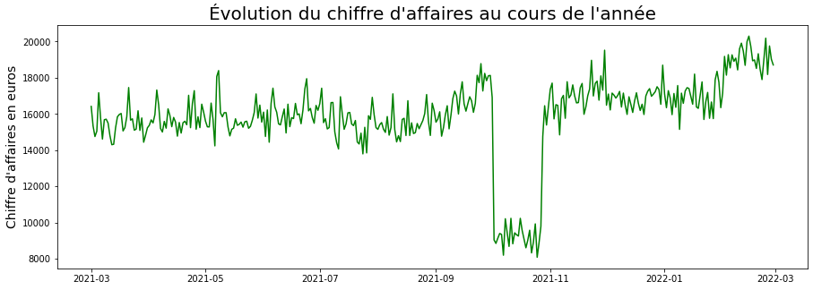

```python
import warnings ; warnings.filterwarnings('ignore') # Ne tenez pas compte de cette ligne.
import matplotlib.pyplot as plt

plt.figure(figsize=(15, 5))
ca_days = ventes.groupby("date").sum()[["price"]]

plt.plot(ca_days["price"], color="green")
plt.title("Évolution du chiffre d'affaires au cours de l'année", fontsize=20)
plt.xlabel("")
plt.ylabel("Chiffre d'affaires en euros", fontsize=14)
plt.show()
```

On peut aussi montrer l'évolution de chacune des 3 catégories de produits.

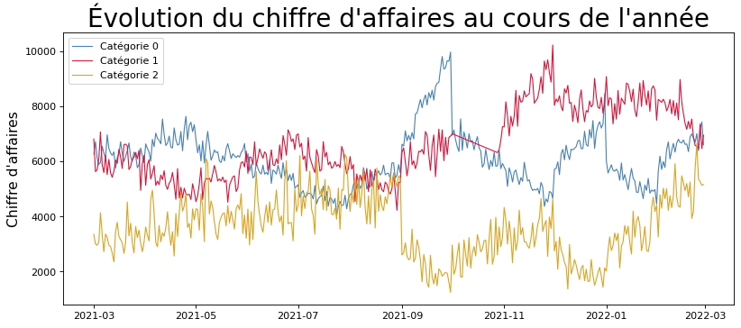

```python
plt.figure(num=None, figsize=(12, 5), dpi=80)
couleur = ["steelblue", "crimson", "goldenrod"]

for i in range(3):
    cat = ventes.loc[ventes["categ"]==i].groupby("date").sum()[["price"]]
    plt.plot(cat["price"], color=couleur[i], linewidth=1, label= "Catégorie %d" %i)

plt.title("Évolution du chiffre d'affaires au cours de l'année", fontsize=25)
plt.xlabel("")
plt.ylabel("Chiffre d'affaires", fontsize=14)
plt.legend()
plt.show()
```

*Retour au sommaire*

# GRAPHIQUES SOUS MATPLOTLIB

Pour les graphiques à venir, il vous faudra importer le module **matplotlib.pyplot**, qu'on importera ici sous l'abréviation **plt**. Voici d'ailleurs aussi un module très pratique tiré directement de **la librairie HTML** pour centrer les graphiques présentés (c'est plus joli).

```python
import matplotlib.pyplot as plt

from IPython.core.display import HTML
HTML("""<style> .output_png {display: table-cell; text-align: center; vertical-align: middle} </style>""")
```

# A. Pytplot & Généralités

## *A.1. Introduction à Matplotlib*

**Matplotlib** est une librairie qui permet de tracer des graphes (dans le sens graphiques), inspiré de Matlab au départ. Il permet de faire des graphes qui peuvent être comlètement adaptés si besoin. Sur une figure, on peut tracer plusieurs graphes.  
Il inclus 2 façons de l'utiliser :

- Avec une approche objet : plus compliquée et plus verbeuse, mais plus évoluée.
- Via des appels de fonctions, avec pyplot : plus simple. pyplot fournit ainsi des raccourcis.

Matplotlib rend ainsi possible la création de graphes à l'intérieur d'applications complexes autorisées par le langage python, et ceci sans quitter le langage python.

Notions principales pour les graphes sous matplotlib :

- Une figure qui peut être sauvée dans un fichier : **figure**.
- Un graphe (graphique) individuel appartenant à une figure qui peut en compter plusieurs : **axe**.
- Un axe de coordonnées appartenant à un objet axe : **axis**.
- Divers objets graphiques qui dérivent de la classe Artist et qui participent au graphe. Ce sont par exemple des rectangles, des lignes, du texte. Ces différents objets peuvent être totalement configurés (y compris individuellement) pour adapter le graphe aux besoins en appelant dessus des méthodes pour modifier leurs propriétés !

Afin d'afficher le graphe courant dans le bloc de code, il vous faudra préciser la mention **plt.show()**.

## *A.2. Tracé d'un graphe simple*

L'exemple de base est de tracer un graphe avec des valeurs de x et des valeurs de y en reliant les points dans l'ordre de la liste.

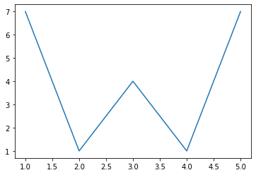

```python
plt.plot([1, 2, 3, 4, 5], [7, 1, 4, 1, 7])
plt.show()
```

Voilà les paramètres par défaut lorsque vous générez un graphe simple. Mais nous allons voir que divers paramètres sont modifiables avec des arguments à donner à pyplot.

Lorsque vous tracez une graphique, il est parfois utile d'y indiquer certaines **droites constantes** à titre de repère.

- Pour tracer une droite constante horizontale d'ordonnée a : **plt.axhline(a)**.
- Pour tracer une droite constante verticale d'abscisse a : **plt.axvline(a)**.

Vous pouvez y ajouter les mêmes paramètres que nous décrirons dans la partie suivante.

Vous pouvez aussi tracer une **fonction** en l'entrant simplement dans les paramètres.

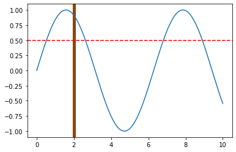

```python
plt.axhline(0.5, color="red", linestyle="--")
plt.axvline(2, color="saddlebrown", linewidth=5)

x = np.linspace(0, 10, 1000)
plt.plot(x, np.sin(x))

plt.show()
```

## *A.3. Arguments de traçage*

On peut indiquer à pyplot les arguments suivants :

- **color** → Détermine la couleur du graphe.
- **linewidth** → Pour l'épaisseur des lignes.
- **linestyle** → Le style de ligne.
- **label** → Le nom de la courbe.
- **markerfacecolor** → Détermine la couleur des bordures.
- **markersize** → Détermine l'épaisseur des bordures.
- **marker** → Détermine le symbole.

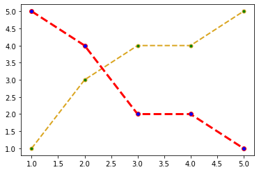

```python
plt.plot([1, 2, 3, 4, 5], [1, 3, 4, 4, 5], label = "A",
         linestyle = "dashed", color = "goldenrod", linewidth = 2,
         marker = "o", markerfacecolor = "green", markersize = 5)

plt.plot([1, 2, 3, 4, 5], [5, 4, 2, 2, 1], label = "B",
         linestyle = "dashed", color = "red", linewidth = 3,
         marker = "o", markerfacecolor = "blue", markersize = 6)

plt.show()
```

Nous reviendrons sur l'importance des labels dans la partie suivante.

## *A.4. Titres & Légendes*

Pour donner **un titre** à votre graphe et à vos axes, vous devez inscrire dans votre bloc de code :

- **plt.title( *"Titre du graphe"* )** : Pour donner le titre du graphe.
- **plt.xlabel( *"Titre de l'axe"* )** : Pour nommer l'axe des abscisses.
- **plt.ylabel( *"Titre de l'axe"* )** : Pour nommer l'axe des ordonnées.

Vous pouvez éventuellement ajouter à ces trois instructions les paramètres :

- fontsize : Pour déterminer la taille du texte.
- color : Pour déterminer la couleur du texte.
- pad : Pour déterminer l'espace sous le titre, uniquement pour plt.title().

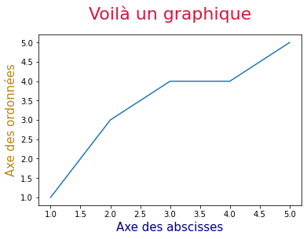

```python
plt.plot([1, 2, 3, 4, 5], [1, 3, 4, 4, 5])

plt.title("Voilà un graphique", fontsize=22, color="crimson", pad=20)
plt.xlabel("Axe des abscisses", fontsize=15, color="darkblue")
plt.ylabel("Axe des ordonnées", fontsize=15, color="darkgoldenrod")

plt.show()
```

Pour déterminer **les étiquettes des axes**, vous devez inscrire dans votre bloc de code :

- **plt.xticks( [ ] )** : Pour les étiquettes des abscisses.
- **plt.yticks( [ ] )** : Pour les étiquettes des ordonnées.
- **fontsize** : Argument que vous pouvez leur donner pour la taille des étiquettes.

Pour déterminer **les limites des axes**, vous devez inscrire dans votre bloc de code :

- **plt.xlim( a , b )** : Pour les limites des abscisses de a à b.
- **plt.ylim( c , d )** : Pour les limites des ordonnées de c à d.
- plt.xlim(0, 100) : graduation entre 0 et 100.
- plt.xlim(xmin = 0) : pour changer seulement le minimum (pareil avec pyplot.xlim(xmax = 0))
- plt.xscale('log') : pour utiliser une échelle logarithmique sur l'axe des x.

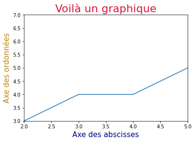

```python
plt.plot([1, 2, 3, 4, 5], [1, 3, 4, 4, 5])

plt.xlim(2, 5)
plt.ylim(3, 7)

plt.title("Voilà un graphique", fontsize=22, color="crimson")
plt.xlabel("Axe des abscisses", fontsize=15, color="darkblue")
plt.ylabel("Axe des ordonnées", fontsize=15, color="darkgoldenrod")
plt.show()
```

Il est très important, notamment lorsque vous générez plusieurs tracés sur un même graphique, de savoir à quoi correspond telle ou telle courbe. C'est pour cela qu'on précise l'argument **label** au pyplot.  
Mais pour afficher les légendes, il faut en plus préciser dans le bloc de code l'instruction **plt.legend()** qui peut, entre autres, prendre 2 arguments très importants:

- La taille des légendes avec fontsize = ....
- Sa position sur le graphe avec loc = ....

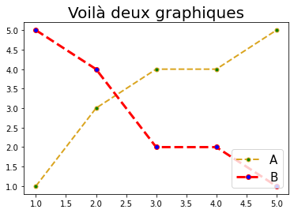

```python
plt.plot([1, 2, 3, 4, 5], [1, 3, 4, 4, 5], label = "A",
         linestyle = "dashed", color = "goldenrod", linewidth = 2,
         marker = "o", markerfacecolor = "green", markersize = 5)

plt.plot([1, 2, 3, 4, 5], [5, 4, 2, 2, 1], label = "B",
         linestyle = "dashed", color = "red", linewidth = 3,
         marker = "o", markerfacecolor = "blue", markersize = 6)

plt.title("Voilà deux graphiques", fontsize=20)
plt.legend(fontsize=15, loc="lower right")
plt.show()
```

Pour l'instruction **loc**, on a:

- En haut à gauche avec "upper left".
- En haut à droite avec "upper right".
- En bas à gauche/droite avec "lower left/right".
- Python choisit le meilleur emplacement avec "best".

## *A.5. Taille & Axes*

Si vous souhaitez modifier la taille de votre graphe dans l'affichage, vous pouvez utiliser **plt.figure(figsize=(h, v), dpi=...)** en tout début d'instruction. Le premier paramètre définit la longueur horizontale, et le deuxième la longueur verticale. L'argument **dpi**, lui, définit la résolution graphique de l'affichage.

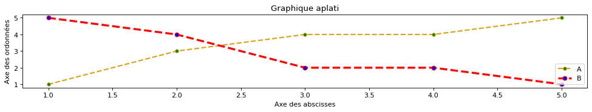

```python
plt.figure(figsize=(15, 2), dpi=80)

plt.plot([1, 2, 3, 4, 5], [1, 3, 4, 4, 5], label = "A",
         linestyle = "dashed", color = "goldenrod", linewidth = 2, marker = "o", markerfacecolor = "green", markersize = 5)

plt.plot([1, 2, 3, 4, 5], [5, 4, 2, 2, 1], label = "B",
         linestyle = "dashed", color = "red", linewidth = 3, marker = "o", markerfacecolor = "blue", markersize = 6)

plt.title("Graphique aplati"), plt.xlabel("Axe des abscisses"), plt.ylabel("Axe des ordonnées")
plt.legend(loc="lower right") ; plt.show()
```

Vous l'aurez compris, l'argument **fontsize** au sein d'un paramètre permet de définir la taille d'affichage.

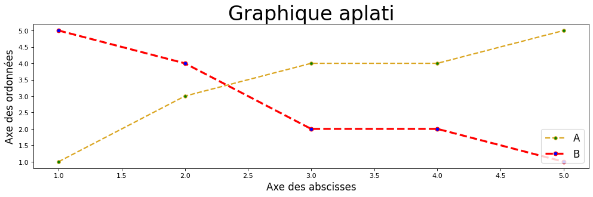

```python
plt.figure(figsize=(15, 4), dpi=80)

plt.plot([1, 2, 3, 4, 5], [1, 3, 4, 4, 5], label = "A",
         linestyle = "dashed", color = "goldenrod", linewidth = 2, marker = "o", markerfacecolor = "green", markersize = 5)

plt.plot([1, 2, 3, 4, 5], [5, 4, 2, 2, 1], label = "B",
         linestyle = "dashed", color = "red", linewidth = 3, marker = "o", markerfacecolor = "blue", markersize = 6)

plt.title("Graphique aplati", fontsize=30)
plt.xlabel("Axe des abscisses", fontsize=15), plt.ylabel("Axe des ordonnées", fontsize=15)
plt.legend(fontsize=15, loc="lower right") ; plt.show()
```

## *A.6. Couleurs sous Matplotlib*

L'argument **color** ou **colors** dans les paramètres d'un plot permet de choisir les couleurs de son graphique. Voici un tableau réunissant les couleurs "classiques" que vous pouvez sélectionner.

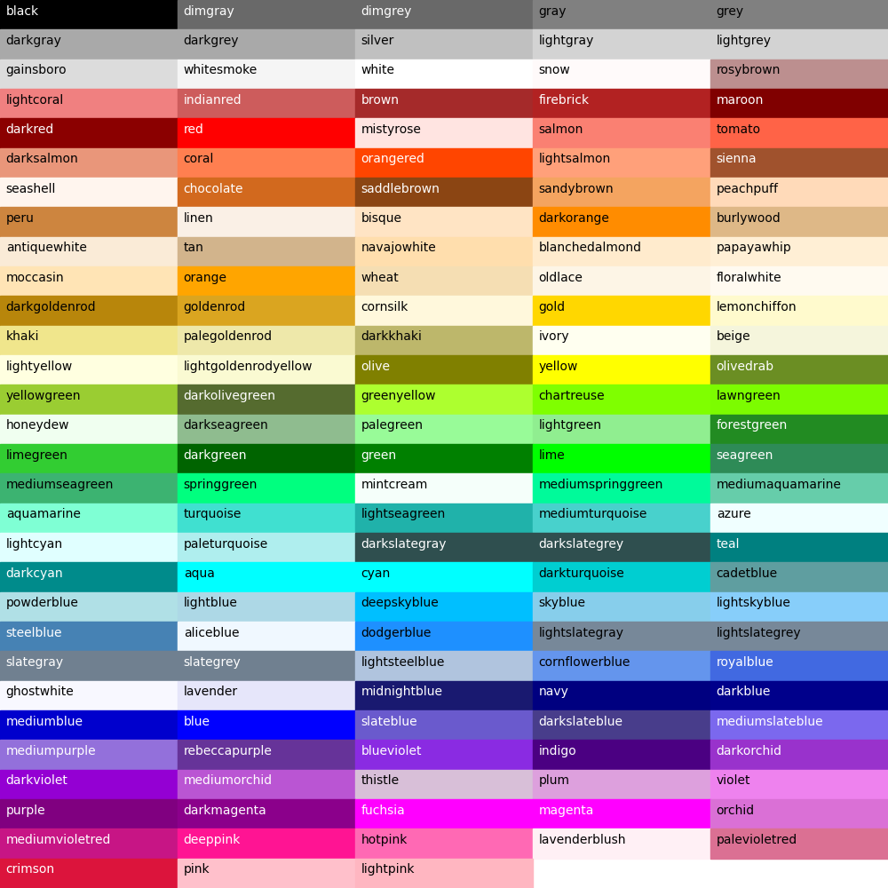

```python
from IPython.display import Image
Image(filename="data/tuto/colors.png", width=650)
```

En réalité, il existe **16 millions de couleurs** en informatique. Pour plus de choix de coloris, voici en lien [**le tableau des couleurs RGB**](https://htmlcolorcodes.com/fr/).

*Retour au sommaire*

# B. Graphiques spécifiques

## *B.1. Diagramme en bâtons*

Pour tracer un **diagramme simple** avec une seule série de valeurs, vous pouvez utiliser **plt.bar( range(5), [1, 3, 3, 5, 4] )** où:

- range(5) sont les positions de début de chaque barre sur l'axe des x.
- [1, 3, 3, 5, 4] sont les hauteurs de barres.

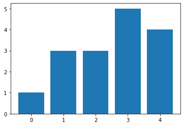

```python
plt.bar(range(5), [1, 3, 3, 5, 4])
plt.show()
```

Mais vous pouvez également ajouter des paramètres:

- width est la largeur relative de chaque barre (par défaut, 0.8, c'est à dire 20% d'espace vide entre chaque barre).
- color = "red" : la couleur des barres.
- edgecolor = "blue" : la couleur des encadrements.
- linewidth = 2 : l'épaisseur des traits.
- yerr = [0.3, 0.3, 0.2] : les valeurs des barres d'erreur.
- ecolor = "yellow" : la couleur des barres d'erreur.
- capsize = 3 : la longueur du trait des barres d'erreur.
- log = True : pour avoir les coordonnées y en log.
- orientation = "horizontal"/"vertical" : orientation horizontale ou verticale.
- linestyle = "dashed" : style des lignes ("solid", "dashed", "dashot", "dotted").

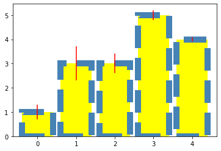

```python
plt.bar(range(5), [1, 3, 3, 5, 4], color="yellow", edgecolor="steelblue", linewidth=10,
        yerr=[0.3, 0.7, 0.4, 0.2, 0.1], ecolor="red", linestyle="dashed")

plt.show()
```

Vous pouvez aussi **exposer deux séries de valeurs** en les distinguant par **leurs positions d'abscisse**.

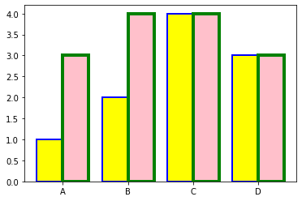

```python
y1 = [1, 2, 4, 3]
y2 = [3, 4, 4, 3]

r1 = range(len(y1))
r2 = [x + 0.4 for x in r1]

plt.bar(r1, y1, width = 0.4, color = ["yellow" for i in y1], edgecolor = ["blue" for i in y1], linewidth = 2)

plt.bar(r2, y2, width = 0.4, color = ["pink" for i in y1], edgecolor = ["green" for i in y1], linewidth = 4)

plt.xticks([r + 0.2 for r in range(len(y1))], ["A", "B", "C", "D"])
plt.show()
```

Vous pouvez aussi **différencier un deuxième axe des ordonnées** avec **plt.gca().twinx()**.

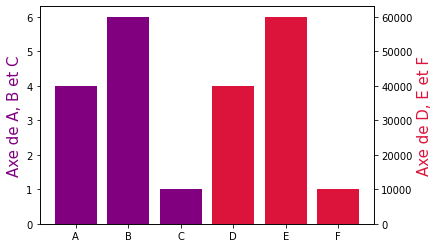

```python
plt.bar([1, 2, 3], [4, 6, 1], color="purple")
plt.ylabel("Axe de A, B et C", fontsize=15, color="purple")

plt.gca().twinx()
plt.bar([4, 5, 6], [40000, 60000, 10000], color="crimson")
plt.ylabel("Axe de D, E et F", fontsize=15, color="crimson")

plt.xticks(range(1, 7), ["A", "B", "C", "D", "E", "F"])
plt.show()
```

Vous pouvez encore **superposer deux séries** avec l'argument **bottom**.

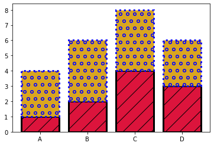

```python
y1 = [1, 2, 4, 3]
y2 = [3, 4, 4, 3]
r = range(len(y1))

plt.bar(r, y1, width = 0.8, color = ["crimson" for i in y1], edgecolor = ["black" for i in y1],
        linestyle = "solid", hatch ="/", linewidth = 3)

plt.bar(r, y2, width = 0.8, bottom = y1,
        color=["goldenrod" for i in y1], edgecolor=["blue" for i in y1], linestyle="dotted", hatch="o", linewidth=3)

plt.xticks(range(len(y1)), ["A", "B", "C", "D"])
plt.show()
```

Enfin, vous pouvez refaire tout ça **horizontalement** avec **plt.barh**, auquel cas l'argument **bottom** devient **left**.

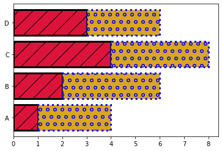

```python
y1 = [1, 2, 4, 3]
y2 = [3, 4, 4, 3]
r = range(len(y1))

plt.barh(r, y1, color = ["crimson" for i in y1], edgecolor = ["black" for i in y1],
        linestyle = "solid", hatch ="/", linewidth = 3)

plt.barh(r, y2, left = y1,
        color=["goldenrod" for i in y1], edgecolor=["blue" for i in y1], linestyle="dotted", hatch="o", linewidth=3)

plt.yticks(range(len(y1)), ["A", "B", "C", "D"])
plt.show()
```

## *B.2. Diagramme circulaire*

Pour tracer un **camembert**, vous pouvez utiliser **plt.pie()**.

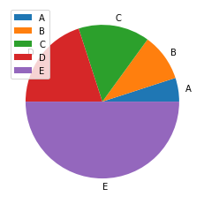

```python
plt.pie([1, 2, 3, 4, 10], labels = ["A", "B", "C", "D", "E"], normalize = True)
plt.legend()
plt.show()
```

Vous pouvez également ajouter des paramètres:

- normalize = True : fait un camembert complet en normalisant la somme des valeurs.
- explode = [0, 0.2, 0, 0, 0] : array de la même taille que le tableau de données indiquant de quelle fraction de rayon la part doit être éloignée du centre.
- colors = ['red', 'green', 'yellow'] : séquence de couleurs à utiliser pour les parts (recyclé si pas assez de couleurs).
- labeldistance = 1.3 : la distance des labels au centre (> 1 pour être à l'extérieur du cercle).
- autopct = lambda x: str(round(x, 2)) + '%' : une fonction qui prend le pourcentage de la part et renvoie ce qui doit être affiché pour ce pourcentage.
- pctdistance = 0.7 : le distance au centre à laquelle le pourcentage précédent doit être affiché (1 = sur le cercle).
- shadow = True : indique qu'il faut afficher une ombre.

Vous pouvez aussi au préalable régler la taille des indices d'affichage avec **mpl.rcParams["font.size"]**.

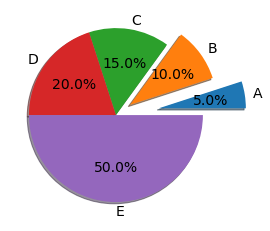

```python
import matplotlib as mpl
mpl.rcParams["font.size"] = 14

plt.pie([1, 2, 3, 4, 10], labels = ["A", "B", "C", "D", "E"], normalize = True,
        explode=[0.5, 0.2, 0, 0, 0], autopct=lambda x:str(round(x,2))+"%", shadow=True)

plt.show()
```

## *B.3. Nuage de points*

Pour créer un **nuage de points**, on peut utiliser **plt.scatter()**.

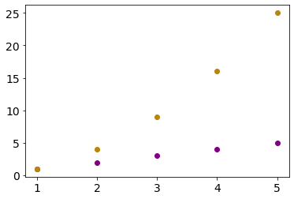

```python
x = [1, 2, 3, 4, 5]
plt.scatter(x, [1, 2, 3, 4, 5], c = "purple")
plt.scatter(x, [1, 4, 9, 16, 25], c = "darkgoldenrod")
plt.show()
```

Vous pouvez également ajouter des paramètres:

- c = 'red' ou color = 'red' : la couleur des points (défaut est 'black').
- edgecolor = 'none' : évite que le symbole soit entouré d'un trait noir.
- s = 10 : taille du symbole au carré (le multiplier par 4 si on veut agrandir la taille d'un facteur 2). Le défaut est 20.

Le paramètre **marker** peut prendre les arguments suivants.

| Symbole | Affichage | ......... | Symbole | Affichage |
| --- | --- | --- | --- | --- |
| "o" | rond | ......... | "H" | hexagone. |
| "s" | carré | ......... | "p" | pentagone |
| "+" | croix verticale | ......... | "." | point |
| "x" | croix diagonale | ......... | ">" | triangle vers la droite |
| "*" | étoile | ......... | "v" | triangle vers le bas |
| "D" | losange | ......... | "\|" | trait vertical ('_' pour horizontal) |
| "d" | losange allongé | ......... | "1" | croix à 3 branches vers le bas |

## *B.4. Histogramme*

Pour créer un **histogramme**, on peut utiliser **plt.hist()**.

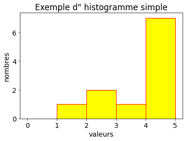

```python
plt.hist([1, 2, 2, 3, 4, 4, 4, 4, 4, 5, 5], range = (0, 5), bins = 5, color = "yellow", edgecolor = "red")
plt.xlabel("valeurs")
plt.ylabel("nombres")
plt.title("Exemple d\" histogramme simple")
plt.show()
```

Vous pouvez également ajouter des paramètres:

- plt.hist(x, bins = range(11)) : on peut donner aussi les limites des intervalles explicitement plutôt qu'un nombre d'intervalles.
- plt.hist(x, bins = [0, 5, 6, 7, 8, 9, 10]) : on peut très bien donner des bins de taille inégale.
- plt.hist(x, range = (0, 10), bins = 10) : donne le minimum et le maximum des valeurs représentées et le nombre de bins. Par défaut, range est (min(x), max(x)).
- plt.hist(x, density = True) : trace les fréquences plutôt que les nombres en ordonnée (somme vaut 1).
- plt.hist(x, weights = range(len(x))) : attribut un poids à chaque valeur.
- align = 'mid' : les barres sont centrées entre les 2 extrémités du bin (le défaut).
- align = 'left' : indique que les barres sont centrées sur l'extrémité gauche du bin ('right' pour la droite).
- orientation = 'horizontal' : histogramme horizontal.
- rwidth = 0.5 : les barres sont réduites de largeur de 50% (avec un espace entre elles).
- log = True : axe des y en log.
- color = 'yellow' : la couleur des barres.
- edgecolor = 'red' : la couleur des bordures. edgecolor = 'none' pour ne pas avoir de bordure.
- hatch = '/' : les hachures. Valeurs possibles : '/', '\', '|', '-', '+', 'x', 'o', 'O', '.', '*'
- histtype = 'step' : trace une ligne plutôt que des barres.
- plt.hist(v, cumulative = True) : distribution cumulée
- plt.hist(v, cumulative = -1) : distribution cumulée renversée.

Vous pouvez encore **superposer deux histogrammes** avec **une série de listes**.

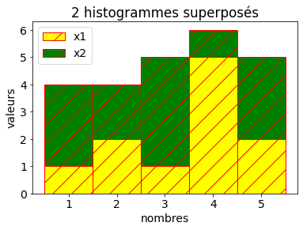

```python
x1 = [1, 2, 2, 3, 4, 4, 4, 4, 4, 5, 5]
x2 = [1, 1, 1, 2, 2, 3, 3, 3, 3, 4, 5, 5, 5]
bins = [x + 0.5 for x in range(0, 6)]

plt.hist([x1, x2], bins = bins, color = ["yellow", "green"],
            edgecolor = "red", hatch = "/", label = ["x1", "x2"],
            histtype = "barstacked")

plt.ylabel("valeurs") ; plt.xlabel("nombres")
plt.title("2 histogrammes superposés") ; plt.legend()
plt.show()
```

## *B.5. Boîte à moustaches*

Pour créer une **boîte à moustaches**, on utilise **plt.boxplot()**.

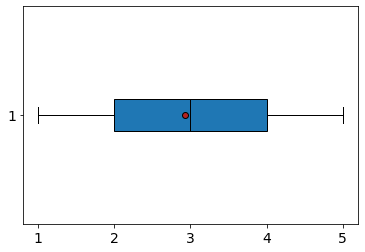

```python
# On définit ici les paramètres des boxplots :
medianprops = {"color":"black"}
meanprops = {"marker":"o", "markeredgecolor":"black", "markerfacecolor":"firebrick"}

plt.boxplot([1, 1, 1, 2, 2, 3, 3, 3, 3, 4, 5, 5, 5], showfliers=False, medianprops=medianprops, vert=False,
            patch_artist=True, showmeans=True, meanprops=meanprops)
plt.show()
```

## *B.6. Utiliser Pylab*

**Pylab** fournit une interface procédurale à la librairie graphique **matplotlib orientée objet**. Elle est basée sur un modèle très proche de Matlab™. De la sorte, la grande majorité des commandes pylab ont leur équivalent Matlab™ avec des arguments similaires. Les commandes les plus importantes sont expliquées avec des exemples en console interactive.

```python
from matplotlib.pylab import *
```

Matplotlib est fournie avec un jeu de paramètres par défaut qui permet de personnaliser toute sorte de propriétés. Vous pouvez contrôler les réglages par défaut de (presque) toutes les propriétés : taille du graphique, résolution en points par pouce (dpi), épaisseur du trait, couleurs, styles, vues, repères, grilles, textes, polices de caractères, etc. Bien que les réglages par défaut répondent à la plupart des cas courants, vous pourriez être amenés à en modifier quelques-uns pour des cas plus spécifiques.

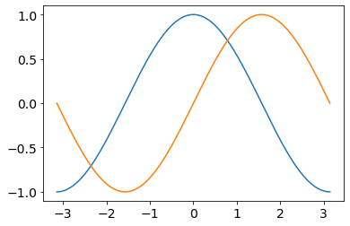

```python
from matplotlib.pylab import plot, show

X = np.linspace(-np.pi, np.pi, 256,endpoint=True)
C,S = np.cos(X), np.sin(X)

plot(X,C)
plot(X,S)
show()
```

La mise en place des paramètres d'affichage avec **pylab** fonctionnent comme avec **pyplot**.

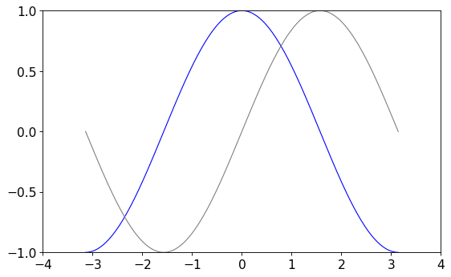

```python
figure(figsize=(8, 5), dpi=80) # On crée un graphique de 8x6 pouces avec une résolution de 80 points par pouce.
subplot(1,1,1) # On crée une nouvelle vue dans une grille de 1 ligne x 1 colonne.

X = np.linspace(-np.pi, np.pi, 256,endpoint=True)
C,S = np.cos(X), np.sin(X)

plot(X, C, color="blue", linewidth=1.0, linestyle="-") # On trace la fonction cosinus en bleu avec un trait plein
                                                       # de 1 pixel d'épaisseur.
plot(X, S, color="grey", linewidth=1.0, linestyle="-") # Idem avec la fonction sinus.

xlim(-4.0,4.0) # limites de l'axe (O,x) des abscisses.
xticks(np.linspace(-4,4,9,endpoint=True)) # Graduations de l'axe (O,x) des abscisses

ylim(-1.0,1.0) # limites de l'axe (O,y) des ordonnées.
yticks(np.linspace(-1,1,5,endpoint=True)) # Graduations de l'axe (O,y) des ordonnées.

show() # On affiche le résultat à l'écran.
```

Donner la représentation graphique au voisinage de 0 de la fonction f définie par: **f(x) = |x sin(1/x)|**.

Sous pylab la fonction donnant la valeur absolue est absolute().

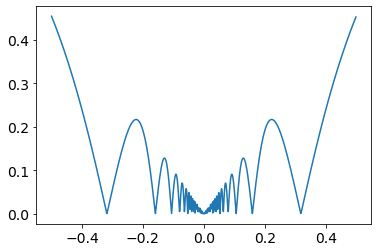

```python
from matplotlib.pylab import plot, absolute, sin, arange
X = arange(-0.5,0.5,0.001)
Y = absolute(X*sin(1/X))
plot(X,Y)
show()
```

*Retour au sommaire*

# C. Disposition de graphes multiples

## *C.1. Figures & Axes*

**Il y a 2 notions :**

- Notion de **figure** qui peut regrouper plusieurs graphes, modélisé par un **objet Figure**. Pour créer une figure, on peut alors faire par exemple **plt.figure(2)**.
- Notion de **graphe** dans cette figure, modélisé par un **objet Axes**. Pour créer un graphe, on fait par exemple **plt.subplot(212)**.

**Taille d'une figure :**

- Pour fixer la taille de la figure largeur puis hauteur (en pouces) : **figure = plt.figure(figsize = (10, 10))**.
- Pour avoir la taille de la figure (tuple renvoyé) : **figure.get_size_inches()**.

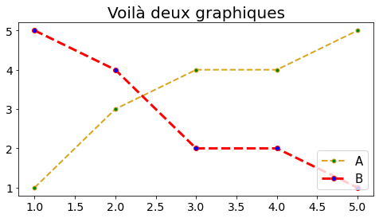

```
array([8., 4.])
```

```python
fig, ax = plt.subplots(figsize=(8, 4))

ax.plot([1, 2, 3, 4, 5], [1, 3, 4, 4, 5], label = "A", linestyle = "dashed", color = "goldenrod", linewidth = 2,
         marker = "o", markerfacecolor = "green", markersize = 5)

ax.plot([1, 2, 3, 4, 5], [5, 4, 2, 2, 1], label = "B", linestyle = "dashed", color = "red", linewidth = 3,
         marker = "o", markerfacecolor = "blue", markersize = 6)

ax.set_title("Voilà deux graphiques", fontsize=20)
plt.legend(fontsize=15, loc="lower right")
plt.show()

fig.get_size_inches()
```

## *C.2. Fixation des marges*

Pour avoir des marges minimales : **plt.tight_layout()** permet d'ajuster automatiquement les marges si certaines étiquettes sont particulièrement longues (c'est matplotlib qui calcule).  
L'instruction **plt.tight_layout(rect = [0, 0, 1, 0.9])** indique le rectangle sur lequel mettre les graphes, ce qui permet de laisser de la place pour le suptitle par exemple. Le défaut est [0, 0, 1, 1].  
Si plusieurs graphes, on peut ajuster les marges supplémentaires avec plt.tight_layout(pad=0.4, w_pad=0.5, h_pad=1.0).

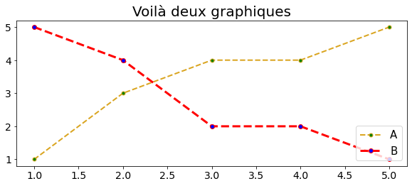

```python
plt.figure(figsize=(8, 4))

plt.plot([1, 2, 3, 4, 5], [1, 3, 4, 4, 5], label = "A", linestyle = "dashed", color = "goldenrod", linewidth = 2,
         marker = "o", markerfacecolor = "green", markersize = 5)

plt.plot([1, 2, 3, 4, 5], [5, 4, 2, 2, 1], label = "B", linestyle = "dashed", color = "red", linewidth = 3,
         marker = "o", markerfacecolor = "blue", markersize = 6)

plt.title("Voilà deux graphiques", fontsize=20)
plt.legend(fontsize=15, loc="lower right")
plt.tight_layout(rect=[0, 0, 1, 0.9], pad=0.4, w_pad=0.5, h_pad=1.0)
plt.show()
```

## *C.3. Disposition multiple*

**Traçage de graphes multiples sur la même figure :**

- **plt.figure(1)** : ouvre la figure numéro 1 (appel implicite à la figure numéro 1 si pas d'appel à figure()).
- **plt.subplot(2,1,1)** : partage la figure en 2 x 1 emplacements de graphes (2 lignes et 1 colonne) et sélectionne le 1er emplacement pour les instructions graphiques suivantes. Les numéros des graphes sont comptés par ligne.
- **plt.subplot(211)** : c'est une alternative à plt.subplot(2,1,1), dans le cas ou les dimensions et le numéro de graphe sont inférieurs à 10.
- Si on ne fait pas d'appel à subplot, par défaut, il y a un appel **plt.subplot(111)** (1 emplacement).

**Fermeture d'une figure :**

- **plt.close()** : ferme la figure courante. Nécessaire pour libérer toutes les ressources occupées, même si la figure n'est plus visible.
- **plt.close(2)** : ferme la figure 2.
- **plt.close('all')** : ferme toutes les figures.

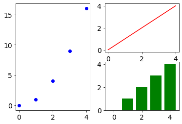

```python
plt.figure(1)

plt.subplot(1, 2, 1)
plt.scatter(range(5), [x ** 2 for x in range(5)], color = "blue")

plt.subplot(2, 2, 2)
plt.plot(range(5), color = "red")

plt.subplot(2, 2, 4)
plt.bar(range(5), range(5), color = "green")

plt.show()
```

**Subplots :**

- **myfig, (ax1, ax2) = plt.subplots(nrows = 2, ncols = 3)** : permet de définir à l'avance des graphes, pour les remplir après.
- **plt.gcf().get_axes()** : retourne la liste des graphes présents sur la figure courante.
- **squeeze = True** : si un seul graphe, un seul axis retourné, si une seule colonne ou un seule ligne, array 1d retournée, sinon array 2d. C'est le défaut. Si squeeze = False, c'est toujours une array 2d qui est retournée. on peut boucler simplement sur les axis en mettant à plat l'array des axis : myfig, axes = plt.subplots(nrows = 5, ncols = 4); axes = axes.ravel().

**Sharex :**

- sharex = False ou sharex = 'none' : les graduations de l'axe des x sont indépendantes entre les graphes. C'est le défaut.
- sharex = True ou sharex = 'all' : tous les graphes utilisent les mêmes graduations de l'axe des x.
- sharex = 'row' : tous les graphes d'une même ligne utilisent les mêmes graduations de l'axe des x.
- sharex = 'col' : tous les graphes d'une même colonne utilisent les mêmes graduations de l'axe des x.
- **sharey** : comme sharex, mais pour l'axe des y.

## *C.4. Graphiques insérés*

On peut aussi positionner un graphe "en insert" où l'on veut en donnant la position x et y du point en bas à gauche de ce graphe, avec des valeurs entre 0 et 1, et les dimensions largeur et hauteur, entre 0 et 1, et en utilisant la méthode add_axes de **Figure**.

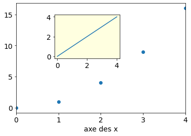

```python
figure = plt.figure()

axes = figure.add_subplot(111) # Renvoie un objet AxesSubplot, sous classe de Axes.
axes.scatter(range(5), [x ** 2 for x in range(5)])
axes.set_xlim(0, 4)
axes.set_xlabel("axe des x")

axes2 = figure.add_axes([0.3, 0.5, 0.3, 0.3]) # Renvoie un objet Axes.
axes2.patch.set_color("lightyellow")
axes2.plot(range(5), range(5))

plt.show()
```

## *C.5. Ajustements*

**Réglage des marges :**

- **pyplot.gcf().subplots_adjust(left = 0.2, bottom = 0.2, right = 0.9, top = 0.9, wspace = 0, hspace = 0)** : permet de régler toutes les marges.
- left et bottom : valeurs entre 0 et 1 qui indiquent où commencent les graphes par rapport à la figure.
- right et top : valeurs entre 0 et 1 supérieures à left et bottom respectivement qui indiquent où finissent les graphes par rapport à la figure.
- wspace et hspace : espace horizontal et vertical respectivement entre graphes, mais cette fois-ci en pouces (valeurs peuvent être supérieures à 1).
- Les valeurs par défaut sont left = 0.125, bottom = 0.1, right = 0.9, top = 0.9, wspace = 0.2 et hspace = 0.2. on peut très bien modifier seulement certaines de ces valeurs, par exemple **pyplot.gcf().subplots_adjust(hspace = 2)**

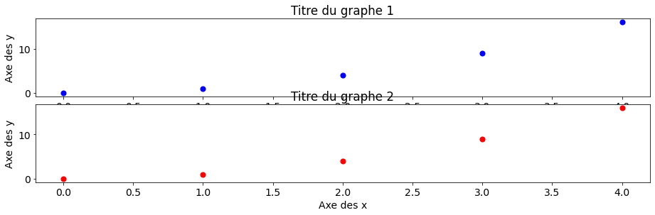

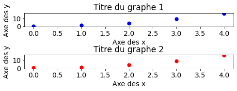

```python
figure = plt.figure(figsize = (15, 4)) # Exemple avec des petites marges.

plt.gcf().subplots_adjust(left = 0.1, bottom = 0.1,
                          right = 0.9, top = 0.9,
                          wspace = 0, hspace = 0.1)

axes = figure.add_subplot(2, 1, 1)
axes.set_xlabel("Axe des x")
axes.set_ylabel("Axe des y")
axes.set_title("Titre du graphe 1")

axes.scatter(range(5), [x ** 2 for x in range(5)], s = 50, color = "blue")
axes = figure.add_subplot(2, 1, 2)
axes.set_xlabel("Axe des x")
axes.set_ylabel("Axe des y")
axes.set_title("Titre du graphe 2")
axes.scatter(range(5), [x ** 2 for x in range(5)], s = 50, color = "red")

plt.show()


figure = plt.figure(figsize = (15, 4)) # Exemple avec des grandes marges.

plt.gcf().subplots_adjust(left = 0.3, bottom = 0.3,
                          right = 0.7, top = 0.7,
                          wspace = 0, hspace = 2)

axes = figure.add_subplot(2, 1, 1)
axes.set_xlabel("Axe des x")
axes.set_ylabel("Axe des y")
axes.set_title("Titre du graphe 1")
axes.scatter(range(5), [x ** 2 for x in range(5)], s = 50, color = "blue")

axes = figure.add_subplot(2, 1, 2)
axes.set_xlabel("Axe des x")
axes.set_ylabel("Axe des y")
axes.set_title("Titre du graphe 2")
axes.scatter(range(5), [x ** 2 for x in range(5)], s = 50, color = "red")

plt.show()
```

Pour avoir la position d'un graphe dans une figure : **bpyplot.gca().get_position().get_points()** renvoie une array du type [[x0,y0],[x1,y1]] avec (x0, y0) coordonnées du point en bas à gauche et (x1, y1) coordonnées du point en haut à droite.  
Pour créer des subplots a priori et ensuite les remplir avec des figures :

- **myfig, (ax1, ax2) = pyplot.subplots(nrows = 2, ncols = 1)** : renvoie la Figure et une array de AxesSubplot.
- On peut alors remplir ax1 et ax2 en les passant à une fonction qui prend cet argument (par exemple celles dans seaborn) après avoir rempli les axes, il faut souvent indiquer la taille de la figure : **pyplot.gcf().set_size_inches(8, 8)**.

*Retour au sommaire*